# Correlaciones entre variables del Censo de Viviendas, Hogares y Personas e ingresos promedios comunales de la CASEN 2017.

VE-CC-AJ

DataIntelligence

Martes 29-06-2021

Abstract

Calculamos correlaciones entre el ingreso promedio comunal **multiplicado por la población comunal** que llamaremos **ipcmp** extraído de la Casen 2017 y las frecuencias de categorías de respuesta para todas las variables del Censo de viviendas, hogares y personas al 2017, también extraídas a nivel comunal.

# 1 Construcción de tablas con frecuencias de respuesta por categoría desde el Censo: Viviendas

## 1.1 Pregunta **P01**: Tipo de vivienda

Ésta pregunta posee 10 categorías de respuesta:

1 Casa  
2 Departamento en edificio  
3 Vivienda tradicional indígena (ruka, pae pae u otras)  
4 Pieza en casa antigua o en conventillo  
5 Mediagua, mejora, rancho o choza  
6 Móvil (carpa, casa rodante o similar)  
7 Otro tipo de vivienda particular  
8 Vivienda colectiva  
9 Operativo personas en tránsito (no es vivienda)  
10 Operativo calle (no es vivienda)

### 1.1.1 Cálculo de frecuencias

Leemos las respuestas a la pregunta **P01** del censo de viviendas 2017 y obtenemos la tabla de frecuencias por categoría de respuesta:

```r
tabla_con_clave <- readRDS("../censo_viviendas_con_clave_17.rds")
b <- tabla_con_clave$COMUNA
c <- tabla_con_clave$P01
cross_tab =  xtabs( ~ unlist(b) + unlist(c))
tabla <- as.data.frame(cross_tab)
d <-tabla[!(tabla$Freq == 0),]
d$anio <- "2017"

d_t <- filter(d,d$unlist.c. == 1)
for(i in 2:10){
  d_i <- filter(d,d$unlist.c. == i)
  d_t = merge( x = d_t, y = d_i, by = "unlist.b.", all.x = TRUE)
}

tablamadre <- head(d_t,50)
kbl(tablamadre) %>%
  kable_styling(bootstrap_options = c("striped", "hover")) %>%
  kable_paper() %>%
  scroll_box(width = "100%", height = "300px")
```

| unlist.b. | unlist.c..x | Freq.x | anio.x | unlist.c..y | Freq.y | anio.y | unlist.c..x | Freq.x | anio.x | unlist.c..y | Freq.y | anio.y | unlist.c..x | Freq.x | anio.x | unlist.c..y | Freq.y | anio.y | unlist.c..x | Freq.x | anio.x | unlist.c..y | Freq.y | anio.y | unlist.c..x | Freq.x | anio.x | unlist.c..y | Freq.y | … |
| --- | --- | --- | --- | --- | --- | --- | --- | --- | --- | --- | --- | --- | --- | --- | --- | --- | --- | --- | --- | --- | --- | --- | --- | --- | --- | --- | --- | --- | --- | --- |
| 1101 | 1 | 38383 | 2017 | 2 | 22525 | 2017 | 3 | 20 | 2017 | 4 | 4489 | 2017 | 5 | 586 | 2017 | 6 | 55 | 2017 | 7 | 667 | 2017 | 8 | 261 | 2017 | 9 | 1 | 2017 | 10 | 1 | … |
| 1107 | 1 | 26410 | 2017 | 2 | 4142 | 2017 | 3 | 13 | 2017 | 4 | 446 | 2017 | 5 | 1766 | 2017 | 6 | 32 | 2017 | 7 | 353 | 2017 | 8 | 16 | 2017 | NA | NA | NA | 10 | 1 | … |
| 1401 | 1 | 7855 | 2017 | 2 | 4 | 2017 | 3 | 31 | 2017 | 4 | 248 | 2017 | 5 | 543 | 2017 | 6 | 10 | 2017 | 7 | 193 | 2017 | 8 | 42 | 2017 | 9 | 1 | 2017 | NA | NA | … |
| 1402 | 1 | 828 | 2017 | 2 | 10 | 2017 | 3 | 12 | 2017 | 4 | 13 | 2017 | 5 | 213 | 2017 | 6 | 1 | 2017 | 7 | 11 | 2017 | 8 | 4 | 2017 | NA | NA | NA | NA | NA | … |
| 1403 | 1 | 826 | 2017 | 2 | 2 | 2017 | 3 | 1141 | 2017 | 4 | 10 | 2017 | 5 | 32 | 2017 | 6 | 1 | 2017 | 7 | 13 | 2017 | 8 | 5 | 2017 | 9 | 1 | 2017 | NA | NA | … |
| 1404 | 1 | 2266 | 2017 | 2 | 4 | 2017 | 3 | 61 | 2017 | 4 | 50 | 2017 | 5 | 443 | 2017 | NA | NA | NA | 7 | 39 | 2017 | 8 | 8 | 2017 | NA | NA | NA | NA | NA | … |
| 1405 | 1 | 2424 | 2017 | 2 | 5 | 2017 | 3 | 11 | 2017 | 4 | 34 | 2017 | 5 | 169 | 2017 | 6 | 2 | 2017 | 7 | 58 | 2017 | 8 | 23 | 2017 | NA | NA | NA | NA | NA | … |
| 2101 | 1 | 80067 | 2017 | 2 | 27940 | 2017 | 3 | 31 | 2017 | 4 | 751 | 2017 | 5 | 2782 | 2017 | 6 | 44 | 2017 | 7 | 660 | 2017 | 8 | 176 | 2017 | 9 | 1 | 2017 | 10 | 1 | … |
| 2102 | 1 | 3236 | 2017 | 2 | 473 | 2017 | 3 | 1 | 2017 | 4 | 13 | 2017 | 5 | 198 | 2017 | 6 | 6 | 2017 | 7 | 49 | 2017 | 8 | 240 | 2017 | 9 | 1 | 2017 | NA | NA | … |
| 2103 | 1 | 466 | 2017 | NA | NA | NA | NA | NA | NA | 4 | 21 | 2017 | 5 | 36 | 2017 | 6 | 1 | 2017 | 7 | 3 | 2017 | 8 | 43 | 2017 | NA | NA | NA | NA | NA | … |
| 2104 | 1 | 4123 | 2017 | 2 | 3 | 2017 | 3 | 50 | 2017 | 4 | 20 | 2017 | 5 | 265 | 2017 | 6 | 28 | 2017 | 7 | 59 | 2017 | 8 | 45 | 2017 | 9 | 1 | 2017 | 10 | 1 | … |
| 2201 | 1 | 49994 | 2017 | 2 | 3683 | 2017 | 3 | 137 | 2017 | 4 | 1610 | 2017 | 5 | 705 | 2017 | 6 | 26 | 2017 | 7 | 808 | 2017 | 8 | 344 | 2017 | 9 | 1 | 2017 | 10 | 1 | … |
| 2202 | 1 | 173 | 2017 | NA | NA | NA | NA | NA | NA | 4 | 6 | 2017 | 5 | 234 | 2017 | 6 | 1 | 2017 | 7 | 13 | 2017 | 8 | 12 | 2017 | NA | NA | NA | NA | NA | … |
| 2203 | 1 | 3407 | 2017 | 2 | 5 | 2017 | 3 | 78 | 2017 | 4 | 229 | 2017 | 5 | 126 | 2017 | 6 | 6 | 2017 | 7 | 121 | 2017 | 8 | 172 | 2017 | 9 | 1 | 2017 | 10 | 1 | … |
| 2301 | 1 | 8580 | 2017 | 2 | 1110 | 2017 | 3 | 3 | 2017 | 4 | 48 | 2017 | 5 | 789 | 2017 | 6 | 12 | 2017 | 7 | 78 | 2017 | 8 | 50 | 2017 | 9 | 1 | 2017 | 10 | 1 | … |
| 2302 | 1 | 1798 | 2017 | 2 | 3 | 2017 | 3 | 1 | 2017 | 4 | 25 | 2017 | 5 | 7 | 2017 | 6 | 1 | 2017 | 7 | 30 | 2017 | 8 | 94 | 2017 | NA | NA | NA | NA | NA | … |
| 3101 | 1 | 46557 | 2017 | 2 | 6812 | 2017 | 3 | 9 | 2017 | 4 | 351 | 2017 | 5 | 1481 | 2017 | 6 | 38 | 2017 | 7 | 205 | 2017 | 8 | 112 | 2017 | NA | NA | NA | 10 | 1 | … |
| 3102 | 1 | 12730 | 2017 | 2 | 71 | 2017 | 3 | 16 | 2017 | 4 | 95 | 2017 | 5 | 2483 | 2017 | 6 | 68 | 2017 | 7 | 149 | 2017 | 8 | 39 | 2017 | NA | NA | NA | 10 | 1 | … |
| 3103 | 1 | 4360 | 2017 | 2 | 4 | 2017 | 3 | 4 | 2017 | 4 | 49 | 2017 | 5 | 263 | 2017 | 6 | 2 | 2017 | 7 | 23 | 2017 | 8 | 40 | 2017 | NA | NA | NA | 10 | 1 | … |
| 3201 | 1 | 5824 | 2017 | 2 | 74 | 2017 | NA | NA | NA | 4 | 10 | 2017 | 5 | 180 | 2017 | 6 | 6 | 2017 | 7 | 28 | 2017 | 8 | 31 | 2017 | NA | NA | NA | NA | NA | … |
| 3202 | 1 | 6192 | 2017 | 2 | 520 | 2017 | NA | NA | NA | 4 | 35 | 2017 | 5 | 30 | 2017 | 6 | 1 | 2017 | 7 | 34 | 2017 | 8 | 102 | 2017 | NA | NA | NA | NA | NA | … |
| 3301 | 1 | 18055 | 2017 | 2 | 514 | 2017 | 3 | 12 | 2017 | 4 | 84 | 2017 | 5 | 532 | 2017 | 6 | 20 | 2017 | 7 | 122 | 2017 | 8 | 63 | 2017 | 9 | 1 | 2017 | 10 | 1 | … |
| 3302 | 1 | 2535 | 2017 | 2 | 4 | 2017 | 3 | 22 | 2017 | 4 | 22 | 2017 | 5 | 271 | 2017 | 6 | 3 | 2017 | 7 | 46 | 2017 | 8 | 24 | 2017 | NA | NA | NA | NA | NA | … |
| 3303 | 1 | 3044 | 2017 | NA | NA | NA | 3 | 1 | 2017 | 4 | 19 | 2017 | 5 | 410 | 2017 | 6 | 3 | 2017 | 7 | 21 | 2017 | 8 | 13 | 2017 | NA | NA | NA | NA | NA | … |
| 3304 | 1 | 5411 | 2017 | 2 | 187 | 2017 | 3 | 6 | 2017 | 4 | 22 | 2017 | 5 | 530 | 2017 | 6 | 9 | 2017 | 7 | 36 | 2017 | 8 | 25 | 2017 | 9 | 1 | 2017 | 10 | 1 | … |
| 4101 | 1 | 68106 | 2017 | 2 | 17825 | 2017 | 3 | 8 | 2017 | 4 | 190 | 2017 | 5 | 707 | 2017 | 6 | 40 | 2017 | 7 | 391 | 2017 | 8 | 197 | 2017 | NA | NA | NA | 10 | 1 | … |
| 4102 | 1 | 77648 | 2017 | 2 | 10320 | 2017 | 3 | 12 | 2017 | 4 | 310 | 2017 | 5 | 640 | 2017 | 6 | 30 | 2017 | 7 | 379 | 2017 | 8 | 160 | 2017 | 9 | 1 | 2017 | 10 | 1 | … |
| 4103 | 1 | 4310 | 2017 | 2 | 24 | 2017 | 3 | 1 | 2017 | 4 | 25 | 2017 | 5 | 86 | 2017 | 6 | 2 | 2017 | 7 | 43 | 2017 | 8 | 15 | 2017 | NA | NA | NA | NA | NA | … |
| 4104 | 1 | 2430 | 2017 | NA | NA | NA | 3 | 1 | 2017 | 4 | 14 | 2017 | 5 | 162 | 2017 | 6 | 2 | 2017 | 7 | 34 | 2017 | 8 | 17 | 2017 | NA | NA | NA | NA | NA | … |
| 4105 | 1 | 2258 | 2017 | NA | NA | NA | 3 | 2 | 2017 | 4 | 16 | 2017 | 5 | 48 | 2017 | 6 | 5 | 2017 | 7 | 19 | 2017 | 8 | 25 | 2017 | NA | NA | NA | NA | NA | … |
| 4106 | 1 | 10347 | 2017 | 2 | 60 | 2017 | 3 | 7 | 2017 | 4 | 29 | 2017 | 5 | 237 | 2017 | 6 | 14 | 2017 | 7 | 39 | 2017 | 8 | 46 | 2017 | NA | NA | NA | NA | NA | … |
| 4201 | 1 | 11612 | 2017 | 2 | 212 | 2017 | 3 | 2 | 2017 | 4 | 53 | 2017 | 5 | 336 | 2017 | 6 | 13 | 2017 | 7 | 57 | 2017 | 8 | 35 | 2017 | NA | NA | NA | NA | NA | … |
| 4202 | 1 | 4848 | 2017 | NA | NA | NA | 3 | 5 | 2017 | 4 | 20 | 2017 | 5 | 356 | 2017 | 6 | 4 | 2017 | 7 | 37 | 2017 | 8 | 8 | 2017 | NA | NA | NA | NA | NA | … |
| 4203 | 1 | 12935 | 2017 | 2 | 10 | 2017 | 3 | 2 | 2017 | 4 | 25 | 2017 | 5 | 208 | 2017 | 6 | 4 | 2017 | 7 | 53 | 2017 | 8 | 51 | 2017 | NA | NA | NA | 10 | 1 | … |
| 4204 | 1 | 10069 | 2017 | 2 | 132 | 2017 | 3 | 1 | 2017 | 4 | 38 | 2017 | 5 | 297 | 2017 | 6 | 21 | 2017 | 7 | 54 | 2017 | 8 | 85 | 2017 | NA | NA | NA | 10 | 1 | … |
| 4301 | 1 | 38937 | 2017 | 2 | 1578 | 2017 | 3 | 7 | 2017 | 4 | 203 | 2017 | 5 | 1097 | 2017 | 6 | 25 | 2017 | 7 | 192 | 2017 | 8 | 56 | 2017 | 9 | 1 | 2017 | 10 | 1 | … |
| 4302 | 1 | 6597 | 2017 | 2 | 4 | 2017 | 3 | 7 | 2017 | 4 | 25 | 2017 | 5 | 308 | 2017 | 6 | 6 | 2017 | 7 | 33 | 2017 | 8 | 19 | 2017 | NA | NA | NA | NA | NA | … |
| 4303 | 1 | 12084 | 2017 | NA | NA | NA | 3 | 4 | 2017 | 4 | 80 | 2017 | 5 | 810 | 2017 | 6 | 6 | 2017 | 7 | 59 | 2017 | 8 | 31 | 2017 | NA | NA | NA | NA | NA | … |
| 4304 | 1 | 4521 | 2017 | 2 | 2 | 2017 | 3 | 3 | 2017 | 4 | 13 | 2017 | 5 | 233 | 2017 | 6 | 10 | 2017 | 7 | 24 | 2017 | 8 | 6 | 2017 | NA | NA | NA | 10 | 1 | … |
| 4305 | 1 | 2529 | 2017 | 2 | 1 | 2017 | 3 | 3 | 2017 | 4 | 13 | 2017 | 5 | 184 | 2017 | 6 | 6 | 2017 | 7 | 15 | 2017 | 8 | 13 | 2017 | NA | NA | NA | NA | NA | … |
| 5101 | 1 | 83616 | 2017 | 2 | 30690 | 2017 | 3 | 18 | 2017 | 4 | 716 | 2017 | 5 | 1257 | 2017 | 6 | 30 | 2017 | 7 | 508 | 2017 | 8 | 361 | 2017 | 9 | 1 | 2017 | 10 | 1 | … |
| 5102 | 1 | 10211 | 2017 | 2 | 1151 | 2017 | 3 | 2 | 2017 | 4 | 42 | 2017 | 5 | 106 | 2017 | 6 | 12 | 2017 | 7 | 64 | 2017 | 8 | 18 | 2017 | NA | NA | NA | 10 | 1 | … |
| 5103 | 1 | 11433 | 2017 | 2 | 8548 | 2017 | 3 | 4 | 2017 | 4 | 46 | 2017 | 5 | 109 | 2017 | 6 | 2 | 2017 | 7 | 124 | 2017 | 8 | 24 | 2017 | NA | NA | NA | NA | NA | … |
| 5104 | 1 | 425 | 2017 | NA | NA | NA | NA | NA | NA | 4 | 3 | 2017 | 5 | 8 | 2017 | NA | NA | NA | 7 | 2 | 2017 | 8 | 7 | 2017 | 9 | 1 | 2017 | NA | NA | … |
| 5105 | 1 | 15270 | 2017 | 2 | 1765 | 2017 | NA | NA | NA | 4 | 18 | 2017 | 5 | 222 | 2017 | 6 | 6 | 2017 | 7 | 155 | 2017 | 8 | 15 | 2017 | NA | NA | NA | 10 | 1 | … |
| 5107 | 1 | 15582 | 2017 | 2 | 1434 | 2017 | 3 | 3 | 2017 | 4 | 47 | 2017 | 5 | 217 | 2017 | 6 | 14 | 2017 | 7 | 120 | 2017 | 8 | 25 | 2017 | 9 | 1 | 2017 | 10 | 1 | … |
| 5109 | 1 | 77662 | 2017 | 2 | 67357 | 2017 | 3 | 18 | 2017 | 4 | 327 | 2017 | 5 | 1024 | 2017 | 6 | 5 | 2017 | 7 | 451 | 2017 | 8 | 273 | 2017 | 9 | 1 | 2017 | 10 | 1 | … |
| 5201 | 1 | 2782 | 2017 | 2 | 1 | 2017 | 3 | 108 | 2017 | 4 | 19 | 2017 | 5 | 37 | 2017 | 6 | 7 | 2017 | 7 | 68 | 2017 | 8 | 114 | 2017 | NA | NA | NA | NA | NA | … |
| 5301 | 1 | 19535 | 2017 | 2 | 3765 | 2017 | 3 | 1 | 2017 | 4 | 90 | 2017 | 5 | 105 | 2017 | 6 | 15 | 2017 | 7 | 70 | 2017 | 8 | 80 | 2017 | 9 | 1 | 2017 | 10 | 1 | … |
| 5302 | 1 | 5313 | 2017 | NA | NA | NA | NA | NA | NA | 4 | 20 | 2017 | 5 | 129 | 2017 | 6 | 1 | 2017 | 7 | 21 | 2017 | 8 | 4 | 2017 | NA | NA | NA | NA | NA | … |

### 1.1.2 Construcción de un código comunal ad-hoc

Agregamos un cero a los códigos comunales de 4 dígitos, que queda en la columna llamada **código**:

```r
codigos <- d_t$unlist.b.
rango <- seq(1:nrow(d_t))
cadena <- paste("0",codigos[rango], sep = "")
cadena <- substr(cadena,(nchar(cadena)[rango])-(4),6)
codigos <- as.data.frame(codigos)
cadena <- as.data.frame(cadena)
comuna_corr <- cbind(d_t,cadena)
comuna_corr <- comuna_corr[,-c(1),drop=FALSE]
names(comuna_corr)[31] <- "código"

tablamadre <- head(comuna_corr,50)
kbl(tablamadre) %>%
  kable_styling(bootstrap_options = c("striped", "hover")) %>%
  kable_paper() %>%
  scroll_box(width = "100%", height = "300px")
```

| unlist.c..x | Freq.x | anio.x | unlist.c..y | Freq.y | anio.y | unlist.c..x.1 | Freq.x.1 | anio.x.1 | unlist.c..y.1 | Freq.y.1 | anio.y.1 | unlist.c..x.2 | Freq.x.2 | anio.x.2 | unlist.c..y.2 | Freq.y.2 | anio.y.2 | unlist.c..x.3 | Freq.x.3 | anio.x.3 | unlist.c..y.3 | Freq.y.3 | anio.y.3 | unlist.c..x.4 | Freq.x.4 | anio.x.4 | unlist.c..y.4 | Freq.y.4 | anio.y.4 | … |
| --- | --- | --- | --- | --- | --- | --- | --- | --- | --- | --- | --- | --- | --- | --- | --- | --- | --- | --- | --- | --- | --- | --- | --- | --- | --- | --- | --- | --- | --- | --- |
| 1 | 38383 | 2017 | 2 | 22525 | 2017 | 3 | 20 | 2017 | 4 | 4489 | 2017 | 5 | 586 | 2017 | 6 | 55 | 2017 | 7 | 667 | 2017 | 8 | 261 | 2017 | 9 | 1 | 2017 | 10 | 1 | 2017 | … |
| 1 | 26410 | 2017 | 2 | 4142 | 2017 | 3 | 13 | 2017 | 4 | 446 | 2017 | 5 | 1766 | 2017 | 6 | 32 | 2017 | 7 | 353 | 2017 | 8 | 16 | 2017 | NA | NA | NA | 10 | 1 | 2017 | … |
| 1 | 7855 | 2017 | 2 | 4 | 2017 | 3 | 31 | 2017 | 4 | 248 | 2017 | 5 | 543 | 2017 | 6 | 10 | 2017 | 7 | 193 | 2017 | 8 | 42 | 2017 | 9 | 1 | 2017 | NA | NA | NA | … |
| 1 | 828 | 2017 | 2 | 10 | 2017 | 3 | 12 | 2017 | 4 | 13 | 2017 | 5 | 213 | 2017 | 6 | 1 | 2017 | 7 | 11 | 2017 | 8 | 4 | 2017 | NA | NA | NA | NA | NA | NA | … |
| 1 | 826 | 2017 | 2 | 2 | 2017 | 3 | 1141 | 2017 | 4 | 10 | 2017 | 5 | 32 | 2017 | 6 | 1 | 2017 | 7 | 13 | 2017 | 8 | 5 | 2017 | 9 | 1 | 2017 | NA | NA | NA | … |
| 1 | 2266 | 2017 | 2 | 4 | 2017 | 3 | 61 | 2017 | 4 | 50 | 2017 | 5 | 443 | 2017 | NA | NA | NA | 7 | 39 | 2017 | 8 | 8 | 2017 | NA | NA | NA | NA | NA | NA | … |
| 1 | 2424 | 2017 | 2 | 5 | 2017 | 3 | 11 | 2017 | 4 | 34 | 2017 | 5 | 169 | 2017 | 6 | 2 | 2017 | 7 | 58 | 2017 | 8 | 23 | 2017 | NA | NA | NA | NA | NA | NA | … |
| 1 | 80067 | 2017 | 2 | 27940 | 2017 | 3 | 31 | 2017 | 4 | 751 | 2017 | 5 | 2782 | 2017 | 6 | 44 | 2017 | 7 | 660 | 2017 | 8 | 176 | 2017 | 9 | 1 | 2017 | 10 | 1 | 2017 | … |
| 1 | 3236 | 2017 | 2 | 473 | 2017 | 3 | 1 | 2017 | 4 | 13 | 2017 | 5 | 198 | 2017 | 6 | 6 | 2017 | 7 | 49 | 2017 | 8 | 240 | 2017 | 9 | 1 | 2017 | NA | NA | NA | … |
| 1 | 466 | 2017 | NA | NA | NA | NA | NA | NA | 4 | 21 | 2017 | 5 | 36 | 2017 | 6 | 1 | 2017 | 7 | 3 | 2017 | 8 | 43 | 2017 | NA | NA | NA | NA | NA | NA | … |
| 1 | 4123 | 2017 | 2 | 3 | 2017 | 3 | 50 | 2017 | 4 | 20 | 2017 | 5 | 265 | 2017 | 6 | 28 | 2017 | 7 | 59 | 2017 | 8 | 45 | 2017 | 9 | 1 | 2017 | 10 | 1 | 2017 | … |
| 1 | 49994 | 2017 | 2 | 3683 | 2017 | 3 | 137 | 2017 | 4 | 1610 | 2017 | 5 | 705 | 2017 | 6 | 26 | 2017 | 7 | 808 | 2017 | 8 | 344 | 2017 | 9 | 1 | 2017 | 10 | 1 | 2017 | … |
| 1 | 173 | 2017 | NA | NA | NA | NA | NA | NA | 4 | 6 | 2017 | 5 | 234 | 2017 | 6 | 1 | 2017 | 7 | 13 | 2017 | 8 | 12 | 2017 | NA | NA | NA | NA | NA | NA | … |
| 1 | 3407 | 2017 | 2 | 5 | 2017 | 3 | 78 | 2017 | 4 | 229 | 2017 | 5 | 126 | 2017 | 6 | 6 | 2017 | 7 | 121 | 2017 | 8 | 172 | 2017 | 9 | 1 | 2017 | 10 | 1 | 2017 | … |
| 1 | 8580 | 2017 | 2 | 1110 | 2017 | 3 | 3 | 2017 | 4 | 48 | 2017 | 5 | 789 | 2017 | 6 | 12 | 2017 | 7 | 78 | 2017 | 8 | 50 | 2017 | 9 | 1 | 2017 | 10 | 1 | 2017 | … |
| 1 | 1798 | 2017 | 2 | 3 | 2017 | 3 | 1 | 2017 | 4 | 25 | 2017 | 5 | 7 | 2017 | 6 | 1 | 2017 | 7 | 30 | 2017 | 8 | 94 | 2017 | NA | NA | NA | NA | NA | NA | … |
| 1 | 46557 | 2017 | 2 | 6812 | 2017 | 3 | 9 | 2017 | 4 | 351 | 2017 | 5 | 1481 | 2017 | 6 | 38 | 2017 | 7 | 205 | 2017 | 8 | 112 | 2017 | NA | NA | NA | 10 | 1 | 2017 | … |
| 1 | 12730 | 2017 | 2 | 71 | 2017 | 3 | 16 | 2017 | 4 | 95 | 2017 | 5 | 2483 | 2017 | 6 | 68 | 2017 | 7 | 149 | 2017 | 8 | 39 | 2017 | NA | NA | NA | 10 | 1 | 2017 | … |
| 1 | 4360 | 2017 | 2 | 4 | 2017 | 3 | 4 | 2017 | 4 | 49 | 2017 | 5 | 263 | 2017 | 6 | 2 | 2017 | 7 | 23 | 2017 | 8 | 40 | 2017 | NA | NA | NA | 10 | 1 | 2017 | … |
| 1 | 5824 | 2017 | 2 | 74 | 2017 | NA | NA | NA | 4 | 10 | 2017 | 5 | 180 | 2017 | 6 | 6 | 2017 | 7 | 28 | 2017 | 8 | 31 | 2017 | NA | NA | NA | NA | NA | NA | … |
| 1 | 6192 | 2017 | 2 | 520 | 2017 | NA | NA | NA | 4 | 35 | 2017 | 5 | 30 | 2017 | 6 | 1 | 2017 | 7 | 34 | 2017 | 8 | 102 | 2017 | NA | NA | NA | NA | NA | NA | … |
| 1 | 18055 | 2017 | 2 | 514 | 2017 | 3 | 12 | 2017 | 4 | 84 | 2017 | 5 | 532 | 2017 | 6 | 20 | 2017 | 7 | 122 | 2017 | 8 | 63 | 2017 | 9 | 1 | 2017 | 10 | 1 | 2017 | … |
| 1 | 2535 | 2017 | 2 | 4 | 2017 | 3 | 22 | 2017 | 4 | 22 | 2017 | 5 | 271 | 2017 | 6 | 3 | 2017 | 7 | 46 | 2017 | 8 | 24 | 2017 | NA | NA | NA | NA | NA | NA | … |
| 1 | 3044 | 2017 | NA | NA | NA | 3 | 1 | 2017 | 4 | 19 | 2017 | 5 | 410 | 2017 | 6 | 3 | 2017 | 7 | 21 | 2017 | 8 | 13 | 2017 | NA | NA | NA | NA | NA | NA | … |
| 1 | 5411 | 2017 | 2 | 187 | 2017 | 3 | 6 | 2017 | 4 | 22 | 2017 | 5 | 530 | 2017 | 6 | 9 | 2017 | 7 | 36 | 2017 | 8 | 25 | 2017 | 9 | 1 | 2017 | 10 | 1 | 2017 | … |
| 1 | 68106 | 2017 | 2 | 17825 | 2017 | 3 | 8 | 2017 | 4 | 190 | 2017 | 5 | 707 | 2017 | 6 | 40 | 2017 | 7 | 391 | 2017 | 8 | 197 | 2017 | NA | NA | NA | 10 | 1 | 2017 | … |
| 1 | 77648 | 2017 | 2 | 10320 | 2017 | 3 | 12 | 2017 | 4 | 310 | 2017 | 5 | 640 | 2017 | 6 | 30 | 2017 | 7 | 379 | 2017 | 8 | 160 | 2017 | 9 | 1 | 2017 | 10 | 1 | 2017 | … |
| 1 | 4310 | 2017 | 2 | 24 | 2017 | 3 | 1 | 2017 | 4 | 25 | 2017 | 5 | 86 | 2017 | 6 | 2 | 2017 | 7 | 43 | 2017 | 8 | 15 | 2017 | NA | NA | NA | NA | NA | NA | … |
| 1 | 2430 | 2017 | NA | NA | NA | 3 | 1 | 2017 | 4 | 14 | 2017 | 5 | 162 | 2017 | 6 | 2 | 2017 | 7 | 34 | 2017 | 8 | 17 | 2017 | NA | NA | NA | NA | NA | NA | … |
| 1 | 2258 | 2017 | NA | NA | NA | 3 | 2 | 2017 | 4 | 16 | 2017 | 5 | 48 | 2017 | 6 | 5 | 2017 | 7 | 19 | 2017 | 8 | 25 | 2017 | NA | NA | NA | NA | NA | NA | … |
| 1 | 10347 | 2017 | 2 | 60 | 2017 | 3 | 7 | 2017 | 4 | 29 | 2017 | 5 | 237 | 2017 | 6 | 14 | 2017 | 7 | 39 | 2017 | 8 | 46 | 2017 | NA | NA | NA | NA | NA | NA | … |
| 1 | 11612 | 2017 | 2 | 212 | 2017 | 3 | 2 | 2017 | 4 | 53 | 2017 | 5 | 336 | 2017 | 6 | 13 | 2017 | 7 | 57 | 2017 | 8 | 35 | 2017 | NA | NA | NA | NA | NA | NA | … |
| 1 | 4848 | 2017 | NA | NA | NA | 3 | 5 | 2017 | 4 | 20 | 2017 | 5 | 356 | 2017 | 6 | 4 | 2017 | 7 | 37 | 2017 | 8 | 8 | 2017 | NA | NA | NA | NA | NA | NA | … |
| 1 | 12935 | 2017 | 2 | 10 | 2017 | 3 | 2 | 2017 | 4 | 25 | 2017 | 5 | 208 | 2017 | 6 | 4 | 2017 | 7 | 53 | 2017 | 8 | 51 | 2017 | NA | NA | NA | 10 | 1 | 2017 | … |
| 1 | 10069 | 2017 | 2 | 132 | 2017 | 3 | 1 | 2017 | 4 | 38 | 2017 | 5 | 297 | 2017 | 6 | 21 | 2017 | 7 | 54 | 2017 | 8 | 85 | 2017 | NA | NA | NA | 10 | 1 | 2017 | … |
| 1 | 38937 | 2017 | 2 | 1578 | 2017 | 3 | 7 | 2017 | 4 | 203 | 2017 | 5 | 1097 | 2017 | 6 | 25 | 2017 | 7 | 192 | 2017 | 8 | 56 | 2017 | 9 | 1 | 2017 | 10 | 1 | 2017 | … |
| 1 | 6597 | 2017 | 2 | 4 | 2017 | 3 | 7 | 2017 | 4 | 25 | 2017 | 5 | 308 | 2017 | 6 | 6 | 2017 | 7 | 33 | 2017 | 8 | 19 | 2017 | NA | NA | NA | NA | NA | NA | … |
| 1 | 12084 | 2017 | NA | NA | NA | 3 | 4 | 2017 | 4 | 80 | 2017 | 5 | 810 | 2017 | 6 | 6 | 2017 | 7 | 59 | 2017 | 8 | 31 | 2017 | NA | NA | NA | NA | NA | NA | … |
| 1 | 4521 | 2017 | 2 | 2 | 2017 | 3 | 3 | 2017 | 4 | 13 | 2017 | 5 | 233 | 2017 | 6 | 10 | 2017 | 7 | 24 | 2017 | 8 | 6 | 2017 | NA | NA | NA | 10 | 1 | 2017 | … |
| 1 | 2529 | 2017 | 2 | 1 | 2017 | 3 | 3 | 2017 | 4 | 13 | 2017 | 5 | 184 | 2017 | 6 | 6 | 2017 | 7 | 15 | 2017 | 8 | 13 | 2017 | NA | NA | NA | NA | NA | NA | … |
| 1 | 83616 | 2017 | 2 | 30690 | 2017 | 3 | 18 | 2017 | 4 | 716 | 2017 | 5 | 1257 | 2017 | 6 | 30 | 2017 | 7 | 508 | 2017 | 8 | 361 | 2017 | 9 | 1 | 2017 | 10 | 1 | 2017 | … |
| 1 | 10211 | 2017 | 2 | 1151 | 2017 | 3 | 2 | 2017 | 4 | 42 | 2017 | 5 | 106 | 2017 | 6 | 12 | 2017 | 7 | 64 | 2017 | 8 | 18 | 2017 | NA | NA | NA | 10 | 1 | 2017 | … |
| 1 | 11433 | 2017 | 2 | 8548 | 2017 | 3 | 4 | 2017 | 4 | 46 | 2017 | 5 | 109 | 2017 | 6 | 2 | 2017 | 7 | 124 | 2017 | 8 | 24 | 2017 | NA | NA | NA | NA | NA | NA | … |
| 1 | 425 | 2017 | NA | NA | NA | NA | NA | NA | 4 | 3 | 2017 | 5 | 8 | 2017 | NA | NA | NA | 7 | 2 | 2017 | 8 | 7 | 2017 | 9 | 1 | 2017 | NA | NA | NA | … |
| 1 | 15270 | 2017 | 2 | 1765 | 2017 | NA | NA | NA | 4 | 18 | 2017 | 5 | 222 | 2017 | 6 | 6 | 2017 | 7 | 155 | 2017 | 8 | 15 | 2017 | NA | NA | NA | 10 | 1 | 2017 | … |
| 1 | 15582 | 2017 | 2 | 1434 | 2017 | 3 | 3 | 2017 | 4 | 47 | 2017 | 5 | 217 | 2017 | 6 | 14 | 2017 | 7 | 120 | 2017 | 8 | 25 | 2017 | 9 | 1 | 2017 | 10 | 1 | 2017 | … |
| 1 | 77662 | 2017 | 2 | 67357 | 2017 | 3 | 18 | 2017 | 4 | 327 | 2017 | 5 | 1024 | 2017 | 6 | 5 | 2017 | 7 | 451 | 2017 | 8 | 273 | 2017 | 9 | 1 | 2017 | 10 | 1 | 2017 | … |
| 1 | 2782 | 2017 | 2 | 1 | 2017 | 3 | 108 | 2017 | 4 | 19 | 2017 | 5 | 37 | 2017 | 6 | 7 | 2017 | 7 | 68 | 2017 | 8 | 114 | 2017 | NA | NA | NA | NA | NA | NA | … |
| 1 | 19535 | 2017 | 2 | 3765 | 2017 | 3 | 1 | 2017 | 4 | 90 | 2017 | 5 | 105 | 2017 | 6 | 15 | 2017 | 7 | 70 | 2017 | 8 | 80 | 2017 | 9 | 1 | 2017 | 10 | 1 | 2017 | … |
| 1 | 5313 | 2017 | NA | NA | NA | NA | NA | NA | 4 | 20 | 2017 | 5 | 129 | 2017 | 6 | 1 | 2017 | 7 | 21 | 2017 | 8 | 4 | 2017 | NA | NA | NA | NA | NA | NA | … |

### 1.1.3 Unión con los ingresos comunales expandidos

Hacemos la unión con los ingresos promedio comunales expandidos:

```r
ingresos_expandidos_2017 <- readRDS("../ingresos_expandidos_17.rds")

df_2017_2 = merge( x = comuna_corr, y = ingresos_expandidos_2017, by = "código", all.x = TRUE)

tablamadre <- head(df_2017_2,50)
kbl(tablamadre) %>%
  kable_styling(bootstrap_options = c("striped", "hover")) %>%
  kable_paper() %>%
  scroll_box(width = "100%", height = "300px")
```

| código | unlist.c..x | Freq.x | anio.x | unlist.c..y | Freq.y | anio.y | unlist.c..x.1 | Freq.x.1 | anio.x.1 | unlist.c..y.1 | Freq.y.1 | anio.y.1 | unlist.c..x.2 | Freq.x.2 | anio.x.2 | unlist.c..y.2 | Freq.y.2 | anio.y.2 | unlist.c..x.3 | Freq.x.3 | anio.x.3 | unlist.c..y.3 | Freq.y.3 | anio.y.3 | unlist.c..x.4 | Freq.x.4 | anio.x.4 | unlist.c..y.4 | Freq.y.4 | … |
| --- | --- | --- | --- | --- | --- | --- | --- | --- | --- | --- | --- | --- | --- | --- | --- | --- | --- | --- | --- | --- | --- | --- | --- | --- | --- | --- | --- | --- | --- | --- |
| 01101 | 1 | 38383 | 2017 | 2 | 22525 | 2017 | 3 | 20 | 2017 | 4 | 4489 | 2017 | 5 | 586 | 2017 | 6 | 55 | 2017 | 7 | 667 | 2017 | 8 | 261 | 2017 | 9 | 1 | 2017 | 10 | 1 | … |
| 01107 | 1 | 26410 | 2017 | 2 | 4142 | 2017 | 3 | 13 | 2017 | 4 | 446 | 2017 | 5 | 1766 | 2017 | 6 | 32 | 2017 | 7 | 353 | 2017 | 8 | 16 | 2017 | NA | NA | NA | 10 | 1 | … |
| 01401 | 1 | 7855 | 2017 | 2 | 4 | 2017 | 3 | 31 | 2017 | 4 | 248 | 2017 | 5 | 543 | 2017 | 6 | 10 | 2017 | 7 | 193 | 2017 | 8 | 42 | 2017 | 9 | 1 | 2017 | NA | NA | … |
| 01402 | 1 | 828 | 2017 | 2 | 10 | 2017 | 3 | 12 | 2017 | 4 | 13 | 2017 | 5 | 213 | 2017 | 6 | 1 | 2017 | 7 | 11 | 2017 | 8 | 4 | 2017 | NA | NA | NA | NA | NA | … |
| 01403 | 1 | 826 | 2017 | 2 | 2 | 2017 | 3 | 1141 | 2017 | 4 | 10 | 2017 | 5 | 32 | 2017 | 6 | 1 | 2017 | 7 | 13 | 2017 | 8 | 5 | 2017 | 9 | 1 | 2017 | NA | NA | … |
| 01404 | 1 | 2266 | 2017 | 2 | 4 | 2017 | 3 | 61 | 2017 | 4 | 50 | 2017 | 5 | 443 | 2017 | NA | NA | NA | 7 | 39 | 2017 | 8 | 8 | 2017 | NA | NA | NA | NA | NA | … |
| 01405 | 1 | 2424 | 2017 | 2 | 5 | 2017 | 3 | 11 | 2017 | 4 | 34 | 2017 | 5 | 169 | 2017 | 6 | 2 | 2017 | 7 | 58 | 2017 | 8 | 23 | 2017 | NA | NA | NA | NA | NA | … |
| 02101 | 1 | 80067 | 2017 | 2 | 27940 | 2017 | 3 | 31 | 2017 | 4 | 751 | 2017 | 5 | 2782 | 2017 | 6 | 44 | 2017 | 7 | 660 | 2017 | 8 | 176 | 2017 | 9 | 1 | 2017 | 10 | 1 | … |
| 02102 | 1 | 3236 | 2017 | 2 | 473 | 2017 | 3 | 1 | 2017 | 4 | 13 | 2017 | 5 | 198 | 2017 | 6 | 6 | 2017 | 7 | 49 | 2017 | 8 | 240 | 2017 | 9 | 1 | 2017 | NA | NA | … |
| 02103 | 1 | 466 | 2017 | NA | NA | NA | NA | NA | NA | 4 | 21 | 2017 | 5 | 36 | 2017 | 6 | 1 | 2017 | 7 | 3 | 2017 | 8 | 43 | 2017 | NA | NA | NA | NA | NA | … |
| 02104 | 1 | 4123 | 2017 | 2 | 3 | 2017 | 3 | 50 | 2017 | 4 | 20 | 2017 | 5 | 265 | 2017 | 6 | 28 | 2017 | 7 | 59 | 2017 | 8 | 45 | 2017 | 9 | 1 | 2017 | 10 | 1 | … |
| 02201 | 1 | 49994 | 2017 | 2 | 3683 | 2017 | 3 | 137 | 2017 | 4 | 1610 | 2017 | 5 | 705 | 2017 | 6 | 26 | 2017 | 7 | 808 | 2017 | 8 | 344 | 2017 | 9 | 1 | 2017 | 10 | 1 | … |
| 02202 | 1 | 173 | 2017 | NA | NA | NA | NA | NA | NA | 4 | 6 | 2017 | 5 | 234 | 2017 | 6 | 1 | 2017 | 7 | 13 | 2017 | 8 | 12 | 2017 | NA | NA | NA | NA | NA | … |
| 02203 | 1 | 3407 | 2017 | 2 | 5 | 2017 | 3 | 78 | 2017 | 4 | 229 | 2017 | 5 | 126 | 2017 | 6 | 6 | 2017 | 7 | 121 | 2017 | 8 | 172 | 2017 | 9 | 1 | 2017 | 10 | 1 | … |
| 02301 | 1 | 8580 | 2017 | 2 | 1110 | 2017 | 3 | 3 | 2017 | 4 | 48 | 2017 | 5 | 789 | 2017 | 6 | 12 | 2017 | 7 | 78 | 2017 | 8 | 50 | 2017 | 9 | 1 | 2017 | 10 | 1 | … |
| 02302 | 1 | 1798 | 2017 | 2 | 3 | 2017 | 3 | 1 | 2017 | 4 | 25 | 2017 | 5 | 7 | 2017 | 6 | 1 | 2017 | 7 | 30 | 2017 | 8 | 94 | 2017 | NA | NA | NA | NA | NA | … |
| 03101 | 1 | 46557 | 2017 | 2 | 6812 | 2017 | 3 | 9 | 2017 | 4 | 351 | 2017 | 5 | 1481 | 2017 | 6 | 38 | 2017 | 7 | 205 | 2017 | 8 | 112 | 2017 | NA | NA | NA | 10 | 1 | … |
| 03102 | 1 | 12730 | 2017 | 2 | 71 | 2017 | 3 | 16 | 2017 | 4 | 95 | 2017 | 5 | 2483 | 2017 | 6 | 68 | 2017 | 7 | 149 | 2017 | 8 | 39 | 2017 | NA | NA | NA | 10 | 1 | … |
| 03103 | 1 | 4360 | 2017 | 2 | 4 | 2017 | 3 | 4 | 2017 | 4 | 49 | 2017 | 5 | 263 | 2017 | 6 | 2 | 2017 | 7 | 23 | 2017 | 8 | 40 | 2017 | NA | NA | NA | 10 | 1 | … |
| 03201 | 1 | 5824 | 2017 | 2 | 74 | 2017 | NA | NA | NA | 4 | 10 | 2017 | 5 | 180 | 2017 | 6 | 6 | 2017 | 7 | 28 | 2017 | 8 | 31 | 2017 | NA | NA | NA | NA | NA | … |
| 03202 | 1 | 6192 | 2017 | 2 | 520 | 2017 | NA | NA | NA | 4 | 35 | 2017 | 5 | 30 | 2017 | 6 | 1 | 2017 | 7 | 34 | 2017 | 8 | 102 | 2017 | NA | NA | NA | NA | NA | … |
| 03301 | 1 | 18055 | 2017 | 2 | 514 | 2017 | 3 | 12 | 2017 | 4 | 84 | 2017 | 5 | 532 | 2017 | 6 | 20 | 2017 | 7 | 122 | 2017 | 8 | 63 | 2017 | 9 | 1 | 2017 | 10 | 1 | … |
| 03302 | 1 | 2535 | 2017 | 2 | 4 | 2017 | 3 | 22 | 2017 | 4 | 22 | 2017 | 5 | 271 | 2017 | 6 | 3 | 2017 | 7 | 46 | 2017 | 8 | 24 | 2017 | NA | NA | NA | NA | NA | … |
| 03303 | 1 | 3044 | 2017 | NA | NA | NA | 3 | 1 | 2017 | 4 | 19 | 2017 | 5 | 410 | 2017 | 6 | 3 | 2017 | 7 | 21 | 2017 | 8 | 13 | 2017 | NA | NA | NA | NA | NA | … |
| 03304 | 1 | 5411 | 2017 | 2 | 187 | 2017 | 3 | 6 | 2017 | 4 | 22 | 2017 | 5 | 530 | 2017 | 6 | 9 | 2017 | 7 | 36 | 2017 | 8 | 25 | 2017 | 9 | 1 | 2017 | 10 | 1 | … |
| 04101 | 1 | 68106 | 2017 | 2 | 17825 | 2017 | 3 | 8 | 2017 | 4 | 190 | 2017 | 5 | 707 | 2017 | 6 | 40 | 2017 | 7 | 391 | 2017 | 8 | 197 | 2017 | NA | NA | NA | 10 | 1 | … |
| 04102 | 1 | 77648 | 2017 | 2 | 10320 | 2017 | 3 | 12 | 2017 | 4 | 310 | 2017 | 5 | 640 | 2017 | 6 | 30 | 2017 | 7 | 379 | 2017 | 8 | 160 | 2017 | 9 | 1 | 2017 | 10 | 1 | … |
| 04103 | 1 | 4310 | 2017 | 2 | 24 | 2017 | 3 | 1 | 2017 | 4 | 25 | 2017 | 5 | 86 | 2017 | 6 | 2 | 2017 | 7 | 43 | 2017 | 8 | 15 | 2017 | NA | NA | NA | NA | NA | … |
| 04104 | 1 | 2430 | 2017 | NA | NA | NA | 3 | 1 | 2017 | 4 | 14 | 2017 | 5 | 162 | 2017 | 6 | 2 | 2017 | 7 | 34 | 2017 | 8 | 17 | 2017 | NA | NA | NA | NA | NA | … |
| 04105 | 1 | 2258 | 2017 | NA | NA | NA | 3 | 2 | 2017 | 4 | 16 | 2017 | 5 | 48 | 2017 | 6 | 5 | 2017 | 7 | 19 | 2017 | 8 | 25 | 2017 | NA | NA | NA | NA | NA | … |
| 04106 | 1 | 10347 | 2017 | 2 | 60 | 2017 | 3 | 7 | 2017 | 4 | 29 | 2017 | 5 | 237 | 2017 | 6 | 14 | 2017 | 7 | 39 | 2017 | 8 | 46 | 2017 | NA | NA | NA | NA | NA | … |
| 04201 | 1 | 11612 | 2017 | 2 | 212 | 2017 | 3 | 2 | 2017 | 4 | 53 | 2017 | 5 | 336 | 2017 | 6 | 13 | 2017 | 7 | 57 | 2017 | 8 | 35 | 2017 | NA | NA | NA | NA | NA | … |
| 04202 | 1 | 4848 | 2017 | NA | NA | NA | 3 | 5 | 2017 | 4 | 20 | 2017 | 5 | 356 | 2017 | 6 | 4 | 2017 | 7 | 37 | 2017 | 8 | 8 | 2017 | NA | NA | NA | NA | NA | … |
| 04203 | 1 | 12935 | 2017 | 2 | 10 | 2017 | 3 | 2 | 2017 | 4 | 25 | 2017 | 5 | 208 | 2017 | 6 | 4 | 2017 | 7 | 53 | 2017 | 8 | 51 | 2017 | NA | NA | NA | 10 | 1 | … |
| 04204 | 1 | 10069 | 2017 | 2 | 132 | 2017 | 3 | 1 | 2017 | 4 | 38 | 2017 | 5 | 297 | 2017 | 6 | 21 | 2017 | 7 | 54 | 2017 | 8 | 85 | 2017 | NA | NA | NA | 10 | 1 | … |
| 04301 | 1 | 38937 | 2017 | 2 | 1578 | 2017 | 3 | 7 | 2017 | 4 | 203 | 2017 | 5 | 1097 | 2017 | 6 | 25 | 2017 | 7 | 192 | 2017 | 8 | 56 | 2017 | 9 | 1 | 2017 | 10 | 1 | … |
| 04302 | 1 | 6597 | 2017 | 2 | 4 | 2017 | 3 | 7 | 2017 | 4 | 25 | 2017 | 5 | 308 | 2017 | 6 | 6 | 2017 | 7 | 33 | 2017 | 8 | 19 | 2017 | NA | NA | NA | NA | NA | … |
| 04303 | 1 | 12084 | 2017 | NA | NA | NA | 3 | 4 | 2017 | 4 | 80 | 2017 | 5 | 810 | 2017 | 6 | 6 | 2017 | 7 | 59 | 2017 | 8 | 31 | 2017 | NA | NA | NA | NA | NA | … |
| 04304 | 1 | 4521 | 2017 | 2 | 2 | 2017 | 3 | 3 | 2017 | 4 | 13 | 2017 | 5 | 233 | 2017 | 6 | 10 | 2017 | 7 | 24 | 2017 | 8 | 6 | 2017 | NA | NA | NA | 10 | 1 | … |
| 04305 | 1 | 2529 | 2017 | 2 | 1 | 2017 | 3 | 3 | 2017 | 4 | 13 | 2017 | 5 | 184 | 2017 | 6 | 6 | 2017 | 7 | 15 | 2017 | 8 | 13 | 2017 | NA | NA | NA | NA | NA | … |
| 05101 | 1 | 83616 | 2017 | 2 | 30690 | 2017 | 3 | 18 | 2017 | 4 | 716 | 2017 | 5 | 1257 | 2017 | 6 | 30 | 2017 | 7 | 508 | 2017 | 8 | 361 | 2017 | 9 | 1 | 2017 | 10 | 1 | … |
| 05102 | 1 | 10211 | 2017 | 2 | 1151 | 2017 | 3 | 2 | 2017 | 4 | 42 | 2017 | 5 | 106 | 2017 | 6 | 12 | 2017 | 7 | 64 | 2017 | 8 | 18 | 2017 | NA | NA | NA | 10 | 1 | … |
| 05103 | 1 | 11433 | 2017 | 2 | 8548 | 2017 | 3 | 4 | 2017 | 4 | 46 | 2017 | 5 | 109 | 2017 | 6 | 2 | 2017 | 7 | 124 | 2017 | 8 | 24 | 2017 | NA | NA | NA | NA | NA | … |
| 05104 | 1 | 425 | 2017 | NA | NA | NA | NA | NA | NA | 4 | 3 | 2017 | 5 | 8 | 2017 | NA | NA | NA | 7 | 2 | 2017 | 8 | 7 | 2017 | 9 | 1 | 2017 | NA | NA | … |
| 05105 | 1 | 15270 | 2017 | 2 | 1765 | 2017 | NA | NA | NA | 4 | 18 | 2017 | 5 | 222 | 2017 | 6 | 6 | 2017 | 7 | 155 | 2017 | 8 | 15 | 2017 | NA | NA | NA | 10 | 1 | … |
| 05107 | 1 | 15582 | 2017 | 2 | 1434 | 2017 | 3 | 3 | 2017 | 4 | 47 | 2017 | 5 | 217 | 2017 | 6 | 14 | 2017 | 7 | 120 | 2017 | 8 | 25 | 2017 | 9 | 1 | 2017 | 10 | 1 | … |
| 05109 | 1 | 77662 | 2017 | 2 | 67357 | 2017 | 3 | 18 | 2017 | 4 | 327 | 2017 | 5 | 1024 | 2017 | 6 | 5 | 2017 | 7 | 451 | 2017 | 8 | 273 | 2017 | 9 | 1 | 2017 | 10 | 1 | … |
| 05201 | 1 | 2782 | 2017 | 2 | 1 | 2017 | 3 | 108 | 2017 | 4 | 19 | 2017 | 5 | 37 | 2017 | 6 | 7 | 2017 | 7 | 68 | 2017 | 8 | 114 | 2017 | NA | NA | NA | NA | NA | … |
| 05301 | 1 | 19535 | 2017 | 2 | 3765 | 2017 | 3 | 1 | 2017 | 4 | 90 | 2017 | 5 | 105 | 2017 | 6 | 15 | 2017 | 7 | 70 | 2017 | 8 | 80 | 2017 | 9 | 1 | 2017 | 10 | 1 | … |
| 05302 | 1 | 5313 | 2017 | NA | NA | NA | NA | NA | NA | 4 | 20 | 2017 | 5 | 129 | 2017 | 6 | 1 | 2017 | 7 | 21 | 2017 | 8 | 4 | 2017 | NA | NA | NA | NA | NA | … |

### 1.1.4 Renombre de columnas

```r
names(df_2017_2)[3] <- "Casa"
names(df_2017_2)[6] <- "Departamento"
names(df_2017_2)[9] <- "Vivienda_tradicional_ind "
names(df_2017_2)[12] <- "Pieza"
names(df_2017_2)[15] <- "Mediagua"
names(df_2017_2)[18] <- "Móvil"
names(df_2017_2)[21] <- "Otro_tipo"
names(df_2017_2)[24] <- "Vivienda_colectiva"

tablamadre <- head(df_2017_2,50)
kbl(tablamadre) %>%
  kable_styling(bootstrap_options = c("striped", "hover")) %>%
  kable_paper() %>%
  scroll_box(width = "100%", height = "300px")
```

| código | unlist.c..x | Casa | anio.x | unlist.c..y | Departamento | anio.y | unlist.c..x.1 | Vivienda_tradicional_ind | anio.x.1 | unlist.c..y.1 | Pieza | anio.y.1 | unlist.c..x.2 | Mediagua | anio.x.2 | unlist.c..y.2 | Móvil | anio.y.2 | unlist.c..x.3 | Otro_tipo | anio.x.3 | unlist.c..y.3 | Vivienda_colectiva | anio.y.3 | unlist.c..x.4 | Freq.x.4 | anio.x.4 | unlist.c..y.4 | Freq.y.4 | … |
| --- | --- | --- | --- | --- | --- | --- | --- | --- | --- | --- | --- | --- | --- | --- | --- | --- | --- | --- | --- | --- | --- | --- | --- | --- | --- | --- | --- | --- | --- | --- |
| 01101 | 1 | 38383 | 2017 | 2 | 22525 | 2017 | 3 | 20 | 2017 | 4 | 4489 | 2017 | 5 | 586 | 2017 | 6 | 55 | 2017 | 7 | 667 | 2017 | 8 | 261 | 2017 | 9 | 1 | 2017 | 10 | 1 | … |
| 01107 | 1 | 26410 | 2017 | 2 | 4142 | 2017 | 3 | 13 | 2017 | 4 | 446 | 2017 | 5 | 1766 | 2017 | 6 | 32 | 2017 | 7 | 353 | 2017 | 8 | 16 | 2017 | NA | NA | NA | 10 | 1 | … |
| 01401 | 1 | 7855 | 2017 | 2 | 4 | 2017 | 3 | 31 | 2017 | 4 | 248 | 2017 | 5 | 543 | 2017 | 6 | 10 | 2017 | 7 | 193 | 2017 | 8 | 42 | 2017 | 9 | 1 | 2017 | NA | NA | … |
| 01402 | 1 | 828 | 2017 | 2 | 10 | 2017 | 3 | 12 | 2017 | 4 | 13 | 2017 | 5 | 213 | 2017 | 6 | 1 | 2017 | 7 | 11 | 2017 | 8 | 4 | 2017 | NA | NA | NA | NA | NA | … |
| 01403 | 1 | 826 | 2017 | 2 | 2 | 2017 | 3 | 1141 | 2017 | 4 | 10 | 2017 | 5 | 32 | 2017 | 6 | 1 | 2017 | 7 | 13 | 2017 | 8 | 5 | 2017 | 9 | 1 | 2017 | NA | NA | … |
| 01404 | 1 | 2266 | 2017 | 2 | 4 | 2017 | 3 | 61 | 2017 | 4 | 50 | 2017 | 5 | 443 | 2017 | NA | NA | NA | 7 | 39 | 2017 | 8 | 8 | 2017 | NA | NA | NA | NA | NA | … |
| 01405 | 1 | 2424 | 2017 | 2 | 5 | 2017 | 3 | 11 | 2017 | 4 | 34 | 2017 | 5 | 169 | 2017 | 6 | 2 | 2017 | 7 | 58 | 2017 | 8 | 23 | 2017 | NA | NA | NA | NA | NA | … |
| 02101 | 1 | 80067 | 2017 | 2 | 27940 | 2017 | 3 | 31 | 2017 | 4 | 751 | 2017 | 5 | 2782 | 2017 | 6 | 44 | 2017 | 7 | 660 | 2017 | 8 | 176 | 2017 | 9 | 1 | 2017 | 10 | 1 | … |
| 02102 | 1 | 3236 | 2017 | 2 | 473 | 2017 | 3 | 1 | 2017 | 4 | 13 | 2017 | 5 | 198 | 2017 | 6 | 6 | 2017 | 7 | 49 | 2017 | 8 | 240 | 2017 | 9 | 1 | 2017 | NA | NA | … |
| 02103 | 1 | 466 | 2017 | NA | NA | NA | NA | NA | NA | 4 | 21 | 2017 | 5 | 36 | 2017 | 6 | 1 | 2017 | 7 | 3 | 2017 | 8 | 43 | 2017 | NA | NA | NA | NA | NA | … |
| 02104 | 1 | 4123 | 2017 | 2 | 3 | 2017 | 3 | 50 | 2017 | 4 | 20 | 2017 | 5 | 265 | 2017 | 6 | 28 | 2017 | 7 | 59 | 2017 | 8 | 45 | 2017 | 9 | 1 | 2017 | 10 | 1 | … |
| 02201 | 1 | 49994 | 2017 | 2 | 3683 | 2017 | 3 | 137 | 2017 | 4 | 1610 | 2017 | 5 | 705 | 2017 | 6 | 26 | 2017 | 7 | 808 | 2017 | 8 | 344 | 2017 | 9 | 1 | 2017 | 10 | 1 | … |
| 02202 | 1 | 173 | 2017 | NA | NA | NA | NA | NA | NA | 4 | 6 | 2017 | 5 | 234 | 2017 | 6 | 1 | 2017 | 7 | 13 | 2017 | 8 | 12 | 2017 | NA | NA | NA | NA | NA | … |
| 02203 | 1 | 3407 | 2017 | 2 | 5 | 2017 | 3 | 78 | 2017 | 4 | 229 | 2017 | 5 | 126 | 2017 | 6 | 6 | 2017 | 7 | 121 | 2017 | 8 | 172 | 2017 | 9 | 1 | 2017 | 10 | 1 | … |
| 02301 | 1 | 8580 | 2017 | 2 | 1110 | 2017 | 3 | 3 | 2017 | 4 | 48 | 2017 | 5 | 789 | 2017 | 6 | 12 | 2017 | 7 | 78 | 2017 | 8 | 50 | 2017 | 9 | 1 | 2017 | 10 | 1 | … |
| 02302 | 1 | 1798 | 2017 | 2 | 3 | 2017 | 3 | 1 | 2017 | 4 | 25 | 2017 | 5 | 7 | 2017 | 6 | 1 | 2017 | 7 | 30 | 2017 | 8 | 94 | 2017 | NA | NA | NA | NA | NA | … |
| 03101 | 1 | 46557 | 2017 | 2 | 6812 | 2017 | 3 | 9 | 2017 | 4 | 351 | 2017 | 5 | 1481 | 2017 | 6 | 38 | 2017 | 7 | 205 | 2017 | 8 | 112 | 2017 | NA | NA | NA | 10 | 1 | … |
| 03102 | 1 | 12730 | 2017 | 2 | 71 | 2017 | 3 | 16 | 2017 | 4 | 95 | 2017 | 5 | 2483 | 2017 | 6 | 68 | 2017 | 7 | 149 | 2017 | 8 | 39 | 2017 | NA | NA | NA | 10 | 1 | … |
| 03103 | 1 | 4360 | 2017 | 2 | 4 | 2017 | 3 | 4 | 2017 | 4 | 49 | 2017 | 5 | 263 | 2017 | 6 | 2 | 2017 | 7 | 23 | 2017 | 8 | 40 | 2017 | NA | NA | NA | 10 | 1 | … |
| 03201 | 1 | 5824 | 2017 | 2 | 74 | 2017 | NA | NA | NA | 4 | 10 | 2017 | 5 | 180 | 2017 | 6 | 6 | 2017 | 7 | 28 | 2017 | 8 | 31 | 2017 | NA | NA | NA | NA | NA | … |
| 03202 | 1 | 6192 | 2017 | 2 | 520 | 2017 | NA | NA | NA | 4 | 35 | 2017 | 5 | 30 | 2017 | 6 | 1 | 2017 | 7 | 34 | 2017 | 8 | 102 | 2017 | NA | NA | NA | NA | NA | … |
| 03301 | 1 | 18055 | 2017 | 2 | 514 | 2017 | 3 | 12 | 2017 | 4 | 84 | 2017 | 5 | 532 | 2017 | 6 | 20 | 2017 | 7 | 122 | 2017 | 8 | 63 | 2017 | 9 | 1 | 2017 | 10 | 1 | … |
| 03302 | 1 | 2535 | 2017 | 2 | 4 | 2017 | 3 | 22 | 2017 | 4 | 22 | 2017 | 5 | 271 | 2017 | 6 | 3 | 2017 | 7 | 46 | 2017 | 8 | 24 | 2017 | NA | NA | NA | NA | NA | … |
| 03303 | 1 | 3044 | 2017 | NA | NA | NA | 3 | 1 | 2017 | 4 | 19 | 2017 | 5 | 410 | 2017 | 6 | 3 | 2017 | 7 | 21 | 2017 | 8 | 13 | 2017 | NA | NA | NA | NA | NA | … |
| 03304 | 1 | 5411 | 2017 | 2 | 187 | 2017 | 3 | 6 | 2017 | 4 | 22 | 2017 | 5 | 530 | 2017 | 6 | 9 | 2017 | 7 | 36 | 2017 | 8 | 25 | 2017 | 9 | 1 | 2017 | 10 | 1 | … |
| 04101 | 1 | 68106 | 2017 | 2 | 17825 | 2017 | 3 | 8 | 2017 | 4 | 190 | 2017 | 5 | 707 | 2017 | 6 | 40 | 2017 | 7 | 391 | 2017 | 8 | 197 | 2017 | NA | NA | NA | 10 | 1 | … |
| 04102 | 1 | 77648 | 2017 | 2 | 10320 | 2017 | 3 | 12 | 2017 | 4 | 310 | 2017 | 5 | 640 | 2017 | 6 | 30 | 2017 | 7 | 379 | 2017 | 8 | 160 | 2017 | 9 | 1 | 2017 | 10 | 1 | … |
| 04103 | 1 | 4310 | 2017 | 2 | 24 | 2017 | 3 | 1 | 2017 | 4 | 25 | 2017 | 5 | 86 | 2017 | 6 | 2 | 2017 | 7 | 43 | 2017 | 8 | 15 | 2017 | NA | NA | NA | NA | NA | … |
| 04104 | 1 | 2430 | 2017 | NA | NA | NA | 3 | 1 | 2017 | 4 | 14 | 2017 | 5 | 162 | 2017 | 6 | 2 | 2017 | 7 | 34 | 2017 | 8 | 17 | 2017 | NA | NA | NA | NA | NA | … |
| 04105 | 1 | 2258 | 2017 | NA | NA | NA | 3 | 2 | 2017 | 4 | 16 | 2017 | 5 | 48 | 2017 | 6 | 5 | 2017 | 7 | 19 | 2017 | 8 | 25 | 2017 | NA | NA | NA | NA | NA | … |
| 04106 | 1 | 10347 | 2017 | 2 | 60 | 2017 | 3 | 7 | 2017 | 4 | 29 | 2017 | 5 | 237 | 2017 | 6 | 14 | 2017 | 7 | 39 | 2017 | 8 | 46 | 2017 | NA | NA | NA | NA | NA | … |
| 04201 | 1 | 11612 | 2017 | 2 | 212 | 2017 | 3 | 2 | 2017 | 4 | 53 | 2017 | 5 | 336 | 2017 | 6 | 13 | 2017 | 7 | 57 | 2017 | 8 | 35 | 2017 | NA | NA | NA | NA | NA | … |
| 04202 | 1 | 4848 | 2017 | NA | NA | NA | 3 | 5 | 2017 | 4 | 20 | 2017 | 5 | 356 | 2017 | 6 | 4 | 2017 | 7 | 37 | 2017 | 8 | 8 | 2017 | NA | NA | NA | NA | NA | … |
| 04203 | 1 | 12935 | 2017 | 2 | 10 | 2017 | 3 | 2 | 2017 | 4 | 25 | 2017 | 5 | 208 | 2017 | 6 | 4 | 2017 | 7 | 53 | 2017 | 8 | 51 | 2017 | NA | NA | NA | 10 | 1 | … |
| 04204 | 1 | 10069 | 2017 | 2 | 132 | 2017 | 3 | 1 | 2017 | 4 | 38 | 2017 | 5 | 297 | 2017 | 6 | 21 | 2017 | 7 | 54 | 2017 | 8 | 85 | 2017 | NA | NA | NA | 10 | 1 | … |
| 04301 | 1 | 38937 | 2017 | 2 | 1578 | 2017 | 3 | 7 | 2017 | 4 | 203 | 2017 | 5 | 1097 | 2017 | 6 | 25 | 2017 | 7 | 192 | 2017 | 8 | 56 | 2017 | 9 | 1 | 2017 | 10 | 1 | … |
| 04302 | 1 | 6597 | 2017 | 2 | 4 | 2017 | 3 | 7 | 2017 | 4 | 25 | 2017 | 5 | 308 | 2017 | 6 | 6 | 2017 | 7 | 33 | 2017 | 8 | 19 | 2017 | NA | NA | NA | NA | NA | … |
| 04303 | 1 | 12084 | 2017 | NA | NA | NA | 3 | 4 | 2017 | 4 | 80 | 2017 | 5 | 810 | 2017 | 6 | 6 | 2017 | 7 | 59 | 2017 | 8 | 31 | 2017 | NA | NA | NA | NA | NA | … |
| 04304 | 1 | 4521 | 2017 | 2 | 2 | 2017 | 3 | 3 | 2017 | 4 | 13 | 2017 | 5 | 233 | 2017 | 6 | 10 | 2017 | 7 | 24 | 2017 | 8 | 6 | 2017 | NA | NA | NA | 10 | 1 | … |
| 04305 | 1 | 2529 | 2017 | 2 | 1 | 2017 | 3 | 3 | 2017 | 4 | 13 | 2017 | 5 | 184 | 2017 | 6 | 6 | 2017 | 7 | 15 | 2017 | 8 | 13 | 2017 | NA | NA | NA | NA | NA | … |
| 05101 | 1 | 83616 | 2017 | 2 | 30690 | 2017 | 3 | 18 | 2017 | 4 | 716 | 2017 | 5 | 1257 | 2017 | 6 | 30 | 2017 | 7 | 508 | 2017 | 8 | 361 | 2017 | 9 | 1 | 2017 | 10 | 1 | … |
| 05102 | 1 | 10211 | 2017 | 2 | 1151 | 2017 | 3 | 2 | 2017 | 4 | 42 | 2017 | 5 | 106 | 2017 | 6 | 12 | 2017 | 7 | 64 | 2017 | 8 | 18 | 2017 | NA | NA | NA | 10 | 1 | … |
| 05103 | 1 | 11433 | 2017 | 2 | 8548 | 2017 | 3 | 4 | 2017 | 4 | 46 | 2017 | 5 | 109 | 2017 | 6 | 2 | 2017 | 7 | 124 | 2017 | 8 | 24 | 2017 | NA | NA | NA | NA | NA | … |
| 05104 | 1 | 425 | 2017 | NA | NA | NA | NA | NA | NA | 4 | 3 | 2017 | 5 | 8 | 2017 | NA | NA | NA | 7 | 2 | 2017 | 8 | 7 | 2017 | 9 | 1 | 2017 | NA | NA | … |
| 05105 | 1 | 15270 | 2017 | 2 | 1765 | 2017 | NA | NA | NA | 4 | 18 | 2017 | 5 | 222 | 2017 | 6 | 6 | 2017 | 7 | 155 | 2017 | 8 | 15 | 2017 | NA | NA | NA | 10 | 1 | … |
| 05107 | 1 | 15582 | 2017 | 2 | 1434 | 2017 | 3 | 3 | 2017 | 4 | 47 | 2017 | 5 | 217 | 2017 | 6 | 14 | 2017 | 7 | 120 | 2017 | 8 | 25 | 2017 | 9 | 1 | 2017 | 10 | 1 | … |
| 05109 | 1 | 77662 | 2017 | 2 | 67357 | 2017 | 3 | 18 | 2017 | 4 | 327 | 2017 | 5 | 1024 | 2017 | 6 | 5 | 2017 | 7 | 451 | 2017 | 8 | 273 | 2017 | 9 | 1 | 2017 | 10 | 1 | … |
| 05201 | 1 | 2782 | 2017 | 2 | 1 | 2017 | 3 | 108 | 2017 | 4 | 19 | 2017 | 5 | 37 | 2017 | 6 | 7 | 2017 | 7 | 68 | 2017 | 8 | 114 | 2017 | NA | NA | NA | NA | NA | … |
| 05301 | 1 | 19535 | 2017 | 2 | 3765 | 2017 | 3 | 1 | 2017 | 4 | 90 | 2017 | 5 | 105 | 2017 | 6 | 15 | 2017 | 7 | 70 | 2017 | 8 | 80 | 2017 | 9 | 1 | 2017 | 10 | 1 | … |
| 05302 | 1 | 5313 | 2017 | NA | NA | NA | NA | NA | NA | 4 | 20 | 2017 | 5 | 129 | 2017 | 6 | 1 | 2017 | 7 | 21 | 2017 | 8 | 4 | 2017 | NA | NA | NA | NA | NA | … |

### 1.1.5 **Correlaciones**

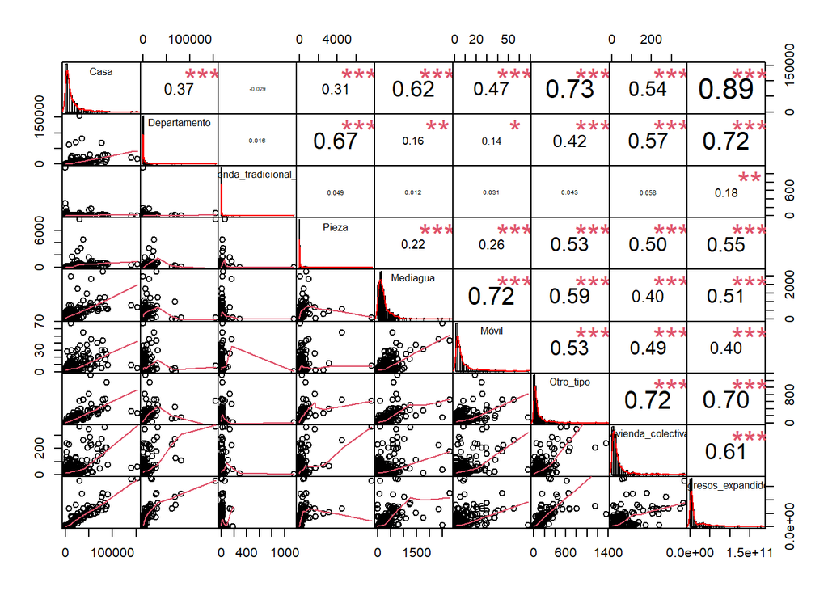

```r
library("PerformanceAnalytics")
my_data <- df_2017_2[, c(3,6,9,12,15,18,21,24,37)]
chart.Correlation(my_data, histogram=TRUE, pch=20)
```

La última columna nos indica en formato numérico las correlaciones de Pearson entre los ingresos expandidos y cada una de las categorías de respuesta. Por otro lado, la última fila nos entrega los diagramas de dispersión con una curva ajustada por Loess, también entre los ingresos expandidos y cada una de las categorías de respuesta.

## 1.2 Pregunta **P03A**: Material de los muros exteriores

Ésta pregunta posee 6 categorías de respuesta:

1 Hormigón armado  
2 Albañilería: bloque de cemento, piedra o ladrillo  
3 Tabique forrado por ambas caras (madera o acero)  
4 Tabique sin forro interior (madera u otro)  
5 Adobe, barro, quincha, pirca u otro artesanal tradicional  
6 Materiales precarios (lata, cartón, plástico, etc.)  
98 No aplica  
99 Missing

### 1.2.1 Cálculo de frecuencias

Leemos las respuestas a la pregunta **P03A** del censo de viviendas 2017 y obtenemos la tabla de frecuencias por categoría de respuesta:

```r
tabla_con_clave <- readRDS("../censo_viviendas_con_clave_17.rds")
b <- tabla_con_clave$COMUNA
c <- tabla_con_clave$P03A
cross_tab =  xtabs( ~ unlist(b) + unlist(c))
tabla <- as.data.frame(cross_tab)
d <-tabla[!(tabla$Freq == 0),]
d$anio <- "2017"

d_t <- filter(d,d$unlist.c. == 1)
for(i in 2:6){
  d_i <- filter(d,d$unlist.c. == i)
  d_t = merge( x = d_t, y = d_i, by = "unlist.b.", all.x = TRUE)
}

tablamadre <- head(d_t,50)
kbl(tablamadre) %>%
  kable_styling(bootstrap_options = c("striped", "hover")) %>%
  kable_paper() %>%
  scroll_box(width = "100%", height = "300px")
```

| unlist.b. | unlist.c..x | Freq.x | anio.x | unlist.c..y | Freq.y | anio.y | unlist.c..x | Freq.x | anio.x | unlist.c..y | Freq.y | anio.y | unlist.c..x | Freq.x | anio.x | unlist.c..y | Freq.y | anio.y |
| --- | --- | --- | --- | --- | --- | --- | --- | --- | --- | --- | --- | --- | --- | --- | --- | --- | --- | --- |
| 1101 | 1 | 20712 | 2017 | 2 | 24336 | 2017 | 3 | 7275 | 2017 | 4 | 2774 | 2017 | 5 | 84 | 2017 | 6 | 345 | 2017 |
| 1107 | 1 | 6116 | 2017 | 2 | 15902 | 2017 | 3 | 2929 | 2017 | 4 | 2804 | 2017 | 5 | 49 | 2017 | 6 | 503 | 2017 |
| 1401 | 1 | 335 | 2017 | 2 | 2329 | 2017 | 3 | 804 | 2017 | 4 | 448 | 2017 | 5 | 80 | 2017 | 6 | 74 | 2017 |
| 1402 | 1 | 25 | 2017 | 2 | 252 | 2017 | 3 | 77 | 2017 | 4 | 84 | 2017 | 5 | 28 | 2017 | 6 | 1 | 2017 |
| 1403 | 1 | 6 | 2017 | 2 | 48 | 2017 | 3 | 10 | 2017 | 4 | 6 | 2017 | 5 | 393 | 2017 | 6 | 2 | 2017 |
| 1404 | 1 | 109 | 2017 | 2 | 267 | 2017 | 3 | 261 | 2017 | 4 | 210 | 2017 | 5 | 59 | 2017 | 6 | 33 | 2017 |
| 1405 | 1 | 155 | 2017 | 2 | 675 | 2017 | 3 | 396 | 2017 | 4 | 208 | 2017 | 5 | 144 | 2017 | 6 | 21 | 2017 |
| 2101 | 1 | 38456 | 2017 | 2 | 49324 | 2017 | 3 | 5509 | 2017 | 4 | 4020 | 2017 | 5 | 230 | 2017 | 6 | 452 | 2017 |
| 2102 | 1 | 760 | 2017 | 2 | 1615 | 2017 | 3 | 407 | 2017 | 4 | 213 | 2017 | 5 | 1 | 2017 | 6 | 42 | 2017 |
| 2103 | 1 | 34 | 2017 | 2 | 123 | 2017 | 3 | 107 | 2017 | 4 | 58 | 2017 | 5 | 9 | 2017 | 6 | 9 | 2017 |
| 2104 | 1 | 390 | 2017 | 2 | 1642 | 2017 | 3 | 922 | 2017 | 4 | 461 | 2017 | 5 | 13 | 2017 | 6 | 54 | 2017 |
| 2201 | 1 | 12878 | 2017 | 2 | 26196 | 2017 | 3 | 3076 | 2017 | 4 | 1234 | 2017 | 5 | 2121 | 2017 | 6 | 426 | 2017 |
| 2203 | 1 | 110 | 2017 | 2 | 1379 | 2017 | 3 | 341 | 2017 | 4 | 135 | 2017 | 5 | 849 | 2017 | 6 | 32 | 2017 |
| 2301 | 1 | 1770 | 2017 | 2 | 3781 | 2017 | 3 | 1645 | 2017 | 4 | 479 | 2017 | 5 | 26 | 2017 | 6 | 69 | 2017 |
| 2302 | 1 | 487 | 2017 | 2 | 681 | 2017 | 3 | 104 | 2017 | 4 | 31 | 2017 | 5 | 96 | 2017 | 6 | 14 | 2017 |
| 3101 | 1 | 7261 | 2017 | 2 | 27532 | 2017 | 3 | 5002 | 2017 | 4 | 3047 | 2017 | 5 | 2154 | 2017 | 6 | 326 | 2017 |
| 3102 | 1 | 754 | 2017 | 2 | 2984 | 2017 | 3 | 1195 | 2017 | 4 | 556 | 2017 | 5 | 46 | 2017 | 6 | 57 | 2017 |
| 3103 | 1 | 156 | 2017 | 2 | 1593 | 2017 | 3 | 897 | 2017 | 4 | 683 | 2017 | 5 | 426 | 2017 | 6 | 36 | 2017 |
| 3201 | 1 | 322 | 2017 | 2 | 1799 | 2017 | 3 | 1092 | 2017 | 4 | 356 | 2017 | 5 | 12 | 2017 | 6 | 95 | 2017 |
| 3202 | 1 | 381 | 2017 | 2 | 2594 | 2017 | 3 | 898 | 2017 | 4 | 278 | 2017 | 5 | 285 | 2017 | 6 | 53 | 2017 |
| 3301 | 1 | 2890 | 2017 | 2 | 8321 | 2017 | 3 | 2398 | 2017 | 4 | 1071 | 2017 | 5 | 809 | 2017 | 6 | 186 | 2017 |
| 3302 | 1 | 109 | 2017 | 2 | 681 | 2017 | 3 | 354 | 2017 | 4 | 207 | 2017 | 5 | 371 | 2017 | 6 | 21 | 2017 |
| 3303 | 1 | 205 | 2017 | 2 | 1048 | 2017 | 3 | 520 | 2017 | 4 | 323 | 2017 | 5 | 122 | 2017 | 6 | 31 | 2017 |
| 3304 | 1 | 443 | 2017 | 2 | 1745 | 2017 | 3 | 656 | 2017 | 4 | 396 | 2017 | 5 | 56 | 2017 | 6 | 34 | 2017 |
| 4101 | 1 | 17806 | 2017 | 2 | 38758 | 2017 | 3 | 6898 | 2017 | 4 | 2191 | 2017 | 5 | 1500 | 2017 | 6 | 120 | 2017 |
| 4102 | 1 | 12907 | 2017 | 2 | 42531 | 2017 | 3 | 7174 | 2017 | 4 | 2381 | 2017 | 5 | 2218 | 2017 | 6 | 165 | 2017 |
| 4103 | 1 | 159 | 2017 | 2 | 1638 | 2017 | 3 | 685 | 2017 | 4 | 292 | 2017 | 5 | 665 | 2017 | 6 | 22 | 2017 |
| 4104 | 1 | 48 | 2017 | 2 | 260 | 2017 | 3 | 758 | 2017 | 4 | 282 | 2017 | 5 | 84 | 2017 | 6 | 24 | 2017 |
| 4105 | 1 | 59 | 2017 | 2 | 601 | 2017 | 3 | 334 | 2017 | 4 | 161 | 2017 | 5 | 428 | 2017 | 6 | 13 | 2017 |
| 4106 | 1 | 615 | 2017 | 2 | 5016 | 2017 | 3 | 1474 | 2017 | 4 | 602 | 2017 | 5 | 953 | 2017 | 6 | 51 | 2017 |
| 4201 | 1 | 513 | 2017 | 2 | 5654 | 2017 | 3 | 2652 | 2017 | 4 | 965 | 2017 | 5 | 334 | 2017 | 6 | 21 | 2017 |
| 4202 | 1 | 56 | 2017 | 2 | 1261 | 2017 | 3 | 893 | 2017 | 4 | 437 | 2017 | 5 | 715 | 2017 | 6 | 19 | 2017 |
| 4203 | 1 | 478 | 2017 | 2 | 3840 | 2017 | 3 | 1980 | 2017 | 4 | 643 | 2017 | 5 | 252 | 2017 | 6 | 11 | 2017 |
| 4204 | 1 | 353 | 2017 | 2 | 4890 | 2017 | 3 | 2177 | 2017 | 4 | 883 | 2017 | 5 | 331 | 2017 | 6 | 53 | 2017 |
| 4301 | 1 | 3009 | 2017 | 2 | 22930 | 2017 | 3 | 4667 | 2017 | 4 | 2250 | 2017 | 5 | 1591 | 2017 | 6 | 105 | 2017 |
| 4302 | 1 | 103 | 2017 | 2 | 2329 | 2017 | 3 | 859 | 2017 | 4 | 477 | 2017 | 5 | 1058 | 2017 | 6 | 40 | 2017 |
| 4303 | 1 | 303 | 2017 | 2 | 4600 | 2017 | 3 | 2351 | 2017 | 4 | 1369 | 2017 | 5 | 1512 | 2017 | 6 | 65 | 2017 |
| 4304 | 1 | 79 | 2017 | 2 | 1966 | 2017 | 3 | 785 | 2017 | 4 | 513 | 2017 | 5 | 359 | 2017 | 6 | 37 | 2017 |
| 4305 | 1 | 37 | 2017 | 2 | 720 | 2017 | 3 | 269 | 2017 | 4 | 93 | 2017 | 5 | 547 | 2017 | 6 | 14 | 2017 |
| 5101 | 1 | 26845 | 2017 | 2 | 31147 | 2017 | 3 | 23038 | 2017 | 4 | 6331 | 2017 | 5 | 8862 | 2017 | 6 | 983 | 2017 |
| 5102 | 1 | 772 | 2017 | 2 | 3902 | 2017 | 3 | 2911 | 2017 | 4 | 743 | 2017 | 5 | 301 | 2017 | 6 | 33 | 2017 |
| 5103 | 1 | 4917 | 2017 | 2 | 3767 | 2017 | 3 | 4184 | 2017 | 4 | 731 | 2017 | 5 | 42 | 2017 | 6 | 24 | 2017 |
| 5104 | 1 | 4 | 2017 | 2 | 6 | 2017 | 3 | 311 | 2017 | 4 | 27 | 2017 | 5 | 1 | 2017 | 6 | 2 | 2017 |
| 5105 | 1 | 397 | 2017 | 2 | 1544 | 2017 | 3 | 3488 | 2017 | 4 | 820 | 2017 | 5 | 75 | 2017 | 6 | 26 | 2017 |
| 5107 | 1 | 1573 | 2017 | 2 | 3819 | 2017 | 3 | 3831 | 2017 | 4 | 1024 | 2017 | 5 | 69 | 2017 | 6 | 38 | 2017 |
| 5109 | 1 | 48422 | 2017 | 2 | 36723 | 2017 | 3 | 22227 | 2017 | 4 | 5973 | 2017 | 5 | 1888 | 2017 | 6 | 576 | 2017 |
| 5201 | 1 | 278 | 2017 | 2 | 662 | 2017 | 3 | 1295 | 2017 | 4 | 162 | 2017 | 5 | 14 | 2017 | 6 | 23 | 2017 |
| 5301 | 1 | 3264 | 2017 | 2 | 14216 | 2017 | 3 | 1522 | 2017 | 4 | 460 | 2017 | 5 | 1019 | 2017 | 6 | 44 | 2017 |
| 5302 | 1 | 514 | 2017 | 2 | 2676 | 2017 | 3 | 790 | 2017 | 4 | 306 | 2017 | 5 | 355 | 2017 | 6 | 10 | 2017 |
| 5303 | 1 | 250 | 2017 | 2 | 2024 | 2017 | 3 | 496 | 2017 | 4 | 167 | 2017 | 5 | 202 | 2017 | 6 | 8 | 2017 |

### 1.2.2 Construcción de un código comunal ad-hoc

Agregamos un cero a los códigos comunales de 4 dígitos, que queda en la columna llamada código:

```r
codigos <- d_t$unlist.b.
rango <- seq(1:nrow(d_t))
cadena <- paste("0",codigos[rango], sep = "")
cadena <- substr(cadena,(nchar(cadena)[rango])-(4),6)
codigos <- as.data.frame(codigos)
cadena <- as.data.frame(cadena)
comuna_corr <- cbind(d_t,cadena)
comuna_corr <- comuna_corr[,-c(1),drop=FALSE]

names(comuna_corr)[19] <- "código"

tablamadre <- head(comuna_corr,50)
kbl(tablamadre) %>%
  kable_styling(bootstrap_options = c("striped", "hover")) %>%
  kable_paper() %>%
  scroll_box(width = "100%", height = "300px")
```

| unlist.c..x | Freq.x | anio.x | unlist.c..y | Freq.y | anio.y | unlist.c..x.1 | Freq.x.1 | anio.x.1 | unlist.c..y.1 | Freq.y.1 | anio.y.1 | unlist.c..x.2 | Freq.x.2 | anio.x.2 | unlist.c..y.2 | Freq.y.2 | anio.y.2 | código |
| --- | --- | --- | --- | --- | --- | --- | --- | --- | --- | --- | --- | --- | --- | --- | --- | --- | --- | --- |
| 1 | 20712 | 2017 | 2 | 24336 | 2017 | 3 | 7275 | 2017 | 4 | 2774 | 2017 | 5 | 84 | 2017 | 6 | 345 | 2017 | 01101 |
| 1 | 6116 | 2017 | 2 | 15902 | 2017 | 3 | 2929 | 2017 | 4 | 2804 | 2017 | 5 | 49 | 2017 | 6 | 503 | 2017 | 01107 |
| 1 | 335 | 2017 | 2 | 2329 | 2017 | 3 | 804 | 2017 | 4 | 448 | 2017 | 5 | 80 | 2017 | 6 | 74 | 2017 | 01401 |
| 1 | 25 | 2017 | 2 | 252 | 2017 | 3 | 77 | 2017 | 4 | 84 | 2017 | 5 | 28 | 2017 | 6 | 1 | 2017 | 01402 |
| 1 | 6 | 2017 | 2 | 48 | 2017 | 3 | 10 | 2017 | 4 | 6 | 2017 | 5 | 393 | 2017 | 6 | 2 | 2017 | 01403 |
| 1 | 109 | 2017 | 2 | 267 | 2017 | 3 | 261 | 2017 | 4 | 210 | 2017 | 5 | 59 | 2017 | 6 | 33 | 2017 | 01404 |
| 1 | 155 | 2017 | 2 | 675 | 2017 | 3 | 396 | 2017 | 4 | 208 | 2017 | 5 | 144 | 2017 | 6 | 21 | 2017 | 01405 |
| 1 | 38456 | 2017 | 2 | 49324 | 2017 | 3 | 5509 | 2017 | 4 | 4020 | 2017 | 5 | 230 | 2017 | 6 | 452 | 2017 | 02101 |
| 1 | 760 | 2017 | 2 | 1615 | 2017 | 3 | 407 | 2017 | 4 | 213 | 2017 | 5 | 1 | 2017 | 6 | 42 | 2017 | 02102 |
| 1 | 34 | 2017 | 2 | 123 | 2017 | 3 | 107 | 2017 | 4 | 58 | 2017 | 5 | 9 | 2017 | 6 | 9 | 2017 | 02103 |
| 1 | 390 | 2017 | 2 | 1642 | 2017 | 3 | 922 | 2017 | 4 | 461 | 2017 | 5 | 13 | 2017 | 6 | 54 | 2017 | 02104 |
| 1 | 12878 | 2017 | 2 | 26196 | 2017 | 3 | 3076 | 2017 | 4 | 1234 | 2017 | 5 | 2121 | 2017 | 6 | 426 | 2017 | 02201 |
| 1 | 110 | 2017 | 2 | 1379 | 2017 | 3 | 341 | 2017 | 4 | 135 | 2017 | 5 | 849 | 2017 | 6 | 32 | 2017 | 02203 |
| 1 | 1770 | 2017 | 2 | 3781 | 2017 | 3 | 1645 | 2017 | 4 | 479 | 2017 | 5 | 26 | 2017 | 6 | 69 | 2017 | 02301 |
| 1 | 487 | 2017 | 2 | 681 | 2017 | 3 | 104 | 2017 | 4 | 31 | 2017 | 5 | 96 | 2017 | 6 | 14 | 2017 | 02302 |
| 1 | 7261 | 2017 | 2 | 27532 | 2017 | 3 | 5002 | 2017 | 4 | 3047 | 2017 | 5 | 2154 | 2017 | 6 | 326 | 2017 | 03101 |
| 1 | 754 | 2017 | 2 | 2984 | 2017 | 3 | 1195 | 2017 | 4 | 556 | 2017 | 5 | 46 | 2017 | 6 | 57 | 2017 | 03102 |
| 1 | 156 | 2017 | 2 | 1593 | 2017 | 3 | 897 | 2017 | 4 | 683 | 2017 | 5 | 426 | 2017 | 6 | 36 | 2017 | 03103 |
| 1 | 322 | 2017 | 2 | 1799 | 2017 | 3 | 1092 | 2017 | 4 | 356 | 2017 | 5 | 12 | 2017 | 6 | 95 | 2017 | 03201 |
| 1 | 381 | 2017 | 2 | 2594 | 2017 | 3 | 898 | 2017 | 4 | 278 | 2017 | 5 | 285 | 2017 | 6 | 53 | 2017 | 03202 |
| 1 | 2890 | 2017 | 2 | 8321 | 2017 | 3 | 2398 | 2017 | 4 | 1071 | 2017 | 5 | 809 | 2017 | 6 | 186 | 2017 | 03301 |
| 1 | 109 | 2017 | 2 | 681 | 2017 | 3 | 354 | 2017 | 4 | 207 | 2017 | 5 | 371 | 2017 | 6 | 21 | 2017 | 03302 |
| 1 | 205 | 2017 | 2 | 1048 | 2017 | 3 | 520 | 2017 | 4 | 323 | 2017 | 5 | 122 | 2017 | 6 | 31 | 2017 | 03303 |
| 1 | 443 | 2017 | 2 | 1745 | 2017 | 3 | 656 | 2017 | 4 | 396 | 2017 | 5 | 56 | 2017 | 6 | 34 | 2017 | 03304 |
| 1 | 17806 | 2017 | 2 | 38758 | 2017 | 3 | 6898 | 2017 | 4 | 2191 | 2017 | 5 | 1500 | 2017 | 6 | 120 | 2017 | 04101 |
| 1 | 12907 | 2017 | 2 | 42531 | 2017 | 3 | 7174 | 2017 | 4 | 2381 | 2017 | 5 | 2218 | 2017 | 6 | 165 | 2017 | 04102 |
| 1 | 159 | 2017 | 2 | 1638 | 2017 | 3 | 685 | 2017 | 4 | 292 | 2017 | 5 | 665 | 2017 | 6 | 22 | 2017 | 04103 |
| 1 | 48 | 2017 | 2 | 260 | 2017 | 3 | 758 | 2017 | 4 | 282 | 2017 | 5 | 84 | 2017 | 6 | 24 | 2017 | 04104 |
| 1 | 59 | 2017 | 2 | 601 | 2017 | 3 | 334 | 2017 | 4 | 161 | 2017 | 5 | 428 | 2017 | 6 | 13 | 2017 | 04105 |
| 1 | 615 | 2017 | 2 | 5016 | 2017 | 3 | 1474 | 2017 | 4 | 602 | 2017 | 5 | 953 | 2017 | 6 | 51 | 2017 | 04106 |
| 1 | 513 | 2017 | 2 | 5654 | 2017 | 3 | 2652 | 2017 | 4 | 965 | 2017 | 5 | 334 | 2017 | 6 | 21 | 2017 | 04201 |
| 1 | 56 | 2017 | 2 | 1261 | 2017 | 3 | 893 | 2017 | 4 | 437 | 2017 | 5 | 715 | 2017 | 6 | 19 | 2017 | 04202 |
| 1 | 478 | 2017 | 2 | 3840 | 2017 | 3 | 1980 | 2017 | 4 | 643 | 2017 | 5 | 252 | 2017 | 6 | 11 | 2017 | 04203 |
| 1 | 353 | 2017 | 2 | 4890 | 2017 | 3 | 2177 | 2017 | 4 | 883 | 2017 | 5 | 331 | 2017 | 6 | 53 | 2017 | 04204 |
| 1 | 3009 | 2017 | 2 | 22930 | 2017 | 3 | 4667 | 2017 | 4 | 2250 | 2017 | 5 | 1591 | 2017 | 6 | 105 | 2017 | 04301 |
| 1 | 103 | 2017 | 2 | 2329 | 2017 | 3 | 859 | 2017 | 4 | 477 | 2017 | 5 | 1058 | 2017 | 6 | 40 | 2017 | 04302 |
| 1 | 303 | 2017 | 2 | 4600 | 2017 | 3 | 2351 | 2017 | 4 | 1369 | 2017 | 5 | 1512 | 2017 | 6 | 65 | 2017 | 04303 |
| 1 | 79 | 2017 | 2 | 1966 | 2017 | 3 | 785 | 2017 | 4 | 513 | 2017 | 5 | 359 | 2017 | 6 | 37 | 2017 | 04304 |
| 1 | 37 | 2017 | 2 | 720 | 2017 | 3 | 269 | 2017 | 4 | 93 | 2017 | 5 | 547 | 2017 | 6 | 14 | 2017 | 04305 |
| 1 | 26845 | 2017 | 2 | 31147 | 2017 | 3 | 23038 | 2017 | 4 | 6331 | 2017 | 5 | 8862 | 2017 | 6 | 983 | 2017 | 05101 |
| 1 | 772 | 2017 | 2 | 3902 | 2017 | 3 | 2911 | 2017 | 4 | 743 | 2017 | 5 | 301 | 2017 | 6 | 33 | 2017 | 05102 |
| 1 | 4917 | 2017 | 2 | 3767 | 2017 | 3 | 4184 | 2017 | 4 | 731 | 2017 | 5 | 42 | 2017 | 6 | 24 | 2017 | 05103 |
| 1 | 4 | 2017 | 2 | 6 | 2017 | 3 | 311 | 2017 | 4 | 27 | 2017 | 5 | 1 | 2017 | 6 | 2 | 2017 | 05104 |
| 1 | 397 | 2017 | 2 | 1544 | 2017 | 3 | 3488 | 2017 | 4 | 820 | 2017 | 5 | 75 | 2017 | 6 | 26 | 2017 | 05105 |
| 1 | 1573 | 2017 | 2 | 3819 | 2017 | 3 | 3831 | 2017 | 4 | 1024 | 2017 | 5 | 69 | 2017 | 6 | 38 | 2017 | 05107 |
| 1 | 48422 | 2017 | 2 | 36723 | 2017 | 3 | 22227 | 2017 | 4 | 5973 | 2017 | 5 | 1888 | 2017 | 6 | 576 | 2017 | 05109 |
| 1 | 278 | 2017 | 2 | 662 | 2017 | 3 | 1295 | 2017 | 4 | 162 | 2017 | 5 | 14 | 2017 | 6 | 23 | 2017 | 05201 |
| 1 | 3264 | 2017 | 2 | 14216 | 2017 | 3 | 1522 | 2017 | 4 | 460 | 2017 | 5 | 1019 | 2017 | 6 | 44 | 2017 | 05301 |
| 1 | 514 | 2017 | 2 | 2676 | 2017 | 3 | 790 | 2017 | 4 | 306 | 2017 | 5 | 355 | 2017 | 6 | 10 | 2017 | 05302 |
| 1 | 250 | 2017 | 2 | 2024 | 2017 | 3 | 496 | 2017 | 4 | 167 | 2017 | 5 | 202 | 2017 | 6 | 8 | 2017 | 05303 |

### 1.2.3 Unión con los ingresos comunales expandidos

Hacemos la unión con los ingresos promedio comunales expandidos:

```r
ingresos_expandidos_2017 <- readRDS("../ingresos_expandidos_17.rds")

df_2017_2 = merge( x = comuna_corr, y = ingresos_expandidos_2017, by = "código", all.x = TRUE)

tablamadre <- head(df_2017_2,50)
kbl(tablamadre) %>%
  kable_styling(bootstrap_options = c("striped", "hover")) %>%
  kable_paper() %>%
  scroll_box(width = "100%", height = "300px")
```

| código | unlist.c..x | Freq.x | anio.x | unlist.c..y | Freq.y | anio.y | unlist.c..x.1 | Freq.x.1 | anio.x.1 | unlist.c..y.1 | Freq.y.1 | anio.y.1 | unlist.c..x.2 | Freq.x.2 | anio.x.2 | unlist.c..y.2 | Freq.y.2 | anio.y.2 | comuna.x | promedio_i | año | comuna.y | personas | Ingresos_expandidos |
| --- | --- | --- | --- | --- | --- | --- | --- | --- | --- | --- | --- | --- | --- | --- | --- | --- | --- | --- | --- | --- | --- | --- | --- | --- |
| 01101 | 1 | 20712 | 2017 | 2 | 24336 | 2017 | 3 | 7275 | 2017 | 4 | 2774 | 2017 | 5 | 84 | 2017 | 6 | 345 | 2017 | Iquique | 354820.7 | 2017 | 1101 | 191468 | 67936815240 |
| 01107 | 1 | 6116 | 2017 | 2 | 15902 | 2017 | 3 | 2929 | 2017 | 4 | 2804 | 2017 | 5 | 49 | 2017 | 6 | 503 | 2017 | Alto Hospicio | 301933.4 | 2017 | 1107 | 108375 | 32722034397 |
| 01401 | 1 | 335 | 2017 | 2 | 2329 | 2017 | 3 | 804 | 2017 | 4 | 448 | 2017 | 5 | 80 | 2017 | 6 | 74 | 2017 | Pozo Almonte | 285981.8 | 2017 | 1401 | 15711 | 4493059532 |
| 01402 | 1 | 25 | 2017 | 2 | 252 | 2017 | 3 | 77 | 2017 | 4 | 84 | 2017 | 5 | 28 | 2017 | 6 | 1 | 2017 | Camiña | 262850.3 | 2017 | 1402 | 1250 | 328562901 |
| 01403 | 1 | 6 | 2017 | 2 | 48 | 2017 | 3 | 10 | 2017 | 4 | 6 | 2017 | 5 | 393 | 2017 | 6 | 2 | 2017 | NA | NA | NA | NA | NA | NA |
| 01404 | 1 | 109 | 2017 | 2 | 267 | 2017 | 3 | 261 | 2017 | 4 | 210 | 2017 | 5 | 59 | 2017 | 6 | 33 | 2017 | Huara | 253968.5 | 2017 | 1404 | 2730 | 693334131 |
| 01405 | 1 | 155 | 2017 | 2 | 675 | 2017 | 3 | 396 | 2017 | 4 | 208 | 2017 | 5 | 144 | 2017 | 6 | 21 | 2017 | Pica | 313007.5 | 2017 | 1405 | 9296 | 2909717399 |
| 02101 | 1 | 38456 | 2017 | 2 | 49324 | 2017 | 3 | 5509 | 2017 | 4 | 4020 | 2017 | 5 | 230 | 2017 | 6 | 452 | 2017 | Antofagasta | 347580.2 | 2017 | 2101 | 361873 | 125779893517 |
| 02102 | 1 | 760 | 2017 | 2 | 1615 | 2017 | 3 | 407 | 2017 | 4 | 213 | 2017 | 5 | 1 | 2017 | 6 | 42 | 2017 | Mejillones | 369770.7 | 2017 | 2102 | 13467 | 4979702302 |
| 02103 | 1 | 34 | 2017 | 2 | 123 | 2017 | 3 | 107 | 2017 | 4 | 58 | 2017 | 5 | 9 | 2017 | 6 | 9 | 2017 | Sierra Gorda | 403458.5 | 2017 | 2103 | 10186 | 4109628188 |
| 02104 | 1 | 390 | 2017 | 2 | 1642 | 2017 | 3 | 922 | 2017 | 4 | 461 | 2017 | 5 | 13 | 2017 | 6 | 54 | 2017 | Taltal | 364539.1 | 2017 | 2104 | 13317 | 4854566842 |
| 02201 | 1 | 12878 | 2017 | 2 | 26196 | 2017 | 3 | 3076 | 2017 | 4 | 1234 | 2017 | 5 | 2121 | 2017 | 6 | 426 | 2017 | Calama | 409671.3 | 2017 | 2201 | 165731 | 67895226712 |
| 02203 | 1 | 110 | 2017 | 2 | 1379 | 2017 | 3 | 341 | 2017 | 4 | 135 | 2017 | 5 | 849 | 2017 | 6 | 32 | 2017 | San Pedro de Atacama | 426592.0 | 2017 | 2203 | 10996 | 4690805471 |
| 02301 | 1 | 1770 | 2017 | 2 | 3781 | 2017 | 3 | 1645 | 2017 | 4 | 479 | 2017 | 5 | 26 | 2017 | 6 | 69 | 2017 | Tocopilla | 246615.3 | 2017 | 2301 | 25186 | 6211253937 |
| 02302 | 1 | 487 | 2017 | 2 | 681 | 2017 | 3 | 104 | 2017 | 4 | 31 | 2017 | 5 | 96 | 2017 | 6 | 14 | 2017 | María Elena | 466266.9 | 2017 | 2302 | 6457 | 3010685220 |
| 03101 | 1 | 7261 | 2017 | 2 | 27532 | 2017 | 3 | 5002 | 2017 | 4 | 3047 | 2017 | 5 | 2154 | 2017 | 6 | 326 | 2017 | Copiapó | 330075.2 | 2017 | 3101 | 153937 | 50810778473 |
| 03102 | 1 | 754 | 2017 | 2 | 2984 | 2017 | 3 | 1195 | 2017 | 4 | 556 | 2017 | 5 | 46 | 2017 | 6 | 57 | 2017 | Caldera | 299314.8 | 2017 | 3102 | 17662 | 5286498241 |
| 03103 | 1 | 156 | 2017 | 2 | 1593 | 2017 | 3 | 897 | 2017 | 4 | 683 | 2017 | 5 | 426 | 2017 | 6 | 36 | 2017 | Tierra Amarilla | 314643.9 | 2017 | 3103 | 14019 | 4410992711 |
| 03201 | 1 | 322 | 2017 | 2 | 1799 | 2017 | 3 | 1092 | 2017 | 4 | 356 | 2017 | 5 | 12 | 2017 | 6 | 95 | 2017 | Chañaral | 286389.3 | 2017 | 3201 | 12219 | 3499391196 |
| 03202 | 1 | 381 | 2017 | 2 | 2594 | 2017 | 3 | 898 | 2017 | 4 | 278 | 2017 | 5 | 285 | 2017 | 6 | 53 | 2017 | Diego de Almagro | 336256.8 | 2017 | 3202 | 13925 | 4682376047 |
| 03301 | 1 | 2890 | 2017 | 2 | 8321 | 2017 | 3 | 2398 | 2017 | 4 | 1071 | 2017 | 5 | 809 | 2017 | 6 | 186 | 2017 | Vallenar | 304336.7 | 2017 | 3301 | 51917 | 15800246795 |
| 03302 | 1 | 109 | 2017 | 2 | 681 | 2017 | 3 | 354 | 2017 | 4 | 207 | 2017 | 5 | 371 | 2017 | 6 | 21 | 2017 | Alto del Carmen | 227130.4 | 2017 | 3302 | 5299 | 1203563833 |
| 03303 | 1 | 205 | 2017 | 2 | 1048 | 2017 | 3 | 520 | 2017 | 4 | 323 | 2017 | 5 | 122 | 2017 | 6 | 31 | 2017 | Freirina | 253086.7 | 2017 | 3303 | 7041 | 1781983257 |
| 03304 | 1 | 443 | 2017 | 2 | 1745 | 2017 | 3 | 656 | 2017 | 4 | 396 | 2017 | 5 | 56 | 2017 | 6 | 34 | 2017 | Huasco | 287406.6 | 2017 | 3304 | 10149 | 2916889629 |
| 04101 | 1 | 17806 | 2017 | 2 | 38758 | 2017 | 3 | 6898 | 2017 | 4 | 2191 | 2017 | 5 | 1500 | 2017 | 6 | 120 | 2017 | La Serena | 270221.9 | 2017 | 4101 | 221054 | 59733627577 |
| 04102 | 1 | 12907 | 2017 | 2 | 42531 | 2017 | 3 | 7174 | 2017 | 4 | 2381 | 2017 | 5 | 2218 | 2017 | 6 | 165 | 2017 | Coquimbo | 261852.6 | 2017 | 4102 | 227730 | 59631700074 |
| 04103 | 1 | 159 | 2017 | 2 | 1638 | 2017 | 3 | 685 | 2017 | 4 | 292 | 2017 | 5 | 665 | 2017 | 6 | 22 | 2017 | Andacollo | 248209.3 | 2017 | 4103 | 11044 | 2741223967 |
| 04104 | 1 | 48 | 2017 | 2 | 260 | 2017 | 3 | 758 | 2017 | 4 | 282 | 2017 | 5 | 84 | 2017 | 6 | 24 | 2017 | La Higuera | 228356.8 | 2017 | 4104 | 4241 | 968461330 |
| 04105 | 1 | 59 | 2017 | 2 | 601 | 2017 | 3 | 334 | 2017 | 4 | 161 | 2017 | 5 | 428 | 2017 | 6 | 13 | 2017 | Paiguano | 205942.1 | 2017 | 4105 | 4497 | 926121774 |
| 04106 | 1 | 615 | 2017 | 2 | 5016 | 2017 | 3 | 1474 | 2017 | 4 | 602 | 2017 | 5 | 953 | 2017 | 6 | 51 | 2017 | Vicuña | 211431.9 | 2017 | 4106 | 27771 | 5871675449 |
| 04201 | 1 | 513 | 2017 | 2 | 5654 | 2017 | 3 | 2652 | 2017 | 4 | 965 | 2017 | 5 | 334 | 2017 | 6 | 21 | 2017 | Illapel | 238674.4 | 2017 | 4201 | 30848 | 7362627007 |
| 04202 | 1 | 56 | 2017 | 2 | 1261 | 2017 | 3 | 893 | 2017 | 4 | 437 | 2017 | 5 | 715 | 2017 | 6 | 19 | 2017 | Canela | 207933.6 | 2017 | 4202 | 9093 | 1890740321 |
| 04203 | 1 | 478 | 2017 | 2 | 3840 | 2017 | 3 | 1980 | 2017 | 4 | 643 | 2017 | 5 | 252 | 2017 | 6 | 11 | 2017 | Los Vilos | 255200.4 | 2017 | 4203 | 21382 | 5456695139 |
| 04204 | 1 | 353 | 2017 | 2 | 4890 | 2017 | 3 | 2177 | 2017 | 4 | 883 | 2017 | 5 | 331 | 2017 | 6 | 53 | 2017 | Salamanca | 242879.5 | 2017 | 4204 | 29347 | 7127783272 |
| 04301 | 1 | 3009 | 2017 | 2 | 22930 | 2017 | 3 | 4667 | 2017 | 4 | 2250 | 2017 | 5 | 1591 | 2017 | 6 | 105 | 2017 | Ovalle | 266522.9 | 2017 | 4301 | 111272 | 29656533187 |
| 04302 | 1 | 103 | 2017 | 2 | 2329 | 2017 | 3 | 859 | 2017 | 4 | 477 | 2017 | 5 | 1058 | 2017 | 6 | 40 | 2017 | Combarbalá | 210409.7 | 2017 | 4302 | 13322 | 2803077721 |
| 04303 | 1 | 303 | 2017 | 2 | 4600 | 2017 | 3 | 2351 | 2017 | 4 | 1369 | 2017 | 5 | 1512 | 2017 | 6 | 65 | 2017 | Monte Patria | 211907.9 | 2017 | 4303 | 30751 | 6516380780 |
| 04304 | 1 | 79 | 2017 | 2 | 1966 | 2017 | 3 | 785 | 2017 | 4 | 513 | 2017 | 5 | 359 | 2017 | 6 | 37 | 2017 | Punitaqui | 194997.8 | 2017 | 4304 | 10956 | 2136395349 |
| 04305 | 1 | 37 | 2017 | 2 | 720 | 2017 | 3 | 269 | 2017 | 4 | 93 | 2017 | 5 | 547 | 2017 | 6 | 14 | 2017 | Río Hurtado | 182027.2 | 2017 | 4305 | 4278 | 778712384 |
| 05101 | 1 | 26845 | 2017 | 2 | 31147 | 2017 | 3 | 23038 | 2017 | 4 | 6331 | 2017 | 5 | 8862 | 2017 | 6 | 983 | 2017 | Valparaíso | 298720.7 | 2017 | 5101 | 296655 | 88616992249 |
| 05102 | 1 | 772 | 2017 | 2 | 3902 | 2017 | 3 | 2911 | 2017 | 4 | 743 | 2017 | 5 | 301 | 2017 | 6 | 33 | 2017 | Casablanca | 312802.7 | 2017 | 5102 | 26867 | 8404070481 |
| 05103 | 1 | 4917 | 2017 | 2 | 3767 | 2017 | 3 | 4184 | 2017 | 4 | 731 | 2017 | 5 | 42 | 2017 | 6 | 24 | 2017 | Concón | 318496.3 | 2017 | 5103 | 42152 | 13425257057 |
| 05104 | 1 | 4 | 2017 | 2 | 6 | 2017 | 3 | 311 | 2017 | 4 | 27 | 2017 | 5 | 1 | 2017 | 6 | 2 | 2017 | NA | NA | NA | NA | NA | NA |
| 05105 | 1 | 397 | 2017 | 2 | 1544 | 2017 | 3 | 3488 | 2017 | 4 | 820 | 2017 | 5 | 75 | 2017 | 6 | 26 | 2017 | Puchuncaví | 288737.2 | 2017 | 5105 | 18546 | 5354920887 |
| 05107 | 1 | 1573 | 2017 | 2 | 3819 | 2017 | 3 | 3831 | 2017 | 4 | 1024 | 2017 | 5 | 69 | 2017 | 6 | 38 | 2017 | Quintero | 316659.1 | 2017 | 5107 | 31923 | 10108709691 |
| 05109 | 1 | 48422 | 2017 | 2 | 36723 | 2017 | 3 | 22227 | 2017 | 4 | 5973 | 2017 | 5 | 1888 | 2017 | 6 | 576 | 2017 | Viña del Mar | 337006.1 | 2017 | 5109 | 334248 | 112643604611 |
| 05201 | 1 | 278 | 2017 | 2 | 662 | 2017 | 3 | 1295 | 2017 | 4 | 162 | 2017 | 5 | 14 | 2017 | 6 | 23 | 2017 | NA | NA | NA | NA | NA | NA |
| 05301 | 1 | 3264 | 2017 | 2 | 14216 | 2017 | 3 | 1522 | 2017 | 4 | 460 | 2017 | 5 | 1019 | 2017 | 6 | 44 | 2017 | Los Andes | 338182.5 | 2017 | 5301 | 66708 | 22559476922 |
| 05302 | 1 | 514 | 2017 | 2 | 2676 | 2017 | 3 | 790 | 2017 | 4 | 306 | 2017 | 5 | 355 | 2017 | 6 | 10 | 2017 | Calle Larga | 245165.4 | 2017 | 5302 | 14832 | 3636293159 |
| 05303 | 1 | 250 | 2017 | 2 | 2024 | 2017 | 3 | 496 | 2017 | 4 | 167 | 2017 | 5 | 202 | 2017 | 6 | 8 | 2017 | Rinconada | 281633.2 | 2017 | 5303 | 10207 | 2874630315 |

### 1.2.4 Renombre de columnas

```r
names(df_2017_2)[3] <- "Hormigón"
names(df_2017_2)[6] <- "Albañilería"
names(df_2017_2)[9] <- "Tabique forrado"
names(df_2017_2)[12] <- "Tabique sin forro"
names(df_2017_2)[15] <- "Adobe"
names(df_2017_2)[18] <- "Materiales precarios"

tablamadre <- head(df_2017_2,50)
kbl(tablamadre) %>%
  kable_styling(bootstrap_options = c("striped", "hover")) %>%
  kable_paper() %>%
  scroll_box(width = "100%", height = "300px")
```

| código | unlist.c..x | Hormigón | anio.x | unlist.c..y | Albañilería | anio.y | unlist.c..x.1 | Tabique forrado | anio.x.1 | unlist.c..y.1 | Tabique sin forro | anio.y.1 | unlist.c..x.2 | Adobe | anio.x.2 | unlist.c..y.2 | Materiales precarios | anio.y.2 | comuna.x | promedio_i | año | comuna.y | personas | Ingresos_expandidos |
| --- | --- | --- | --- | --- | --- | --- | --- | --- | --- | --- | --- | --- | --- | --- | --- | --- | --- | --- | --- | --- | --- | --- | --- | --- |
| 01101 | 1 | 20712 | 2017 | 2 | 24336 | 2017 | 3 | 7275 | 2017 | 4 | 2774 | 2017 | 5 | 84 | 2017 | 6 | 345 | 2017 | Iquique | 354820.7 | 2017 | 1101 | 191468 | 67936815240 |
| 01107 | 1 | 6116 | 2017 | 2 | 15902 | 2017 | 3 | 2929 | 2017 | 4 | 2804 | 2017 | 5 | 49 | 2017 | 6 | 503 | 2017 | Alto Hospicio | 301933.4 | 2017 | 1107 | 108375 | 32722034397 |
| 01401 | 1 | 335 | 2017 | 2 | 2329 | 2017 | 3 | 804 | 2017 | 4 | 448 | 2017 | 5 | 80 | 2017 | 6 | 74 | 2017 | Pozo Almonte | 285981.8 | 2017 | 1401 | 15711 | 4493059532 |
| 01402 | 1 | 25 | 2017 | 2 | 252 | 2017 | 3 | 77 | 2017 | 4 | 84 | 2017 | 5 | 28 | 2017 | 6 | 1 | 2017 | Camiña | 262850.3 | 2017 | 1402 | 1250 | 328562901 |
| 01403 | 1 | 6 | 2017 | 2 | 48 | 2017 | 3 | 10 | 2017 | 4 | 6 | 2017 | 5 | 393 | 2017 | 6 | 2 | 2017 | NA | NA | NA | NA | NA | NA |
| 01404 | 1 | 109 | 2017 | 2 | 267 | 2017 | 3 | 261 | 2017 | 4 | 210 | 2017 | 5 | 59 | 2017 | 6 | 33 | 2017 | Huara | 253968.5 | 2017 | 1404 | 2730 | 693334131 |
| 01405 | 1 | 155 | 2017 | 2 | 675 | 2017 | 3 | 396 | 2017 | 4 | 208 | 2017 | 5 | 144 | 2017 | 6 | 21 | 2017 | Pica | 313007.5 | 2017 | 1405 | 9296 | 2909717399 |
| 02101 | 1 | 38456 | 2017 | 2 | 49324 | 2017 | 3 | 5509 | 2017 | 4 | 4020 | 2017 | 5 | 230 | 2017 | 6 | 452 | 2017 | Antofagasta | 347580.2 | 2017 | 2101 | 361873 | 125779893517 |
| 02102 | 1 | 760 | 2017 | 2 | 1615 | 2017 | 3 | 407 | 2017 | 4 | 213 | 2017 | 5 | 1 | 2017 | 6 | 42 | 2017 | Mejillones | 369770.7 | 2017 | 2102 | 13467 | 4979702302 |
| 02103 | 1 | 34 | 2017 | 2 | 123 | 2017 | 3 | 107 | 2017 | 4 | 58 | 2017 | 5 | 9 | 2017 | 6 | 9 | 2017 | Sierra Gorda | 403458.5 | 2017 | 2103 | 10186 | 4109628188 |
| 02104 | 1 | 390 | 2017 | 2 | 1642 | 2017 | 3 | 922 | 2017 | 4 | 461 | 2017 | 5 | 13 | 2017 | 6 | 54 | 2017 | Taltal | 364539.1 | 2017 | 2104 | 13317 | 4854566842 |
| 02201 | 1 | 12878 | 2017 | 2 | 26196 | 2017 | 3 | 3076 | 2017 | 4 | 1234 | 2017 | 5 | 2121 | 2017 | 6 | 426 | 2017 | Calama | 409671.3 | 2017 | 2201 | 165731 | 67895226712 |
| 02203 | 1 | 110 | 2017 | 2 | 1379 | 2017 | 3 | 341 | 2017 | 4 | 135 | 2017 | 5 | 849 | 2017 | 6 | 32 | 2017 | San Pedro de Atacama | 426592.0 | 2017 | 2203 | 10996 | 4690805471 |
| 02301 | 1 | 1770 | 2017 | 2 | 3781 | 2017 | 3 | 1645 | 2017 | 4 | 479 | 2017 | 5 | 26 | 2017 | 6 | 69 | 2017 | Tocopilla | 246615.3 | 2017 | 2301 | 25186 | 6211253937 |
| 02302 | 1 | 487 | 2017 | 2 | 681 | 2017 | 3 | 104 | 2017 | 4 | 31 | 2017 | 5 | 96 | 2017 | 6 | 14 | 2017 | María Elena | 466266.9 | 2017 | 2302 | 6457 | 3010685220 |
| 03101 | 1 | 7261 | 2017 | 2 | 27532 | 2017 | 3 | 5002 | 2017 | 4 | 3047 | 2017 | 5 | 2154 | 2017 | 6 | 326 | 2017 | Copiapó | 330075.2 | 2017 | 3101 | 153937 | 50810778473 |
| 03102 | 1 | 754 | 2017 | 2 | 2984 | 2017 | 3 | 1195 | 2017 | 4 | 556 | 2017 | 5 | 46 | 2017 | 6 | 57 | 2017 | Caldera | 299314.8 | 2017 | 3102 | 17662 | 5286498241 |
| 03103 | 1 | 156 | 2017 | 2 | 1593 | 2017 | 3 | 897 | 2017 | 4 | 683 | 2017 | 5 | 426 | 2017 | 6 | 36 | 2017 | Tierra Amarilla | 314643.9 | 2017 | 3103 | 14019 | 4410992711 |
| 03201 | 1 | 322 | 2017 | 2 | 1799 | 2017 | 3 | 1092 | 2017 | 4 | 356 | 2017 | 5 | 12 | 2017 | 6 | 95 | 2017 | Chañaral | 286389.3 | 2017 | 3201 | 12219 | 3499391196 |
| 03202 | 1 | 381 | 2017 | 2 | 2594 | 2017 | 3 | 898 | 2017 | 4 | 278 | 2017 | 5 | 285 | 2017 | 6 | 53 | 2017 | Diego de Almagro | 336256.8 | 2017 | 3202 | 13925 | 4682376047 |
| 03301 | 1 | 2890 | 2017 | 2 | 8321 | 2017 | 3 | 2398 | 2017 | 4 | 1071 | 2017 | 5 | 809 | 2017 | 6 | 186 | 2017 | Vallenar | 304336.7 | 2017 | 3301 | 51917 | 15800246795 |
| 03302 | 1 | 109 | 2017 | 2 | 681 | 2017 | 3 | 354 | 2017 | 4 | 207 | 2017 | 5 | 371 | 2017 | 6 | 21 | 2017 | Alto del Carmen | 227130.4 | 2017 | 3302 | 5299 | 1203563833 |
| 03303 | 1 | 205 | 2017 | 2 | 1048 | 2017 | 3 | 520 | 2017 | 4 | 323 | 2017 | 5 | 122 | 2017 | 6 | 31 | 2017 | Freirina | 253086.7 | 2017 | 3303 | 7041 | 1781983257 |
| 03304 | 1 | 443 | 2017 | 2 | 1745 | 2017 | 3 | 656 | 2017 | 4 | 396 | 2017 | 5 | 56 | 2017 | 6 | 34 | 2017 | Huasco | 287406.6 | 2017 | 3304 | 10149 | 2916889629 |
| 04101 | 1 | 17806 | 2017 | 2 | 38758 | 2017 | 3 | 6898 | 2017 | 4 | 2191 | 2017 | 5 | 1500 | 2017 | 6 | 120 | 2017 | La Serena | 270221.9 | 2017 | 4101 | 221054 | 59733627577 |
| 04102 | 1 | 12907 | 2017 | 2 | 42531 | 2017 | 3 | 7174 | 2017 | 4 | 2381 | 2017 | 5 | 2218 | 2017 | 6 | 165 | 2017 | Coquimbo | 261852.6 | 2017 | 4102 | 227730 | 59631700074 |
| 04103 | 1 | 159 | 2017 | 2 | 1638 | 2017 | 3 | 685 | 2017 | 4 | 292 | 2017 | 5 | 665 | 2017 | 6 | 22 | 2017 | Andacollo | 248209.3 | 2017 | 4103 | 11044 | 2741223967 |
| 04104 | 1 | 48 | 2017 | 2 | 260 | 2017 | 3 | 758 | 2017 | 4 | 282 | 2017 | 5 | 84 | 2017 | 6 | 24 | 2017 | La Higuera | 228356.8 | 2017 | 4104 | 4241 | 968461330 |
| 04105 | 1 | 59 | 2017 | 2 | 601 | 2017 | 3 | 334 | 2017 | 4 | 161 | 2017 | 5 | 428 | 2017 | 6 | 13 | 2017 | Paiguano | 205942.1 | 2017 | 4105 | 4497 | 926121774 |
| 04106 | 1 | 615 | 2017 | 2 | 5016 | 2017 | 3 | 1474 | 2017 | 4 | 602 | 2017 | 5 | 953 | 2017 | 6 | 51 | 2017 | Vicuña | 211431.9 | 2017 | 4106 | 27771 | 5871675449 |
| 04201 | 1 | 513 | 2017 | 2 | 5654 | 2017 | 3 | 2652 | 2017 | 4 | 965 | 2017 | 5 | 334 | 2017 | 6 | 21 | 2017 | Illapel | 238674.4 | 2017 | 4201 | 30848 | 7362627007 |
| 04202 | 1 | 56 | 2017 | 2 | 1261 | 2017 | 3 | 893 | 2017 | 4 | 437 | 2017 | 5 | 715 | 2017 | 6 | 19 | 2017 | Canela | 207933.6 | 2017 | 4202 | 9093 | 1890740321 |
| 04203 | 1 | 478 | 2017 | 2 | 3840 | 2017 | 3 | 1980 | 2017 | 4 | 643 | 2017 | 5 | 252 | 2017 | 6 | 11 | 2017 | Los Vilos | 255200.4 | 2017 | 4203 | 21382 | 5456695139 |
| 04204 | 1 | 353 | 2017 | 2 | 4890 | 2017 | 3 | 2177 | 2017 | 4 | 883 | 2017 | 5 | 331 | 2017 | 6 | 53 | 2017 | Salamanca | 242879.5 | 2017 | 4204 | 29347 | 7127783272 |
| 04301 | 1 | 3009 | 2017 | 2 | 22930 | 2017 | 3 | 4667 | 2017 | 4 | 2250 | 2017 | 5 | 1591 | 2017 | 6 | 105 | 2017 | Ovalle | 266522.9 | 2017 | 4301 | 111272 | 29656533187 |
| 04302 | 1 | 103 | 2017 | 2 | 2329 | 2017 | 3 | 859 | 2017 | 4 | 477 | 2017 | 5 | 1058 | 2017 | 6 | 40 | 2017 | Combarbalá | 210409.7 | 2017 | 4302 | 13322 | 2803077721 |
| 04303 | 1 | 303 | 2017 | 2 | 4600 | 2017 | 3 | 2351 | 2017 | 4 | 1369 | 2017 | 5 | 1512 | 2017 | 6 | 65 | 2017 | Monte Patria | 211907.9 | 2017 | 4303 | 30751 | 6516380780 |
| 04304 | 1 | 79 | 2017 | 2 | 1966 | 2017 | 3 | 785 | 2017 | 4 | 513 | 2017 | 5 | 359 | 2017 | 6 | 37 | 2017 | Punitaqui | 194997.8 | 2017 | 4304 | 10956 | 2136395349 |
| 04305 | 1 | 37 | 2017 | 2 | 720 | 2017 | 3 | 269 | 2017 | 4 | 93 | 2017 | 5 | 547 | 2017 | 6 | 14 | 2017 | Río Hurtado | 182027.2 | 2017 | 4305 | 4278 | 778712384 |
| 05101 | 1 | 26845 | 2017 | 2 | 31147 | 2017 | 3 | 23038 | 2017 | 4 | 6331 | 2017 | 5 | 8862 | 2017 | 6 | 983 | 2017 | Valparaíso | 298720.7 | 2017 | 5101 | 296655 | 88616992249 |
| 05102 | 1 | 772 | 2017 | 2 | 3902 | 2017 | 3 | 2911 | 2017 | 4 | 743 | 2017 | 5 | 301 | 2017 | 6 | 33 | 2017 | Casablanca | 312802.7 | 2017 | 5102 | 26867 | 8404070481 |
| 05103 | 1 | 4917 | 2017 | 2 | 3767 | 2017 | 3 | 4184 | 2017 | 4 | 731 | 2017 | 5 | 42 | 2017 | 6 | 24 | 2017 | Concón | 318496.3 | 2017 | 5103 | 42152 | 13425257057 |
| 05104 | 1 | 4 | 2017 | 2 | 6 | 2017 | 3 | 311 | 2017 | 4 | 27 | 2017 | 5 | 1 | 2017 | 6 | 2 | 2017 | NA | NA | NA | NA | NA | NA |
| 05105 | 1 | 397 | 2017 | 2 | 1544 | 2017 | 3 | 3488 | 2017 | 4 | 820 | 2017 | 5 | 75 | 2017 | 6 | 26 | 2017 | Puchuncaví | 288737.2 | 2017 | 5105 | 18546 | 5354920887 |
| 05107 | 1 | 1573 | 2017 | 2 | 3819 | 2017 | 3 | 3831 | 2017 | 4 | 1024 | 2017 | 5 | 69 | 2017 | 6 | 38 | 2017 | Quintero | 316659.1 | 2017 | 5107 | 31923 | 10108709691 |
| 05109 | 1 | 48422 | 2017 | 2 | 36723 | 2017 | 3 | 22227 | 2017 | 4 | 5973 | 2017 | 5 | 1888 | 2017 | 6 | 576 | 2017 | Viña del Mar | 337006.1 | 2017 | 5109 | 334248 | 112643604611 |
| 05201 | 1 | 278 | 2017 | 2 | 662 | 2017 | 3 | 1295 | 2017 | 4 | 162 | 2017 | 5 | 14 | 2017 | 6 | 23 | 2017 | NA | NA | NA | NA | NA | NA |
| 05301 | 1 | 3264 | 2017 | 2 | 14216 | 2017 | 3 | 1522 | 2017 | 4 | 460 | 2017 | 5 | 1019 | 2017 | 6 | 44 | 2017 | Los Andes | 338182.5 | 2017 | 5301 | 66708 | 22559476922 |
| 05302 | 1 | 514 | 2017 | 2 | 2676 | 2017 | 3 | 790 | 2017 | 4 | 306 | 2017 | 5 | 355 | 2017 | 6 | 10 | 2017 | Calle Larga | 245165.4 | 2017 | 5302 | 14832 | 3636293159 |
| 05303 | 1 | 250 | 2017 | 2 | 2024 | 2017 | 3 | 496 | 2017 | 4 | 167 | 2017 | 5 | 202 | 2017 | 6 | 8 | 2017 | Rinconada | 281633.2 | 2017 | 5303 | 10207 | 2874630315 |

### 1.2.5 **Correlaciones**

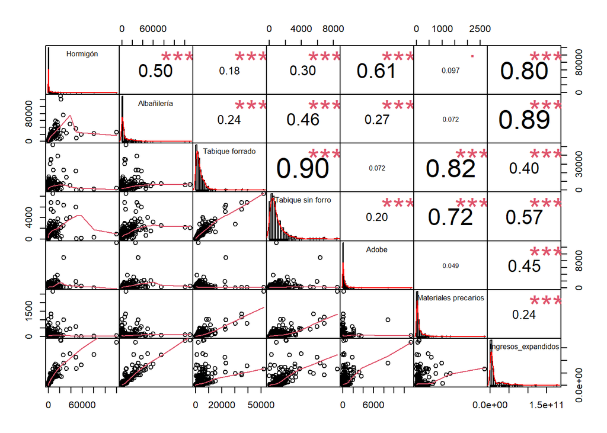

```r
library("PerformanceAnalytics")
my_data <- df_2017_2[, c(3,6,9,12,15,18,25)]
chart.Correlation(my_data, histogram=TRUE, pch=20)
```

## 1.3 Pregunta **P03B**: Material en la cubierta del techo

1 Tejas o tejuelas de arcilla, metálicas, de cemento, de madera, asfálticas o plásticas  
2 Losa hormigón  
3 Planchas metálicas de zinc, cobre, etc. o fibrocemento (tipo pizarreño)  
4 Fonolita o plancha de fieltro embreado  
5 Paja, coirón, totora o caña  
6 Materiales precarios (lata, cartón, plásticos, etc.)  
7 Sin cubierta sólida de techo  
98 No aplica  
99 Missing

### 1.3.1 Cálculo de frecuencias

Leemos las respuestas a la pregunta **P03B** del censo de viviendas 2017 y obtenemos la tabla de frecuencias por categoría de respuesta:

```r
b <- tabla_con_clave$COMUNA
c <- tabla_con_clave$P03B
cross_tab =  xtabs( ~ unlist(b) + unlist(c))
tabla <- as.data.frame(cross_tab)
d <-tabla[!(tabla$Freq == 0),]
d$anio <- "2017"

d_t <- filter(d,d$unlist.c. == 1)
for(i in 2:7){
  d_i <- filter(d,d$unlist.c. == i)
  d_t = merge( x = d_t, y = d_i, by = "unlist.b.", all.x = TRUE)
}
```

```r
tablamadre <- head(d_t,50)
kbl(tablamadre) %>%
  kable_styling(bootstrap_options = c("striped", "hover")) %>%
  kable_paper() %>%
  scroll_box(width = "100%", height = "300px")
```

| unlist.b. | unlist.c..x | Freq.x | anio.x | unlist.c..y | Freq.y | anio.y | unlist.c..x | Freq.x | anio.x | unlist.c..y | Freq.y | anio.y | unlist.c..x | Freq.x | anio.x | unlist.c..y | Freq.y | anio.y | unlist.c. | Freq | anio |
| --- | --- | --- | --- | --- | --- | --- | --- | --- | --- | --- | --- | --- | --- | --- | --- | --- | --- | --- | --- | --- | --- |
| 1101 | 1 | 15518 | 2017 | 2 | 17268 | 2017 | 3 | 21126 | 2017 | 4 | 651 | 2017 | 5 | 43 | 2017 | 6 | 590 | 2017 | 7 | 182 | 2017 |
| 1107 | 1 | 7463 | 2017 | 2 | 7673 | 2017 | 3 | 11776 | 2017 | 4 | 344 | 2017 | 5 | 18 | 2017 | 6 | 733 | 2017 | 7 | 190 | 2017 |
| 1401 | 1 | 933 | 2017 | 2 | 112 | 2017 | 3 | 2762 | 2017 | 4 | 75 | 2017 | 5 | 18 | 2017 | 6 | 124 | 2017 | 7 | 32 | 2017 |
| 1402 | 1 | 82 | 2017 | 2 | 6 | 2017 | 3 | 369 | 2017 | 4 | 5 | 2017 | 5 | 1 | 2017 | 6 | 3 | 2017 | 7 | 1 | 2017 |
| 1403 | 1 | 41 | 2017 | 2 | 3 | 2017 | 3 | 344 | 2017 | 4 | 2 | 2017 | 5 | 69 | 2017 | 6 | 3 | 2017 | NA | NA | NA |
| 1404 | 1 | 205 | 2017 | 2 | 13 | 2017 | 3 | 620 | 2017 | 4 | 20 | 2017 | 5 | 9 | 2017 | 6 | 62 | 2017 | 7 | 8 | 2017 |
| 1405 | 1 | 368 | 2017 | 2 | 42 | 2017 | 3 | 1085 | 2017 | 4 | 20 | 2017 | 5 | 40 | 2017 | 6 | 36 | 2017 | 7 | 2 | 2017 |
| 2101 | 1 | 28222 | 2017 | 2 | 30665 | 2017 | 3 | 37231 | 2017 | 4 | 674 | 2017 | 5 | 20 | 2017 | 6 | 715 | 2017 | 7 | 137 | 2017 |
| 2102 | 1 | 753 | 2017 | 2 | 599 | 2017 | 3 | 1602 | 2017 | 4 | 33 | 2017 | 5 | 1 | 2017 | 6 | 34 | 2017 | 7 | 7 | 2017 |
| 2103 | 1 | 48 | 2017 | 2 | 5 | 2017 | 3 | 285 | 2017 | 4 | 1 | 2017 | NA | NA | NA | 6 | 1 | 2017 | NA | NA | NA |
| 2104 | 1 | 701 | 2017 | 2 | 72 | 2017 | 3 | 2574 | 2017 | 4 | 18 | 2017 | NA | NA | NA | 6 | 66 | 2017 | 7 | 22 | 2017 |
| 2201 | 1 | 15078 | 2017 | 2 | 3796 | 2017 | 3 | 25641 | 2017 | 4 | 422 | 2017 | 5 | 44 | 2017 | 6 | 661 | 2017 | 7 | 103 | 2017 |
| 2202 | 1 | 20 | 2017 | NA | NA | NA | 3 | 67 | 2017 | NA | NA | NA | 5 | 4 | 2017 | 6 | 3 | 2017 | NA | NA | NA |
| 2203 | 1 | 424 | 2017 | 2 | 13 | 2017 | 3 | 2094 | 2017 | 4 | 33 | 2017 | 5 | 220 | 2017 | 6 | 54 | 2017 | 7 | 1 | 2017 |
| 2301 | 1 | 2406 | 2017 | 2 | 906 | 2017 | 3 | 4218 | 2017 | 4 | 77 | 2017 | NA | NA | NA | 6 | 97 | 2017 | 7 | 32 | 2017 |
| 2302 | 1 | 410 | 2017 | 2 | 4 | 2017 | 3 | 963 | 2017 | 4 | 2 | 2017 | 5 | 1 | 2017 | 6 | 23 | 2017 | 7 | 3 | 2017 |
| 3101 | 1 | 8019 | 2017 | 2 | 3664 | 2017 | 3 | 32996 | 2017 | 4 | 222 | 2017 | 5 | 29 | 2017 | 6 | 216 | 2017 | 7 | 40 | 2017 |
| 3102 | 1 | 1014 | 2017 | 2 | 79 | 2017 | 3 | 4371 | 2017 | 4 | 32 | 2017 | 5 | 15 | 2017 | 6 | 52 | 2017 | 7 | 16 | 2017 |
| 3103 | 1 | 239 | 2017 | 2 | 5 | 2017 | 3 | 3488 | 2017 | 4 | 12 | 2017 | 5 | 16 | 2017 | 6 | 13 | 2017 | 7 | 5 | 2017 |
| 3201 | 1 | 229 | 2017 | 2 | 71 | 2017 | 3 | 3267 | 2017 | 4 | 31 | 2017 | 5 | 3 | 2017 | 6 | 59 | 2017 | 7 | 5 | 2017 |
| 3202 | 1 | 646 | 2017 | 2 | 670 | 2017 | 3 | 3111 | 2017 | 4 | 5 | 2017 | 5 | 1 | 2017 | 6 | 29 | 2017 | 7 | 5 | 2017 |
| 3301 | 1 | 4699 | 2017 | 2 | 318 | 2017 | 3 | 10268 | 2017 | 4 | 98 | 2017 | 5 | 30 | 2017 | 6 | 181 | 2017 | 7 | 35 | 2017 |
| 3302 | 1 | 214 | 2017 | 2 | 1 | 2017 | 3 | 1445 | 2017 | 4 | 13 | 2017 | 5 | 31 | 2017 | 6 | 27 | 2017 | 7 | 7 | 2017 |
| 3303 | 1 | 315 | 2017 | 2 | 3 | 2017 | 3 | 1886 | 2017 | 4 | 8 | 2017 | 5 | 2 | 2017 | 6 | 23 | 2017 | 7 | 3 | 2017 |
| 3304 | 1 | 531 | 2017 | 2 | 48 | 2017 | 3 | 2640 | 2017 | 4 | 33 | 2017 | 5 | 1 | 2017 | 6 | 48 | 2017 | 7 | 7 | 2017 |
| 4101 | 1 | 23191 | 2017 | 2 | 6839 | 2017 | 3 | 36623 | 2017 | 4 | 264 | 2017 | 5 | 12 | 2017 | 6 | 143 | 2017 | 7 | 42 | 2017 |
| 4102 | 1 | 19353 | 2017 | 2 | 3376 | 2017 | 3 | 43825 | 2017 | 4 | 380 | 2017 | 5 | 16 | 2017 | 6 | 180 | 2017 | 7 | 49 | 2017 |
| 4103 | 1 | 420 | 2017 | 2 | 2 | 2017 | 3 | 2980 | 2017 | 4 | 29 | 2017 | 5 | 1 | 2017 | 6 | 10 | 2017 | 7 | 5 | 2017 |
| 4104 | 1 | 163 | 2017 | NA | NA | NA | 3 | 1238 | 2017 | 4 | 23 | 2017 | NA | NA | NA | 6 | 25 | 2017 | 7 | 3 | 2017 |
| 4105 | 1 | 146 | 2017 | 2 | 1 | 2017 | 3 | 1424 | 2017 | 4 | 4 | 2017 | 5 | 2 | 2017 | 6 | 8 | 2017 | 7 | 4 | 2017 |
| 4106 | 1 | 981 | 2017 | 2 | 26 | 2017 | 3 | 7609 | 2017 | 4 | 27 | 2017 | 5 | 4 | 2017 | 6 | 37 | 2017 | 7 | 9 | 2017 |
| 4201 | 1 | 696 | 2017 | 2 | 75 | 2017 | 3 | 9311 | 2017 | 4 | 20 | 2017 | NA | NA | NA | 6 | 18 | 2017 | 7 | 5 | 2017 |
| 4202 | 1 | 122 | 2017 | 2 | 4 | 2017 | 3 | 3223 | 2017 | 4 | 6 | 2017 | 5 | 6 | 2017 | 6 | 6 | 2017 | 7 | 9 | 2017 |
| 4203 | 1 | 945 | 2017 | 2 | 14 | 2017 | 3 | 6188 | 2017 | 4 | 25 | 2017 | 5 | 2 | 2017 | 6 | 11 | 2017 | 7 | 2 | 2017 |
| 4204 | 1 | 775 | 2017 | 2 | 96 | 2017 | 3 | 7732 | 2017 | 4 | 18 | 2017 | 5 | 2 | 2017 | 6 | 24 | 2017 | 7 | 8 | 2017 |
| 4301 | 1 | 5460 | 2017 | 2 | 755 | 2017 | 3 | 27922 | 2017 | 4 | 179 | 2017 | 5 | 14 | 2017 | 6 | 105 | 2017 | 7 | 22 | 2017 |
| 4302 | 1 | 217 | 2017 | 2 | 2 | 2017 | 3 | 4603 | 2017 | 4 | 7 | 2017 | 5 | 3 | 2017 | 6 | 12 | 2017 | 7 | 9 | 2017 |
| 4303 | 1 | 586 | 2017 | 2 | 14 | 2017 | 3 | 9507 | 2017 | 4 | 29 | 2017 | 5 | 2 | 2017 | 6 | 35 | 2017 | 7 | 5 | 2017 |
| 4304 | 1 | 213 | 2017 | 2 | 6 | 2017 | 3 | 3471 | 2017 | 4 | 9 | 2017 | 5 | 1 | 2017 | 6 | 25 | 2017 | 7 | 4 | 2017 |
| 4305 | 1 | 108 | 2017 | NA | NA | NA | 3 | 1529 | 2017 | 4 | 4 | 2017 | 5 | 1 | 2017 | 6 | 30 | 2017 | NA | NA | NA |
| 5101 | 1 | 19178 | 2017 | 2 | 13731 | 2017 | 3 | 61208 | 2017 | 4 | 259 | 2017 | 5 | 17 | 2017 | 6 | 2398 | 2017 | 7 | 89 | 2017 |
| 5102 | 1 | 1525 | 2017 | 2 | 350 | 2017 | 3 | 6690 | 2017 | 4 | 31 | 2017 | NA | NA | NA | 6 | 50 | 2017 | 7 | 7 | 2017 |
| 5103 | 1 | 4320 | 2017 | 2 | 2589 | 2017 | 3 | 6576 | 2017 | 4 | 72 | 2017 | 5 | 2 | 2017 | 6 | 52 | 2017 | 7 | 4 | 2017 |
| 5104 | 1 | 45 | 2017 | NA | NA | NA | 3 | 302 | 2017 | NA | NA | NA | NA | NA | NA | 6 | 1 | 2017 | NA | NA | NA |
| 5105 | 1 | 1369 | 2017 | 2 | 56 | 2017 | 3 | 4850 | 2017 | 4 | 35 | 2017 | 5 | 3 | 2017 | 6 | 23 | 2017 | 7 | 8 | 2017 |
| 5107 | 1 | 2717 | 2017 | 2 | 503 | 2017 | 3 | 6985 | 2017 | 4 | 49 | 2017 | 5 | 2 | 2017 | 6 | 53 | 2017 | 7 | 19 | 2017 |
| 5109 | 1 | 23960 | 2017 | 2 | 29228 | 2017 | 3 | 60722 | 2017 | 4 | 259 | 2017 | 5 | 13 | 2017 | 6 | 1061 | 2017 | 7 | 96 | 2017 |
| 5201 | 1 | 245 | 2017 | 2 | 4 | 2017 | 3 | 2159 | 2017 | 4 | 7 | 2017 | NA | NA | NA | 6 | 15 | 2017 | 7 | 1 | 2017 |
| 5301 | 1 | 5144 | 2017 | 2 | 1233 | 2017 | 3 | 13952 | 2017 | 4 | 51 | 2017 | 5 | 6 | 2017 | 6 | 56 | 2017 | 7 | 19 | 2017 |
| 5302 | 1 | 1013 | 2017 | 2 | 31 | 2017 | 3 | 3555 | 2017 | 4 | 23 | 2017 | NA | NA | NA | 6 | 14 | 2017 | 7 | 1 | 2017 |

### 1.3.2 Construcción de un código comunal ad-hoc

Agregamos un cero a los códigos comunales de 4 dígitos, que queda en la columna llamada código:

```r
codigos <- d_t$
unlist.b.
rango <- seq(1:nrow(d_t))
cadena <- paste("0",codigos[rango], sep = "")
cadena <- substr(cadena,(nchar(cadena)[rango])-(4),6)
codigos <- as.data.frame(codigos)
cadena <- as.data.frame(cadena)
comuna_corr <- cbind(d_t,cadena)
comuna_corr <- comuna_corr[,-c(1),drop=FALSE]
```

```r
names(comuna_corr)[22] <- "código"
tablamadre <- head(comuna_corr,50)
kbl(tablamadre) %>%
  kable_styling(bootstrap_options = c("striped", "hover")) %>%
  kable_paper() %>%
  scroll_box(width = "100%", height = "300px")
```

| unlist.c..x | Freq.x | anio.x | unlist.c..y | Freq.y | anio.y | unlist.c..x.1 | Freq.x.1 | anio.x.1 | unlist.c..y.1 | Freq.y.1 | anio.y.1 | unlist.c..x.2 | Freq.x.2 | anio.x.2 | unlist.c..y.2 | Freq.y.2 | anio.y.2 | unlist.c. | Freq | anio | código |
| --- | --- | --- | --- | --- | --- | --- | --- | --- | --- | --- | --- | --- | --- | --- | --- | --- | --- | --- | --- | --- | --- |
| 1 | 15518 | 2017 | 2 | 17268 | 2017 | 3 | 21126 | 2017 | 4 | 651 | 2017 | 5 | 43 | 2017 | 6 | 590 | 2017 | 7 | 182 | 2017 | 01101 |
| 1 | 7463 | 2017 | 2 | 7673 | 2017 | 3 | 11776 | 2017 | 4 | 344 | 2017 | 5 | 18 | 2017 | 6 | 733 | 2017 | 7 | 190 | 2017 | 01107 |
| 1 | 933 | 2017 | 2 | 112 | 2017 | 3 | 2762 | 2017 | 4 | 75 | 2017 | 5 | 18 | 2017 | 6 | 124 | 2017 | 7 | 32 | 2017 | 01401 |
| 1 | 82 | 2017 | 2 | 6 | 2017 | 3 | 369 | 2017 | 4 | 5 | 2017 | 5 | 1 | 2017 | 6 | 3 | 2017 | 7 | 1 | 2017 | 01402 |
| 1 | 41 | 2017 | 2 | 3 | 2017 | 3 | 344 | 2017 | 4 | 2 | 2017 | 5 | 69 | 2017 | 6 | 3 | 2017 | NA | NA | NA | 01403 |
| 1 | 205 | 2017 | 2 | 13 | 2017 | 3 | 620 | 2017 | 4 | 20 | 2017 | 5 | 9 | 2017 | 6 | 62 | 2017 | 7 | 8 | 2017 | 01404 |
| 1 | 368 | 2017 | 2 | 42 | 2017 | 3 | 1085 | 2017 | 4 | 20 | 2017 | 5 | 40 | 2017 | 6 | 36 | 2017 | 7 | 2 | 2017 | 01405 |
| 1 | 28222 | 2017 | 2 | 30665 | 2017 | 3 | 37231 | 2017 | 4 | 674 | 2017 | 5 | 20 | 2017 | 6 | 715 | 2017 | 7 | 137 | 2017 | 02101 |
| 1 | 753 | 2017 | 2 | 599 | 2017 | 3 | 1602 | 2017 | 4 | 33 | 2017 | 5 | 1 | 2017 | 6 | 34 | 2017 | 7 | 7 | 2017 | 02102 |
| 1 | 48 | 2017 | 2 | 5 | 2017 | 3 | 285 | 2017 | 4 | 1 | 2017 | NA | NA | NA | 6 | 1 | 2017 | NA | NA | NA | 02103 |
| 1 | 701 | 2017 | 2 | 72 | 2017 | 3 | 2574 | 2017 | 4 | 18 | 2017 | NA | NA | NA | 6 | 66 | 2017 | 7 | 22 | 2017 | 02104 |
| 1 | 15078 | 2017 | 2 | 3796 | 2017 | 3 | 25641 | 2017 | 4 | 422 | 2017 | 5 | 44 | 2017 | 6 | 661 | 2017 | 7 | 103 | 2017 | 02201 |
| 1 | 20 | 2017 | NA | NA | NA | 3 | 67 | 2017 | NA | NA | NA | 5 | 4 | 2017 | 6 | 3 | 2017 | NA | NA | NA | 02202 |
| 1 | 424 | 2017 | 2 | 13 | 2017 | 3 | 2094 | 2017 | 4 | 33 | 2017 | 5 | 220 | 2017 | 6 | 54 | 2017 | 7 | 1 | 2017 | 02203 |
| 1 | 2406 | 2017 | 2 | 906 | 2017 | 3 | 4218 | 2017 | 4 | 77 | 2017 | NA | NA | NA | 6 | 97 | 2017 | 7 | 32 | 2017 | 02301 |
| 1 | 410 | 2017 | 2 | 4 | 2017 | 3 | 963 | 2017 | 4 | 2 | 2017 | 5 | 1 | 2017 | 6 | 23 | 2017 | 7 | 3 | 2017 | 02302 |
| 1 | 8019 | 2017 | 2 | 3664 | 2017 | 3 | 32996 | 2017 | 4 | 222 | 2017 | 5 | 29 | 2017 | 6 | 216 | 2017 | 7 | 40 | 2017 | 03101 |
| 1 | 1014 | 2017 | 2 | 79 | 2017 | 3 | 4371 | 2017 | 4 | 32 | 2017 | 5 | 15 | 2017 | 6 | 52 | 2017 | 7 | 16 | 2017 | 03102 |
| 1 | 239 | 2017 | 2 | 5 | 2017 | 3 | 3488 | 2017 | 4 | 12 | 2017 | 5 | 16 | 2017 | 6 | 13 | 2017 | 7 | 5 | 2017 | 03103 |
| 1 | 229 | 2017 | 2 | 71 | 2017 | 3 | 3267 | 2017 | 4 | 31 | 2017 | 5 | 3 | 2017 | 6 | 59 | 2017 | 7 | 5 | 2017 | 03201 |
| 1 | 646 | 2017 | 2 | 670 | 2017 | 3 | 3111 | 2017 | 4 | 5 | 2017 | 5 | 1 | 2017 | 6 | 29 | 2017 | 7 | 5 | 2017 | 03202 |
| 1 | 4699 | 2017 | 2 | 318 | 2017 | 3 | 10268 | 2017 | 4 | 98 | 2017 | 5 | 30 | 2017 | 6 | 181 | 2017 | 7 | 35 | 2017 | 03301 |
| 1 | 214 | 2017 | 2 | 1 | 2017 | 3 | 1445 | 2017 | 4 | 13 | 2017 | 5 | 31 | 2017 | 6 | 27 | 2017 | 7 | 7 | 2017 | 03302 |
| 1 | 315 | 2017 | 2 | 3 | 2017 | 3 | 1886 | 2017 | 4 | 8 | 2017 | 5 | 2 | 2017 | 6 | 23 | 2017 | 7 | 3 | 2017 | 03303 |
| 1 | 531 | 2017 | 2 | 48 | 2017 | 3 | 2640 | 2017 | 4 | 33 | 2017 | 5 | 1 | 2017 | 6 | 48 | 2017 | 7 | 7 | 2017 | 03304 |
| 1 | 23191 | 2017 | 2 | 6839 | 2017 | 3 | 36623 | 2017 | 4 | 264 | 2017 | 5 | 12 | 2017 | 6 | 143 | 2017 | 7 | 42 | 2017 | 04101 |
| 1 | 19353 | 2017 | 2 | 3376 | 2017 | 3 | 43825 | 2017 | 4 | 380 | 2017 | 5 | 16 | 2017 | 6 | 180 | 2017 | 7 | 49 | 2017 | 04102 |
| 1 | 420 | 2017 | 2 | 2 | 2017 | 3 | 2980 | 2017 | 4 | 29 | 2017 | 5 | 1 | 2017 | 6 | 10 | 2017 | 7 | 5 | 2017 | 04103 |
| 1 | 163 | 2017 | NA | NA | NA | 3 | 1238 | 2017 | 4 | 23 | 2017 | NA | NA | NA | 6 | 25 | 2017 | 7 | 3 | 2017 | 04104 |
| 1 | 146 | 2017 | 2 | 1 | 2017 | 3 | 1424 | 2017 | 4 | 4 | 2017 | 5 | 2 | 2017 | 6 | 8 | 2017 | 7 | 4 | 2017 | 04105 |
| 1 | 981 | 2017 | 2 | 26 | 2017 | 3 | 7609 | 2017 | 4 | 27 | 2017 | 5 | 4 | 2017 | 6 | 37 | 2017 | 7 | 9 | 2017 | 04106 |
| 1 | 696 | 2017 | 2 | 75 | 2017 | 3 | 9311 | 2017 | 4 | 20 | 2017 | NA | NA | NA | 6 | 18 | 2017 | 7 | 5 | 2017 | 04201 |
| 1 | 122 | 2017 | 2 | 4 | 2017 | 3 | 3223 | 2017 | 4 | 6 | 2017 | 5 | 6 | 2017 | 6 | 6 | 2017 | 7 | 9 | 2017 | 04202 |
| 1 | 945 | 2017 | 2 | 14 | 2017 | 3 | 6188 | 2017 | 4 | 25 | 2017 | 5 | 2 | 2017 | 6 | 11 | 2017 | 7 | 2 | 2017 | 04203 |
| 1 | 775 | 2017 | 2 | 96 | 2017 | 3 | 7732 | 2017 | 4 | 18 | 2017 | 5 | 2 | 2017 | 6 | 24 | 2017 | 7 | 8 | 2017 | 04204 |
| 1 | 5460 | 2017 | 2 | 755 | 2017 | 3 | 27922 | 2017 | 4 | 179 | 2017 | 5 | 14 | 2017 | 6 | 105 | 2017 | 7 | 22 | 2017 | 04301 |
| 1 | 217 | 2017 | 2 | 2 | 2017 | 3 | 4603 | 2017 | 4 | 7 | 2017 | 5 | 3 | 2017 | 6 | 12 | 2017 | 7 | 9 | 2017 | 04302 |
| 1 | 586 | 2017 | 2 | 14 | 2017 | 3 | 9507 | 2017 | 4 | 29 | 2017 | 5 | 2 | 2017 | 6 | 35 | 2017 | 7 | 5 | 2017 | 04303 |
| 1 | 213 | 2017 | 2 | 6 | 2017 | 3 | 3471 | 2017 | 4 | 9 | 2017 | 5 | 1 | 2017 | 6 | 25 | 2017 | 7 | 4 | 2017 | 04304 |
| 1 | 108 | 2017 | NA | NA | NA | 3 | 1529 | 2017 | 4 | 4 | 2017 | 5 | 1 | 2017 | 6 | 30 | 2017 | NA | NA | NA | 04305 |
| 1 | 19178 | 2017 | 2 | 13731 | 2017 | 3 | 61208 | 2017 | 4 | 259 | 2017 | 5 | 17 | 2017 | 6 | 2398 | 2017 | 7 | 89 | 2017 | 05101 |
| 1 | 1525 | 2017 | 2 | 350 | 2017 | 3 | 6690 | 2017 | 4 | 31 | 2017 | NA | NA | NA | 6 | 50 | 2017 | 7 | 7 | 2017 | 05102 |
| 1 | 4320 | 2017 | 2 | 2589 | 2017 | 3 | 6576 | 2017 | 4 | 72 | 2017 | 5 | 2 | 2017 | 6 | 52 | 2017 | 7 | 4 | 2017 | 05103 |
| 1 | 45 | 2017 | NA | NA | NA | 3 | 302 | 2017 | NA | NA | NA | NA | NA | NA | 6 | 1 | 2017 | NA | NA | NA | 05104 |
| 1 | 1369 | 2017 | 2 | 56 | 2017 | 3 | 4850 | 2017 | 4 | 35 | 2017 | 5 | 3 | 2017 | 6 | 23 | 2017 | 7 | 8 | 2017 | 05105 |
| 1 | 2717 | 2017 | 2 | 503 | 2017 | 3 | 6985 | 2017 | 4 | 49 | 2017 | 5 | 2 | 2017 | 6 | 53 | 2017 | 7 | 19 | 2017 | 05107 |
| 1 | 23960 | 2017 | 2 | 29228 | 2017 | 3 | 60722 | 2017 | 4 | 259 | 2017 | 5 | 13 | 2017 | 6 | 1061 | 2017 | 7 | 96 | 2017 | 05109 |
| 1 | 245 | 2017 | 2 | 4 | 2017 | 3 | 2159 | 2017 | 4 | 7 | 2017 | NA | NA | NA | 6 | 15 | 2017 | 7 | 1 | 2017 | 05201 |
| 1 | 5144 | 2017 | 2 | 1233 | 2017 | 3 | 13952 | 2017 | 4 | 51 | 2017 | 5 | 6 | 2017 | 6 | 56 | 2017 | 7 | 19 | 2017 | 05301 |
| 1 | 1013 | 2017 | 2 | 31 | 2017 | 3 | 3555 | 2017 | 4 | 23 | 2017 | NA | NA | NA | 6 | 14 | 2017 | 7 | 1 | 2017 | 05302 |

### 1.3.3 Unión con los ingresos comunales expandidos

Hacemos la unión con los ingresos promedio comunales expandidos:

```r
ingresos_expandidos_2017 <- readRDS("../ingresos_expandidos_17.rds")
df_2017_2 = merge( x = comuna_corr, y = ingresos_expandidos_2017, by = "código", all.x = TRUE)
tablamadre <- head(df_2017_2,50)
kbl(tablamadre) %>%
  kable_styling(bootstrap_options = c("striped", "hover")) %>%
  kable_paper() %>%
  scroll_box(width = "100%", height = "300px")
```

| código | unlist.c..x | Freq.x | anio.x | unlist.c..y | Freq.y | anio.y | unlist.c..x.1 | Freq.x.1 | anio.x.1 | unlist.c..y.1 | Freq.y.1 | anio.y.1 | unlist.c..x.2 | Freq.x.2 | anio.x.2 | unlist.c..y.2 | Freq.y.2 | anio.y.2 | unlist.c. | Freq | anio | comuna.x | promedio_i | año | comuna.y | personas | Ingresos_expandidos |
| --- | --- | --- | --- | --- | --- | --- | --- | --- | --- | --- | --- | --- | --- | --- | --- | --- | --- | --- | --- | --- | --- | --- | --- | --- | --- | --- | --- |
| 01101 | 1 | 15518 | 2017 | 2 | 17268 | 2017 | 3 | 21126 | 2017 | 4 | 651 | 2017 | 5 | 43 | 2017 | 6 | 590 | 2017 | 7 | 182 | 2017 | Iquique | 354820.7 | 2017 | 1101 | 191468 | 67936815240 |
| 01107 | 1 | 7463 | 2017 | 2 | 7673 | 2017 | 3 | 11776 | 2017 | 4 | 344 | 2017 | 5 | 18 | 2017 | 6 | 733 | 2017 | 7 | 190 | 2017 | Alto Hospicio | 301933.4 | 2017 | 1107 | 108375 | 32722034397 |
| 01401 | 1 | 933 | 2017 | 2 | 112 | 2017 | 3 | 2762 | 2017 | 4 | 75 | 2017 | 5 | 18 | 2017 | 6 | 124 | 2017 | 7 | 32 | 2017 | Pozo Almonte | 285981.8 | 2017 | 1401 | 15711 | 4493059532 |
| 01402 | 1 | 82 | 2017 | 2 | 6 | 2017 | 3 | 369 | 2017 | 4 | 5 | 2017 | 5 | 1 | 2017 | 6 | 3 | 2017 | 7 | 1 | 2017 | Camiña | 262850.3 | 2017 | 1402 | 1250 | 328562901 |
| 01403 | 1 | 41 | 2017 | 2 | 3 | 2017 | 3 | 344 | 2017 | 4 | 2 | 2017 | 5 | 69 | 2017 | 6 | 3 | 2017 | NA | NA | NA | NA | NA | NA | NA | NA | NA |
| 01404 | 1 | 205 | 2017 | 2 | 13 | 2017 | 3 | 620 | 2017 | 4 | 20 | 2017 | 5 | 9 | 2017 | 6 | 62 | 2017 | 7 | 8 | 2017 | Huara | 253968.5 | 2017 | 1404 | 2730 | 693334131 |
| 01405 | 1 | 368 | 2017 | 2 | 42 | 2017 | 3 | 1085 | 2017 | 4 | 20 | 2017 | 5 | 40 | 2017 | 6 | 36 | 2017 | 7 | 2 | 2017 | Pica | 313007.5 | 2017 | 1405 | 9296 | 2909717399 |
| 02101 | 1 | 28222 | 2017 | 2 | 30665 | 2017 | 3 | 37231 | 2017 | 4 | 674 | 2017 | 5 | 20 | 2017 | 6 | 715 | 2017 | 7 | 137 | 2017 | Antofagasta | 347580.2 | 2017 | 2101 | 361873 | 125779893517 |
| 02102 | 1 | 753 | 2017 | 2 | 599 | 2017 | 3 | 1602 | 2017 | 4 | 33 | 2017 | 5 | 1 | 2017 | 6 | 34 | 2017 | 7 | 7 | 2017 | Mejillones | 369770.7 | 2017 | 2102 | 13467 | 4979702302 |
| 02103 | 1 | 48 | 2017 | 2 | 5 | 2017 | 3 | 285 | 2017 | 4 | 1 | 2017 | NA | NA | NA | 6 | 1 | 2017 | NA | NA | NA | Sierra Gorda | 403458.5 | 2017 | 2103 | 10186 | 4109628188 |
| 02104 | 1 | 701 | 2017 | 2 | 72 | 2017 | 3 | 2574 | 2017 | 4 | 18 | 2017 | NA | NA | NA | 6 | 66 | 2017 | 7 | 22 | 2017 | Taltal | 364539.1 | 2017 | 2104 | 13317 | 4854566842 |
| 02201 | 1 | 15078 | 2017 | 2 | 3796 | 2017 | 3 | 25641 | 2017 | 4 | 422 | 2017 | 5 | 44 | 2017 | 6 | 661 | 2017 | 7 | 103 | 2017 | Calama | 409671.3 | 2017 | 2201 | 165731 | 67895226712 |
| 02202 | 1 | 20 | 2017 | NA | NA | NA | 3 | 67 | 2017 | NA | NA | NA | 5 | 4 | 2017 | 6 | 3 | 2017 | NA | NA | NA | NA | NA | NA | NA | NA | NA |
| 02203 | 1 | 424 | 2017 | 2 | 13 | 2017 | 3 | 2094 | 2017 | 4 | 33 | 2017 | 5 | 220 | 2017 | 6 | 54 | 2017 | 7 | 1 | 2017 | San Pedro de Atacama | 426592.0 | 2017 | 2203 | 10996 | 4690805471 |
| 02301 | 1 | 2406 | 2017 | 2 | 906 | 2017 | 3 | 4218 | 2017 | 4 | 77 | 2017 | NA | NA | NA | 6 | 97 | 2017 | 7 | 32 | 2017 | Tocopilla | 246615.3 | 2017 | 2301 | 25186 | 6211253937 |
| 02302 | 1 | 410 | 2017 | 2 | 4 | 2017 | 3 | 963 | 2017 | 4 | 2 | 2017 | 5 | 1 | 2017 | 6 | 23 | 2017 | 7 | 3 | 2017 | María Elena | 466266.9 | 2017 | 2302 | 6457 | 3010685220 |
| 03101 | 1 | 8019 | 2017 | 2 | 3664 | 2017 | 3 | 32996 | 2017 | 4 | 222 | 2017 | 5 | 29 | 2017 | 6 | 216 | 2017 | 7 | 40 | 2017 | Copiapó | 330075.2 | 2017 | 3101 | 153937 | 50810778473 |
| 03102 | 1 | 1014 | 2017 | 2 | 79 | 2017 | 3 | 4371 | 2017 | 4 | 32 | 2017 | 5 | 15 | 2017 | 6 | 52 | 2017 | 7 | 16 | 2017 | Caldera | 299314.8 | 2017 | 3102 | 17662 | 5286498241 |
| 03103 | 1 | 239 | 2017 | 2 | 5 | 2017 | 3 | 3488 | 2017 | 4 | 12 | 2017 | 5 | 16 | 2017 | 6 | 13 | 2017 | 7 | 5 | 2017 | Tierra Amarilla | 314643.9 | 2017 | 3103 | 14019 | 4410992711 |
| 03201 | 1 | 229 | 2017 | 2 | 71 | 2017 | 3 | 3267 | 2017 | 4 | 31 | 2017 | 5 | 3 | 2017 | 6 | 59 | 2017 | 7 | 5 | 2017 | Chañaral | 286389.3 | 2017 | 3201 | 12219 | 3499391196 |
| 03202 | 1 | 646 | 2017 | 2 | 670 | 2017 | 3 | 3111 | 2017 | 4 | 5 | 2017 | 5 | 1 | 2017 | 6 | 29 | 2017 | 7 | 5 | 2017 | Diego de Almagro | 336256.8 | 2017 | 3202 | 13925 | 4682376047 |
| 03301 | 1 | 4699 | 2017 | 2 | 318 | 2017 | 3 | 10268 | 2017 | 4 | 98 | 2017 | 5 | 30 | 2017 | 6 | 181 | 2017 | 7 | 35 | 2017 | Vallenar | 304336.7 | 2017 | 3301 | 51917 | 15800246795 |
| 03302 | 1 | 214 | 2017 | 2 | 1 | 2017 | 3 | 1445 | 2017 | 4 | 13 | 2017 | 5 | 31 | 2017 | 6 | 27 | 2017 | 7 | 7 | 2017 | Alto del Carmen | 227130.4 | 2017 | 3302 | 5299 | 1203563833 |
| 03303 | 1 | 315 | 2017 | 2 | 3 | 2017 | 3 | 1886 | 2017 | 4 | 8 | 2017 | 5 | 2 | 2017 | 6 | 23 | 2017 | 7 | 3 | 2017 | Freirina | 253086.7 | 2017 | 3303 | 7041 | 1781983257 |
| 03304 | 1 | 531 | 2017 | 2 | 48 | 2017 | 3 | 2640 | 2017 | 4 | 33 | 2017 | 5 | 1 | 2017 | 6 | 48 | 2017 | 7 | 7 | 2017 | Huasco | 287406.6 | 2017 | 3304 | 10149 | 2916889629 |
| 04101 | 1 | 23191 | 2017 | 2 | 6839 | 2017 | 3 | 36623 | 2017 | 4 | 264 | 2017 | 5 | 12 | 2017 | 6 | 143 | 2017 | 7 | 42 | 2017 | La Serena | 270221.9 | 2017 | 4101 | 221054 | 59733627577 |
| 04102 | 1 | 19353 | 2017 | 2 | 3376 | 2017 | 3 | 43825 | 2017 | 4 | 380 | 2017 | 5 | 16 | 2017 | 6 | 180 | 2017 | 7 | 49 | 2017 | Coquimbo | 261852.6 | 2017 | 4102 | 227730 | 59631700074 |
| 04103 | 1 | 420 | 2017 | 2 | 2 | 2017 | 3 | 2980 | 2017 | 4 | 29 | 2017 | 5 | 1 | 2017 | 6 | 10 | 2017 | 7 | 5 | 2017 | Andacollo | 248209.3 | 2017 | 4103 | 11044 | 2741223967 |
| 04104 | 1 | 163 | 2017 | NA | NA | NA | 3 | 1238 | 2017 | 4 | 23 | 2017 | NA | NA | NA | 6 | 25 | 2017 | 7 | 3 | 2017 | La Higuera | 228356.8 | 2017 | 4104 | 4241 | 968461330 |
| 04105 | 1 | 146 | 2017 | 2 | 1 | 2017 | 3 | 1424 | 2017 | 4 | 4 | 2017 | 5 | 2 | 2017 | 6 | 8 | 2017 | 7 | 4 | 2017 | Paiguano | 205942.1 | 2017 | 4105 | 4497 | 926121774 |
| 04106 | 1 | 981 | 2017 | 2 | 26 | 2017 | 3 | 7609 | 2017 | 4 | 27 | 2017 | 5 | 4 | 2017 | 6 | 37 | 2017 | 7 | 9 | 2017 | Vicuña | 211431.9 | 2017 | 4106 | 27771 | 5871675449 |
| 04201 | 1 | 696 | 2017 | 2 | 75 | 2017 | 3 | 9311 | 2017 | 4 | 20 | 2017 | NA | NA | NA | 6 | 18 | 2017 | 7 | 5 | 2017 | Illapel | 238674.4 | 2017 | 4201 | 30848 | 7362627007 |
| 04202 | 1 | 122 | 2017 | 2 | 4 | 2017 | 3 | 3223 | 2017 | 4 | 6 | 2017 | 5 | 6 | 2017 | 6 | 6 | 2017 | 7 | 9 | 2017 | Canela | 207933.6 | 2017 | 4202 | 9093 | 1890740321 |
| 04203 | 1 | 945 | 2017 | 2 | 14 | 2017 | 3 | 6188 | 2017 | 4 | 25 | 2017 | 5 | 2 | 2017 | 6 | 11 | 2017 | 7 | 2 | 2017 | Los Vilos | 255200.4 | 2017 | 4203 | 21382 | 5456695139 |
| 04204 | 1 | 775 | 2017 | 2 | 96 | 2017 | 3 | 7732 | 2017 | 4 | 18 | 2017 | 5 | 2 | 2017 | 6 | 24 | 2017 | 7 | 8 | 2017 | Salamanca | 242879.5 | 2017 | 4204 | 29347 | 7127783272 |
| 04301 | 1 | 5460 | 2017 | 2 | 755 | 2017 | 3 | 27922 | 2017 | 4 | 179 | 2017 | 5 | 14 | 2017 | 6 | 105 | 2017 | 7 | 22 | 2017 | Ovalle | 266522.9 | 2017 | 4301 | 111272 | 29656533187 |
| 04302 | 1 | 217 | 2017 | 2 | 2 | 2017 | 3 | 4603 | 2017 | 4 | 7 | 2017 | 5 | 3 | 2017 | 6 | 12 | 2017 | 7 | 9 | 2017 | Combarbalá | 210409.7 | 2017 | 4302 | 13322 | 2803077721 |
| 04303 | 1 | 586 | 2017 | 2 | 14 | 2017 | 3 | 9507 | 2017 | 4 | 29 | 2017 | 5 | 2 | 2017 | 6 | 35 | 2017 | 7 | 5 | 2017 | Monte Patria | 211907.9 | 2017 | 4303 | 30751 | 6516380780 |
| 04304 | 1 | 213 | 2017 | 2 | 6 | 2017 | 3 | 3471 | 2017 | 4 | 9 | 2017 | 5 | 1 | 2017 | 6 | 25 | 2017 | 7 | 4 | 2017 | Punitaqui | 194997.8 | 2017 | 4304 | 10956 | 2136395349 |
| 04305 | 1 | 108 | 2017 | NA | NA | NA | 3 | 1529 | 2017 | 4 | 4 | 2017 | 5 | 1 | 2017 | 6 | 30 | 2017 | NA | NA | NA | Río Hurtado | 182027.2 | 2017 | 4305 | 4278 | 778712384 |
| 05101 | 1 | 19178 | 2017 | 2 | 13731 | 2017 | 3 | 61208 | 2017 | 4 | 259 | 2017 | 5 | 17 | 2017 | 6 | 2398 | 2017 | 7 | 89 | 2017 | Valparaíso | 298720.7 | 2017 | 5101 | 296655 | 88616992249 |
| 05102 | 1 | 1525 | 2017 | 2 | 350 | 2017 | 3 | 6690 | 2017 | 4 | 31 | 2017 | NA | NA | NA | 6 | 50 | 2017 | 7 | 7 | 2017 | Casablanca | 312802.7 | 2017 | 5102 | 26867 | 8404070481 |
| 05103 | 1 | 4320 | 2017 | 2 | 2589 | 2017 | 3 | 6576 | 2017 | 4 | 72 | 2017 | 5 | 2 | 2017 | 6 | 52 | 2017 | 7 | 4 | 2017 | Concón | 318496.3 | 2017 | 5103 | 42152 | 13425257057 |
| 05104 | 1 | 45 | 2017 | NA | NA | NA | 3 | 302 | 2017 | NA | NA | NA | NA | NA | NA | 6 | 1 | 2017 | NA | NA | NA | NA | NA | NA | NA | NA | NA |
| 05105 | 1 | 1369 | 2017 | 2 | 56 | 2017 | 3 | 4850 | 2017 | 4 | 35 | 2017 | 5 | 3 | 2017 | 6 | 23 | 2017 | 7 | 8 | 2017 | Puchuncaví | 288737.2 | 2017 | 5105 | 18546 | 5354920887 |
| 05107 | 1 | 2717 | 2017 | 2 | 503 | 2017 | 3 | 6985 | 2017 | 4 | 49 | 2017 | 5 | 2 | 2017 | 6 | 53 | 2017 | 7 | 19 | 2017 | Quintero | 316659.1 | 2017 | 5107 | 31923 | 10108709691 |
| 05109 | 1 | 23960 | 2017 | 2 | 29228 | 2017 | 3 | 60722 | 2017 | 4 | 259 | 2017 | 5 | 13 | 2017 | 6 | 1061 | 2017 | 7 | 96 | 2017 | Viña del Mar | 337006.1 | 2017 | 5109 | 334248 | 112643604611 |
| 05201 | 1 | 245 | 2017 | 2 | 4 | 2017 | 3 | 2159 | 2017 | 4 | 7 | 2017 | NA | NA | NA | 6 | 15 | 2017 | 7 | 1 | 2017 | NA | NA | NA | NA | NA | NA |
| 05301 | 1 | 5144 | 2017 | 2 | 1233 | 2017 | 3 | 13952 | 2017 | 4 | 51 | 2017 | 5 | 6 | 2017 | 6 | 56 | 2017 | 7 | 19 | 2017 | Los Andes | 338182.5 | 2017 | 5301 | 66708 | 22559476922 |
| 05302 | 1 | 1013 | 2017 | 2 | 31 | 2017 | 3 | 3555 | 2017 | 4 | 23 | 2017 | NA | NA | NA | 6 | 14 | 2017 | 7 | 1 | 2017 | Calle Larga | 245165.4 | 2017 | 5302 | 14832 | 3636293159 |

### 1.3.4 Renombre de columnas

```r
names(df_2017_2)[3] <- "Tejas o tejuelas de arcilla"
names(df_2017_2)[6] <- "Losa hormigón"
names(df_2017_2)[9] <- "Planchas metálicas"
names(df_2017_2)[12] <- "Fonolita"
names(df_2017_2)[15] <- "Paja"
names(df_2017_2)[18] <- "Materiales precarios"
names(df_2017_2)[21] <- "Sin cubierta sólida"

tablamadre <- head(df_2017_2,50)
kbl(tablamadre) %>%
  kable_styling(bootstrap_options = c("striped", "hover")) %>%
  kable_paper() %>%
  scroll_box(width = "100%", height = "300px")
```

| código | unlist.c..x | Tejas o tejuelas de arcilla | anio.x | unlist.c..y | Losa hormigón | anio.y | unlist.c..x.1 | Planchas metálicas | anio.x.1 | unlist.c..y.1 | Fonolita | anio.y.1 | unlist.c..x.2 | Paja | anio.x.2 | unlist.c..y.2 | Materiales precarios | anio.y.2 | unlist.c. | Sin cubierta sólida | anio | comuna.x | promedio_i | año | comuna.y | personas | Ingresos_expandidos |
| --- | --- | --- | --- | --- | --- | --- | --- | --- | --- | --- | --- | --- | --- | --- | --- | --- | --- | --- | --- | --- | --- | --- | --- | --- | --- | --- | --- |
| 01101 | 1 | 15518 | 2017 | 2 | 17268 | 2017 | 3 | 21126 | 2017 | 4 | 651 | 2017 | 5 | 43 | 2017 | 6 | 590 | 2017 | 7 | 182 | 2017 | Iquique | 354820.7 | 2017 | 1101 | 191468 | 67936815240 |
| 01107 | 1 | 7463 | 2017 | 2 | 7673 | 2017 | 3 | 11776 | 2017 | 4 | 344 | 2017 | 5 | 18 | 2017 | 6 | 733 | 2017 | 7 | 190 | 2017 | Alto Hospicio | 301933.4 | 2017 | 1107 | 108375 | 32722034397 |
| 01401 | 1 | 933 | 2017 | 2 | 112 | 2017 | 3 | 2762 | 2017 | 4 | 75 | 2017 | 5 | 18 | 2017 | 6 | 124 | 2017 | 7 | 32 | 2017 | Pozo Almonte | 285981.8 | 2017 | 1401 | 15711 | 4493059532 |
| 01402 | 1 | 82 | 2017 | 2 | 6 | 2017 | 3 | 369 | 2017 | 4 | 5 | 2017 | 5 | 1 | 2017 | 6 | 3 | 2017 | 7 | 1 | 2017 | Camiña | 262850.3 | 2017 | 1402 | 1250 | 328562901 |
| 01403 | 1 | 41 | 2017 | 2 | 3 | 2017 | 3 | 344 | 2017 | 4 | 2 | 2017 | 5 | 69 | 2017 | 6 | 3 | 2017 | NA | NA | NA | NA | NA | NA | NA | NA | NA |
| 01404 | 1 | 205 | 2017 | 2 | 13 | 2017 | 3 | 620 | 2017 | 4 | 20 | 2017 | 5 | 9 | 2017 | 6 | 62 | 2017 | 7 | 8 | 2017 | Huara | 253968.5 | 2017 | 1404 | 2730 | 693334131 |
| 01405 | 1 | 368 | 2017 | 2 | 42 | 2017 | 3 | 1085 | 2017 | 4 | 20 | 2017 | 5 | 40 | 2017 | 6 | 36 | 2017 | 7 | 2 | 2017 | Pica | 313007.5 | 2017 | 1405 | 9296 | 2909717399 |
| 02101 | 1 | 28222 | 2017 | 2 | 30665 | 2017 | 3 | 37231 | 2017 | 4 | 674 | 2017 | 5 | 20 | 2017 | 6 | 715 | 2017 | 7 | 137 | 2017 | Antofagasta | 347580.2 | 2017 | 2101 | 361873 | 125779893517 |
| 02102 | 1 | 753 | 2017 | 2 | 599 | 2017 | 3 | 1602 | 2017 | 4 | 33 | 2017 | 5 | 1 | 2017 | 6 | 34 | 2017 | 7 | 7 | 2017 | Mejillones | 369770.7 | 2017 | 2102 | 13467 | 4979702302 |
| 02103 | 1 | 48 | 2017 | 2 | 5 | 2017 | 3 | 285 | 2017 | 4 | 1 | 2017 | NA | NA | NA | 6 | 1 | 2017 | NA | NA | NA | Sierra Gorda | 403458.5 | 2017 | 2103 | 10186 | 4109628188 |
| 02104 | 1 | 701 | 2017 | 2 | 72 | 2017 | 3 | 2574 | 2017 | 4 | 18 | 2017 | NA | NA | NA | 6 | 66 | 2017 | 7 | 22 | 2017 | Taltal | 364539.1 | 2017 | 2104 | 13317 | 4854566842 |
| 02201 | 1 | 15078 | 2017 | 2 | 3796 | 2017 | 3 | 25641 | 2017 | 4 | 422 | 2017 | 5 | 44 | 2017 | 6 | 661 | 2017 | 7 | 103 | 2017 | Calama | 409671.3 | 2017 | 2201 | 165731 | 67895226712 |
| 02202 | 1 | 20 | 2017 | NA | NA | NA | 3 | 67 | 2017 | NA | NA | NA | 5 | 4 | 2017 | 6 | 3 | 2017 | NA | NA | NA | NA | NA | NA | NA | NA | NA |
| 02203 | 1 | 424 | 2017 | 2 | 13 | 2017 | 3 | 2094 | 2017 | 4 | 33 | 2017 | 5 | 220 | 2017 | 6 | 54 | 2017 | 7 | 1 | 2017 | San Pedro de Atacama | 426592.0 | 2017 | 2203 | 10996 | 4690805471 |
| 02301 | 1 | 2406 | 2017 | 2 | 906 | 2017 | 3 | 4218 | 2017 | 4 | 77 | 2017 | NA | NA | NA | 6 | 97 | 2017 | 7 | 32 | 2017 | Tocopilla | 246615.3 | 2017 | 2301 | 25186 | 6211253937 |
| 02302 | 1 | 410 | 2017 | 2 | 4 | 2017 | 3 | 963 | 2017 | 4 | 2 | 2017 | 5 | 1 | 2017 | 6 | 23 | 2017 | 7 | 3 | 2017 | María Elena | 466266.9 | 2017 | 2302 | 6457 | 3010685220 |
| 03101 | 1 | 8019 | 2017 | 2 | 3664 | 2017 | 3 | 32996 | 2017 | 4 | 222 | 2017 | 5 | 29 | 2017 | 6 | 216 | 2017 | 7 | 40 | 2017 | Copiapó | 330075.2 | 2017 | 3101 | 153937 | 50810778473 |
| 03102 | 1 | 1014 | 2017 | 2 | 79 | 2017 | 3 | 4371 | 2017 | 4 | 32 | 2017 | 5 | 15 | 2017 | 6 | 52 | 2017 | 7 | 16 | 2017 | Caldera | 299314.8 | 2017 | 3102 | 17662 | 5286498241 |
| 03103 | 1 | 239 | 2017 | 2 | 5 | 2017 | 3 | 3488 | 2017 | 4 | 12 | 2017 | 5 | 16 | 2017 | 6 | 13 | 2017 | 7 | 5 | 2017 | Tierra Amarilla | 314643.9 | 2017 | 3103 | 14019 | 4410992711 |
| 03201 | 1 | 229 | 2017 | 2 | 71 | 2017 | 3 | 3267 | 2017 | 4 | 31 | 2017 | 5 | 3 | 2017 | 6 | 59 | 2017 | 7 | 5 | 2017 | Chañaral | 286389.3 | 2017 | 3201 | 12219 | 3499391196 |
| 03202 | 1 | 646 | 2017 | 2 | 670 | 2017 | 3 | 3111 | 2017 | 4 | 5 | 2017 | 5 | 1 | 2017 | 6 | 29 | 2017 | 7 | 5 | 2017 | Diego de Almagro | 336256.8 | 2017 | 3202 | 13925 | 4682376047 |
| 03301 | 1 | 4699 | 2017 | 2 | 318 | 2017 | 3 | 10268 | 2017 | 4 | 98 | 2017 | 5 | 30 | 2017 | 6 | 181 | 2017 | 7 | 35 | 2017 | Vallenar | 304336.7 | 2017 | 3301 | 51917 | 15800246795 |
| 03302 | 1 | 214 | 2017 | 2 | 1 | 2017 | 3 | 1445 | 2017 | 4 | 13 | 2017 | 5 | 31 | 2017 | 6 | 27 | 2017 | 7 | 7 | 2017 | Alto del Carmen | 227130.4 | 2017 | 3302 | 5299 | 1203563833 |
| 03303 | 1 | 315 | 2017 | 2 | 3 | 2017 | 3 | 1886 | 2017 | 4 | 8 | 2017 | 5 | 2 | 2017 | 6 | 23 | 2017 | 7 | 3 | 2017 | Freirina | 253086.7 | 2017 | 3303 | 7041 | 1781983257 |
| 03304 | 1 | 531 | 2017 | 2 | 48 | 2017 | 3 | 2640 | 2017 | 4 | 33 | 2017 | 5 | 1 | 2017 | 6 | 48 | 2017 | 7 | 7 | 2017 | Huasco | 287406.6 | 2017 | 3304 | 10149 | 2916889629 |
| 04101 | 1 | 23191 | 2017 | 2 | 6839 | 2017 | 3 | 36623 | 2017 | 4 | 264 | 2017 | 5 | 12 | 2017 | 6 | 143 | 2017 | 7 | 42 | 2017 | La Serena | 270221.9 | 2017 | 4101 | 221054 | 59733627577 |
| 04102 | 1 | 19353 | 2017 | 2 | 3376 | 2017 | 3 | 43825 | 2017 | 4 | 380 | 2017 | 5 | 16 | 2017 | 6 | 180 | 2017 | 7 | 49 | 2017 | Coquimbo | 261852.6 | 2017 | 4102 | 227730 | 59631700074 |
| 04103 | 1 | 420 | 2017 | 2 | 2 | 2017 | 3 | 2980 | 2017 | 4 | 29 | 2017 | 5 | 1 | 2017 | 6 | 10 | 2017 | 7 | 5 | 2017 | Andacollo | 248209.3 | 2017 | 4103 | 11044 | 2741223967 |
| 04104 | 1 | 163 | 2017 | NA | NA | NA | 3 | 1238 | 2017 | 4 | 23 | 2017 | NA | NA | NA | 6 | 25 | 2017 | 7 | 3 | 2017 | La Higuera | 228356.8 | 2017 | 4104 | 4241 | 968461330 |
| 04105 | 1 | 146 | 2017 | 2 | 1 | 2017 | 3 | 1424 | 2017 | 4 | 4 | 2017 | 5 | 2 | 2017 | 6 | 8 | 2017 | 7 | 4 | 2017 | Paiguano | 205942.1 | 2017 | 4105 | 4497 | 926121774 |
| 04106 | 1 | 981 | 2017 | 2 | 26 | 2017 | 3 | 7609 | 2017 | 4 | 27 | 2017 | 5 | 4 | 2017 | 6 | 37 | 2017 | 7 | 9 | 2017 | Vicuña | 211431.9 | 2017 | 4106 | 27771 | 5871675449 |
| 04201 | 1 | 696 | 2017 | 2 | 75 | 2017 | 3 | 9311 | 2017 | 4 | 20 | 2017 | NA | NA | NA | 6 | 18 | 2017 | 7 | 5 | 2017 | Illapel | 238674.4 | 2017 | 4201 | 30848 | 7362627007 |
| 04202 | 1 | 122 | 2017 | 2 | 4 | 2017 | 3 | 3223 | 2017 | 4 | 6 | 2017 | 5 | 6 | 2017 | 6 | 6 | 2017 | 7 | 9 | 2017 | Canela | 207933.6 | 2017 | 4202 | 9093 | 1890740321 |
| 04203 | 1 | 945 | 2017 | 2 | 14 | 2017 | 3 | 6188 | 2017 | 4 | 25 | 2017 | 5 | 2 | 2017 | 6 | 11 | 2017 | 7 | 2 | 2017 | Los Vilos | 255200.4 | 2017 | 4203 | 21382 | 5456695139 |
| 04204 | 1 | 775 | 2017 | 2 | 96 | 2017 | 3 | 7732 | 2017 | 4 | 18 | 2017 | 5 | 2 | 2017 | 6 | 24 | 2017 | 7 | 8 | 2017 | Salamanca | 242879.5 | 2017 | 4204 | 29347 | 7127783272 |
| 04301 | 1 | 5460 | 2017 | 2 | 755 | 2017 | 3 | 27922 | 2017 | 4 | 179 | 2017 | 5 | 14 | 2017 | 6 | 105 | 2017 | 7 | 22 | 2017 | Ovalle | 266522.9 | 2017 | 4301 | 111272 | 29656533187 |
| 04302 | 1 | 217 | 2017 | 2 | 2 | 2017 | 3 | 4603 | 2017 | 4 | 7 | 2017 | 5 | 3 | 2017 | 6 | 12 | 2017 | 7 | 9 | 2017 | Combarbalá | 210409.7 | 2017 | 4302 | 13322 | 2803077721 |
| 04303 | 1 | 586 | 2017 | 2 | 14 | 2017 | 3 | 9507 | 2017 | 4 | 29 | 2017 | 5 | 2 | 2017 | 6 | 35 | 2017 | 7 | 5 | 2017 | Monte Patria | 211907.9 | 2017 | 4303 | 30751 | 6516380780 |
| 04304 | 1 | 213 | 2017 | 2 | 6 | 2017 | 3 | 3471 | 2017 | 4 | 9 | 2017 | 5 | 1 | 2017 | 6 | 25 | 2017 | 7 | 4 | 2017 | Punitaqui | 194997.8 | 2017 | 4304 | 10956 | 2136395349 |
| 04305 | 1 | 108 | 2017 | NA | NA | NA | 3 | 1529 | 2017 | 4 | 4 | 2017 | 5 | 1 | 2017 | 6 | 30 | 2017 | NA | NA | NA | Río Hurtado | 182027.2 | 2017 | 4305 | 4278 | 778712384 |
| 05101 | 1 | 19178 | 2017 | 2 | 13731 | 2017 | 3 | 61208 | 2017 | 4 | 259 | 2017 | 5 | 17 | 2017 | 6 | 2398 | 2017 | 7 | 89 | 2017 | Valparaíso | 298720.7 | 2017 | 5101 | 296655 | 88616992249 |
| 05102 | 1 | 1525 | 2017 | 2 | 350 | 2017 | 3 | 6690 | 2017 | 4 | 31 | 2017 | NA | NA | NA | 6 | 50 | 2017 | 7 | 7 | 2017 | Casablanca | 312802.7 | 2017 | 5102 | 26867 | 8404070481 |
| 05103 | 1 | 4320 | 2017 | 2 | 2589 | 2017 | 3 | 6576 | 2017 | 4 | 72 | 2017 | 5 | 2 | 2017 | 6 | 52 | 2017 | 7 | 4 | 2017 | Concón | 318496.3 | 2017 | 5103 | 42152 | 13425257057 |
| 05104 | 1 | 45 | 2017 | NA | NA | NA | 3 | 302 | 2017 | NA | NA | NA | NA | NA | NA | 6 | 1 | 2017 | NA | NA | NA | NA | NA | NA | NA | NA | NA |
| 05105 | 1 | 1369 | 2017 | 2 | 56 | 2017 | 3 | 4850 | 2017 | 4 | 35 | 2017 | 5 | 3 | 2017 | 6 | 23 | 2017 | 7 | 8 | 2017 | Puchuncaví | 288737.2 | 2017 | 5105 | 18546 | 5354920887 |
| 05107 | 1 | 2717 | 2017 | 2 | 503 | 2017 | 3 | 6985 | 2017 | 4 | 49 | 2017 | 5 | 2 | 2017 | 6 | 53 | 2017 | 7 | 19 | 2017 | Quintero | 316659.1 | 2017 | 5107 | 31923 | 10108709691 |
| 05109 | 1 | 23960 | 2017 | 2 | 29228 | 2017 | 3 | 60722 | 2017 | 4 | 259 | 2017 | 5 | 13 | 2017 | 6 | 1061 | 2017 | 7 | 96 | 2017 | Viña del Mar | 337006.1 | 2017 | 5109 | 334248 | 112643604611 |
| 05201 | 1 | 245 | 2017 | 2 | 4 | 2017 | 3 | 2159 | 2017 | 4 | 7 | 2017 | NA | NA | NA | 6 | 15 | 2017 | 7 | 1 | 2017 | NA | NA | NA | NA | NA | NA |
| 05301 | 1 | 5144 | 2017 | 2 | 1233 | 2017 | 3 | 13952 | 2017 | 4 | 51 | 2017 | 5 | 6 | 2017 | 6 | 56 | 2017 | 7 | 19 | 2017 | Los Andes | 338182.5 | 2017 | 5301 | 66708 | 22559476922 |
| 05302 | 1 | 1013 | 2017 | 2 | 31 | 2017 | 3 | 3555 | 2017 | 4 | 23 | 2017 | NA | NA | NA | 6 | 14 | 2017 | 7 | 1 | 2017 | Calle Larga | 245165.4 | 2017 | 5302 | 14832 | 3636293159 |

### 1.3.5 **Correlaciones**

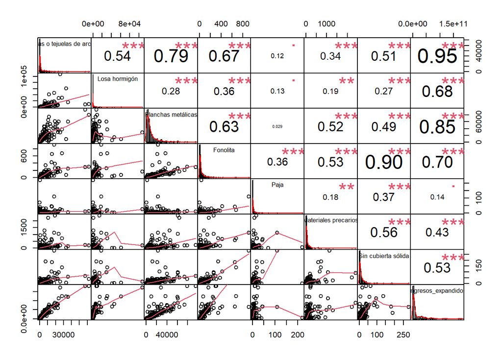

```r
library("PerformanceAnalytics")
my_data <- df_2017_2[, c(3,6,9,12,15,18,21,28)]
chart.Correlation(my_data, histogram=TRUE, pch=20)
```

## 1.4 Pregunta **P03C**: Material de construcción del piso

1 Parquet, piso flotante, cerámico, madera, alfombra, flexit, cubrepiso u otro similar, sobre radier o vigas de madera  
2 Radier sin revestimiento  
3 Baldosa de cemento  
4 Capa de cemento sobre tierra  
5 Tierra

### 1.4.1 Cálculo de frecuencias

Leemos las respuestas a la pregunta P03C del censo de viviendas 2017 y obtenemos la tabla de frecuencias por categoría de respuesta:

```r
b <- tabla_con_clave$COMUNA
c <- tabla_con_clave$P03C
cross_tab =  xtabs( ~ unlist(b) + unlist(c))
tabla <- as.data.frame(cross_tab)
d <-tabla[!(tabla$Freq == 0),]
d$anio <- "2017"

d_t <- filter(d,d$unlist.c. == 1)
for(i in 2:5){
  d_i <- filter(d,d$unlist.c. == i)
  d_t = merge( x = d_t, y = d_i, by = "unlist.b.", all.x = TRUE)
}
```

```r
tablamadre <- head(d_t,50)
kbl(tablamadre) %>%
  kable_styling(bootstrap_options = c("striped", "hover")) %>%
  kable_paper() %>%
  scroll_box(width = "100%", height = "300px")
```

| unlist.b. | unlist.c..x | Freq.x | anio.x | unlist.c..y | Freq.y | anio.y | unlist.c..x | Freq.x | anio.x | unlist.c..y | Freq.y | anio.y | unlist.c. | Freq | anio |
| --- | --- | --- | --- | --- | --- | --- | --- | --- | --- | --- | --- | --- | --- | --- | --- |
| 1101 | 1 | 50233 | 2017 | 2 | 1133 | 2017 | 3 | 2576 | 2017 | 4 | 952 | 2017 | 5 | 336 | 2017 |
| 1107 | 1 | 21459 | 2017 | 2 | 1493 | 2017 | 3 | 2481 | 2017 | 4 | 1476 | 2017 | 5 | 1222 | 2017 |
| 1401 | 1 | 2741 | 2017 | 2 | 484 | 2017 | 3 | 392 | 2017 | 4 | 258 | 2017 | 5 | 172 | 2017 |
| 1402 | 1 | 250 | 2017 | 2 | 58 | 2017 | 3 | 47 | 2017 | 4 | 93 | 2017 | 5 | 21 | 2017 |
| 1403 | 1 | 55 | 2017 | 2 | 63 | 2017 | 3 | 47 | 2017 | 4 | 116 | 2017 | 5 | 174 | 2017 |
| 1404 | 1 | 450 | 2017 | 2 | 162 | 2017 | 3 | 102 | 2017 | 4 | 104 | 2017 | 5 | 121 | 2017 |
| 1405 | 1 | 1103 | 2017 | 2 | 187 | 2017 | 3 | 159 | 2017 | 4 | 99 | 2017 | 5 | 37 | 2017 |
| 2101 | 1 | 87357 | 2017 | 2 | 3156 | 2017 | 3 | 4380 | 2017 | 4 | 1619 | 2017 | 5 | 946 | 2017 |
| 2102 | 1 | 2512 | 2017 | 2 | 195 | 2017 | 3 | 174 | 2017 | 4 | 106 | 2017 | 5 | 31 | 2017 |
| 2103 | 1 | 284 | 2017 | 2 | 29 | 2017 | 3 | 9 | 2017 | 4 | 15 | 2017 | 5 | 5 | 2017 |
| 2104 | 1 | 2756 | 2017 | 2 | 184 | 2017 | 3 | 199 | 2017 | 4 | 178 | 2017 | 5 | 136 | 2017 |
| 2201 | 1 | 40000 | 2017 | 2 | 1443 | 2017 | 3 | 2819 | 2017 | 4 | 914 | 2017 | 5 | 462 | 2017 |
| 2202 | 1 | 71 | 2017 | 2 | 13 | 2017 | 3 | 3 | 2017 | 4 | 4 | 2017 | 5 | 3 | 2017 |
| 2203 | 1 | 1704 | 2017 | 2 | 552 | 2017 | 3 | 264 | 2017 | 4 | 200 | 2017 | 5 | 115 | 2017 |
| 2301 | 1 | 7018 | 2017 | 2 | 137 | 2017 | 3 | 413 | 2017 | 4 | 102 | 2017 | 5 | 68 | 2017 |
| 2302 | 1 | 1331 | 2017 | 2 | 18 | 2017 | 3 | 32 | 2017 | 4 | 17 | 2017 | 5 | 15 | 2017 |
| 3101 | 1 | 40177 | 2017 | 2 | 1118 | 2017 | 3 | 1781 | 2017 | 4 | 1355 | 2017 | 5 | 576 | 2017 |
| 3102 | 1 | 4599 | 2017 | 2 | 305 | 2017 | 3 | 316 | 2017 | 4 | 280 | 2017 | 5 | 95 | 2017 |
| 3103 | 1 | 2905 | 2017 | 2 | 120 | 2017 | 3 | 328 | 2017 | 4 | 337 | 2017 | 5 | 74 | 2017 |
| 3201 | 1 | 3193 | 2017 | 2 | 124 | 2017 | 3 | 209 | 2017 | 4 | 89 | 2017 | 5 | 40 | 2017 |
| 3202 | 1 | 4040 | 2017 | 2 | 118 | 2017 | 3 | 117 | 2017 | 4 | 135 | 2017 | 5 | 34 | 2017 |
| 3301 | 1 | 12313 | 2017 | 2 | 825 | 2017 | 3 | 1182 | 2017 | 4 | 899 | 2017 | 5 | 363 | 2017 |
| 3302 | 1 | 783 | 2017 | 2 | 260 | 2017 | 3 | 276 | 2017 | 4 | 241 | 2017 | 5 | 180 | 2017 |
| 3303 | 1 | 1592 | 2017 | 2 | 191 | 2017 | 3 | 157 | 2017 | 4 | 195 | 2017 | 5 | 111 | 2017 |
| 3304 | 1 | 2589 | 2017 | 2 | 216 | 2017 | 3 | 248 | 2017 | 4 | 150 | 2017 | 5 | 117 | 2017 |
| 4101 | 1 | 61561 | 2017 | 2 | 1285 | 2017 | 3 | 2514 | 2017 | 4 | 1322 | 2017 | 5 | 324 | 2017 |
| 4102 | 1 | 60582 | 2017 | 2 | 1640 | 2017 | 3 | 3005 | 2017 | 4 | 1501 | 2017 | 5 | 284 | 2017 |
| 4103 | 1 | 2753 | 2017 | 2 | 128 | 2017 | 3 | 214 | 2017 | 4 | 244 | 2017 | 5 | 113 | 2017 |
| 4104 | 1 | 1086 | 2017 | 2 | 70 | 2017 | 3 | 103 | 2017 | 4 | 111 | 2017 | 5 | 85 | 2017 |
| 4105 | 1 | 1050 | 2017 | 2 | 129 | 2017 | 3 | 189 | 2017 | 4 | 175 | 2017 | 5 | 52 | 2017 |
| 4106 | 1 | 6926 | 2017 | 2 | 348 | 2017 | 3 | 760 | 2017 | 4 | 492 | 2017 | 5 | 151 | 2017 |
| 4201 | 1 | 8388 | 2017 | 2 | 359 | 2017 | 3 | 636 | 2017 | 4 | 547 | 2017 | 5 | 172 | 2017 |
| 4202 | 1 | 2048 | 2017 | 2 | 272 | 2017 | 3 | 341 | 2017 | 4 | 425 | 2017 | 5 | 288 | 2017 |
| 4203 | 1 | 6291 | 2017 | 2 | 223 | 2017 | 3 | 328 | 2017 | 4 | 263 | 2017 | 5 | 71 | 2017 |
| 4204 | 1 | 6409 | 2017 | 2 | 596 | 2017 | 3 | 856 | 2017 | 4 | 648 | 2017 | 5 | 144 | 2017 |
| 4301 | 1 | 28824 | 2017 | 2 | 1046 | 2017 | 3 | 2484 | 2017 | 4 | 1511 | 2017 | 5 | 539 | 2017 |
| 4302 | 1 | 3043 | 2017 | 2 | 359 | 2017 | 3 | 510 | 2017 | 4 | 630 | 2017 | 5 | 316 | 2017 |
| 4303 | 1 | 6934 | 2017 | 2 | 685 | 2017 | 3 | 1048 | 2017 | 4 | 1080 | 2017 | 5 | 423 | 2017 |
| 4304 | 1 | 2327 | 2017 | 2 | 302 | 2017 | 3 | 383 | 2017 | 4 | 447 | 2017 | 5 | 276 | 2017 |
| 4305 | 1 | 1122 | 2017 | 2 | 90 | 2017 | 3 | 133 | 2017 | 4 | 197 | 2017 | 5 | 132 | 2017 |
| 5101 | 1 | 92766 | 2017 | 2 | 749 | 2017 | 3 | 2450 | 2017 | 4 | 866 | 2017 | 5 | 90 | 2017 |
| 5102 | 1 | 7904 | 2017 | 2 | 185 | 2017 | 3 | 333 | 2017 | 4 | 201 | 2017 | 5 | 20 | 2017 |
| 5103 | 1 | 12863 | 2017 | 2 | 177 | 2017 | 3 | 406 | 2017 | 4 | 145 | 2017 | 5 | 15 | 2017 |
| 5104 | 1 | 345 | 2017 | 2 | 2 | 2017 | 3 | 1 | 2017 | 4 | 2 | 2017 | NA | NA | NA |
| 5105 | 1 | 5566 | 2017 | 2 | 258 | 2017 | 3 | 341 | 2017 | 4 | 132 | 2017 | 5 | 31 | 2017 |
| 5107 | 1 | 9315 | 2017 | 2 | 300 | 2017 | 3 | 469 | 2017 | 4 | 209 | 2017 | 5 | 22 | 2017 |
| 5109 | 1 | 110022 | 2017 | 2 | 1173 | 2017 | 3 | 2969 | 2017 | 4 | 1154 | 2017 | 5 | 91 | 2017 |
| 5201 | 1 | 2105 | 2017 | 2 | 132 | 2017 | 3 | 124 | 2017 | 4 | 52 | 2017 | 5 | 10 | 2017 |
| 5301 | 1 | 18579 | 2017 | 2 | 249 | 2017 | 3 | 1289 | 2017 | 4 | 261 | 2017 | 5 | 33 | 2017 |
| 5302 | 1 | 3969 | 2017 | 2 | 173 | 2017 | 3 | 316 | 2017 | 4 | 138 | 2017 | 5 | 22 | 2017 |

### 1.4.2 Construcción de un código comunal ad-hoc

Agregamos un cero a los códigos comunales de 4 dígitos, que queda en la columna llamada código:

```r
codigos <- d_t$
unlist.b.
rango <- seq(1:nrow(d_t))
cadena <- paste("0",codigos[rango], sep = "")
cadena <- substr(cadena,(nchar(cadena)[rango])-(4),6)
codigos <- as.data.frame(codigos)
cadena <- as.data.frame(cadena)
comuna_corr <- cbind(d_t,cadena)
comuna_corr <- comuna_corr[,-c(1),drop=FALSE]
```

```r
names(comuna_corr)[16] <- "código"
tablamadre <- head(comuna_corr,50)
kbl(tablamadre) %>%
  kable_styling(bootstrap_options = c("striped", "hover")) %>%
  kable_paper() %>%
  scroll_box(width = "100%", height = "300px")
```

| unlist.c..x | Freq.x | anio.x | unlist.c..y | Freq.y | anio.y | unlist.c..x.1 | Freq.x.1 | anio.x.1 | unlist.c..y.1 | Freq.y.1 | anio.y.1 | unlist.c. | Freq | anio | código |
| --- | --- | --- | --- | --- | --- | --- | --- | --- | --- | --- | --- | --- | --- | --- | --- |
| 1 | 50233 | 2017 | 2 | 1133 | 2017 | 3 | 2576 | 2017 | 4 | 952 | 2017 | 5 | 336 | 2017 | 01101 |
| 1 | 21459 | 2017 | 2 | 1493 | 2017 | 3 | 2481 | 2017 | 4 | 1476 | 2017 | 5 | 1222 | 2017 | 01107 |
| 1 | 2741 | 2017 | 2 | 484 | 2017 | 3 | 392 | 2017 | 4 | 258 | 2017 | 5 | 172 | 2017 | 01401 |
| 1 | 250 | 2017 | 2 | 58 | 2017 | 3 | 47 | 2017 | 4 | 93 | 2017 | 5 | 21 | 2017 | 01402 |
| 1 | 55 | 2017 | 2 | 63 | 2017 | 3 | 47 | 2017 | 4 | 116 | 2017 | 5 | 174 | 2017 | 01403 |
| 1 | 450 | 2017 | 2 | 162 | 2017 | 3 | 102 | 2017 | 4 | 104 | 2017 | 5 | 121 | 2017 | 01404 |
| 1 | 1103 | 2017 | 2 | 187 | 2017 | 3 | 159 | 2017 | 4 | 99 | 2017 | 5 | 37 | 2017 | 01405 |
| 1 | 87357 | 2017 | 2 | 3156 | 2017 | 3 | 4380 | 2017 | 4 | 1619 | 2017 | 5 | 946 | 2017 | 02101 |
| 1 | 2512 | 2017 | 2 | 195 | 2017 | 3 | 174 | 2017 | 4 | 106 | 2017 | 5 | 31 | 2017 | 02102 |
| 1 | 284 | 2017 | 2 | 29 | 2017 | 3 | 9 | 2017 | 4 | 15 | 2017 | 5 | 5 | 2017 | 02103 |
| 1 | 2756 | 2017 | 2 | 184 | 2017 | 3 | 199 | 2017 | 4 | 178 | 2017 | 5 | 136 | 2017 | 02104 |
| 1 | 40000 | 2017 | 2 | 1443 | 2017 | 3 | 2819 | 2017 | 4 | 914 | 2017 | 5 | 462 | 2017 | 02201 |
| 1 | 71 | 2017 | 2 | 13 | 2017 | 3 | 3 | 2017 | 4 | 4 | 2017 | 5 | 3 | 2017 | 02202 |
| 1 | 1704 | 2017 | 2 | 552 | 2017 | 3 | 264 | 2017 | 4 | 200 | 2017 | 5 | 115 | 2017 | 02203 |
| 1 | 7018 | 2017 | 2 | 137 | 2017 | 3 | 413 | 2017 | 4 | 102 | 2017 | 5 | 68 | 2017 | 02301 |
| 1 | 1331 | 2017 | 2 | 18 | 2017 | 3 | 32 | 2017 | 4 | 17 | 2017 | 5 | 15 | 2017 | 02302 |
| 1 | 40177 | 2017 | 2 | 1118 | 2017 | 3 | 1781 | 2017 | 4 | 1355 | 2017 | 5 | 576 | 2017 | 03101 |
| 1 | 4599 | 2017 | 2 | 305 | 2017 | 3 | 316 | 2017 | 4 | 280 | 2017 | 5 | 95 | 2017 | 03102 |
| 1 | 2905 | 2017 | 2 | 120 | 2017 | 3 | 328 | 2017 | 4 | 337 | 2017 | 5 | 74 | 2017 | 03103 |
| 1 | 3193 | 2017 | 2 | 124 | 2017 | 3 | 209 | 2017 | 4 | 89 | 2017 | 5 | 40 | 2017 | 03201 |
| 1 | 4040 | 2017 | 2 | 118 | 2017 | 3 | 117 | 2017 | 4 | 135 | 2017 | 5 | 34 | 2017 | 03202 |
| 1 | 12313 | 2017 | 2 | 825 | 2017 | 3 | 1182 | 2017 | 4 | 899 | 2017 | 5 | 363 | 2017 | 03301 |
| 1 | 783 | 2017 | 2 | 260 | 2017 | 3 | 276 | 2017 | 4 | 241 | 2017 | 5 | 180 | 2017 | 03302 |
| 1 | 1592 | 2017 | 2 | 191 | 2017 | 3 | 157 | 2017 | 4 | 195 | 2017 | 5 | 111 | 2017 | 03303 |
| 1 | 2589 | 2017 | 2 | 216 | 2017 | 3 | 248 | 2017 | 4 | 150 | 2017 | 5 | 117 | 2017 | 03304 |
| 1 | 61561 | 2017 | 2 | 1285 | 2017 | 3 | 2514 | 2017 | 4 | 1322 | 2017 | 5 | 324 | 2017 | 04101 |
| 1 | 60582 | 2017 | 2 | 1640 | 2017 | 3 | 3005 | 2017 | 4 | 1501 | 2017 | 5 | 284 | 2017 | 04102 |
| 1 | 2753 | 2017 | 2 | 128 | 2017 | 3 | 214 | 2017 | 4 | 244 | 2017 | 5 | 113 | 2017 | 04103 |
| 1 | 1086 | 2017 | 2 | 70 | 2017 | 3 | 103 | 2017 | 4 | 111 | 2017 | 5 | 85 | 2017 | 04104 |
| 1 | 1050 | 2017 | 2 | 129 | 2017 | 3 | 189 | 2017 | 4 | 175 | 2017 | 5 | 52 | 2017 | 04105 |
| 1 | 6926 | 2017 | 2 | 348 | 2017 | 3 | 760 | 2017 | 4 | 492 | 2017 | 5 | 151 | 2017 | 04106 |
| 1 | 8388 | 2017 | 2 | 359 | 2017 | 3 | 636 | 2017 | 4 | 547 | 2017 | 5 | 172 | 2017 | 04201 |
| 1 | 2048 | 2017 | 2 | 272 | 2017 | 3 | 341 | 2017 | 4 | 425 | 2017 | 5 | 288 | 2017 | 04202 |
| 1 | 6291 | 2017 | 2 | 223 | 2017 | 3 | 328 | 2017 | 4 | 263 | 2017 | 5 | 71 | 2017 | 04203 |
| 1 | 6409 | 2017 | 2 | 596 | 2017 | 3 | 856 | 2017 | 4 | 648 | 2017 | 5 | 144 | 2017 | 04204 |
| 1 | 28824 | 2017 | 2 | 1046 | 2017 | 3 | 2484 | 2017 | 4 | 1511 | 2017 | 5 | 539 | 2017 | 04301 |
| 1 | 3043 | 2017 | 2 | 359 | 2017 | 3 | 510 | 2017 | 4 | 630 | 2017 | 5 | 316 | 2017 | 04302 |
| 1 | 6934 | 2017 | 2 | 685 | 2017 | 3 | 1048 | 2017 | 4 | 1080 | 2017 | 5 | 423 | 2017 | 04303 |
| 1 | 2327 | 2017 | 2 | 302 | 2017 | 3 | 383 | 2017 | 4 | 447 | 2017 | 5 | 276 | 2017 | 04304 |
| 1 | 1122 | 2017 | 2 | 90 | 2017 | 3 | 133 | 2017 | 4 | 197 | 2017 | 5 | 132 | 2017 | 04305 |
| 1 | 92766 | 2017 | 2 | 749 | 2017 | 3 | 2450 | 2017 | 4 | 866 | 2017 | 5 | 90 | 2017 | 05101 |
| 1 | 7904 | 2017 | 2 | 185 | 2017 | 3 | 333 | 2017 | 4 | 201 | 2017 | 5 | 20 | 2017 | 05102 |
| 1 | 12863 | 2017 | 2 | 177 | 2017 | 3 | 406 | 2017 | 4 | 145 | 2017 | 5 | 15 | 2017 | 05103 |
| 1 | 345 | 2017 | 2 | 2 | 2017 | 3 | 1 | 2017 | 4 | 2 | 2017 | NA | NA | NA | 05104 |
| 1 | 5566 | 2017 | 2 | 258 | 2017 | 3 | 341 | 2017 | 4 | 132 | 2017 | 5 | 31 | 2017 | 05105 |
| 1 | 9315 | 2017 | 2 | 300 | 2017 | 3 | 469 | 2017 | 4 | 209 | 2017 | 5 | 22 | 2017 | 05107 |
| 1 | 110022 | 2017 | 2 | 1173 | 2017 | 3 | 2969 | 2017 | 4 | 1154 | 2017 | 5 | 91 | 2017 | 05109 |
| 1 | 2105 | 2017 | 2 | 132 | 2017 | 3 | 124 | 2017 | 4 | 52 | 2017 | 5 | 10 | 2017 | 05201 |
| 1 | 18579 | 2017 | 2 | 249 | 2017 | 3 | 1289 | 2017 | 4 | 261 | 2017 | 5 | 33 | 2017 | 05301 |
| 1 | 3969 | 2017 | 2 | 173 | 2017 | 3 | 316 | 2017 | 4 | 138 | 2017 | 5 | 22 | 2017 | 05302 |

### 1.4.3 Unión con los ingresos comunales expandidos

Hacemos la unión con los ingresos promedio comunales expandidos:

```r
ingresos_expandidos_2017 <- readRDS("../ingresos_expandidos_17.rds")
df_2017_2 = merge( x = comuna_corr, y = ingresos_expandidos_2017, by = "código", all.x = TRUE)
tablamadre <- head(df_2017_2,50)
kbl(tablamadre) %>%
  kable_styling(bootstrap_options = c("striped", "hover")) %>%
  kable_paper() %>%
  scroll_box(width = "100%", height = "300px")
```

| código | unlist.c..x | Freq.x | anio.x | unlist.c..y | Freq.y | anio.y | unlist.c..x.1 | Freq.x.1 | anio.x.1 | unlist.c..y.1 | Freq.y.1 | anio.y.1 | unlist.c. | Freq | anio | comuna.x | promedio_i | año | comuna.y | personas | Ingresos_expandidos |
| --- | --- | --- | --- | --- | --- | --- | --- | --- | --- | --- | --- | --- | --- | --- | --- | --- | --- | --- | --- | --- | --- |
| 01101 | 1 | 50233 | 2017 | 2 | 1133 | 2017 | 3 | 2576 | 2017 | 4 | 952 | 2017 | 5 | 336 | 2017 | Iquique | 354820.7 | 2017 | 1101 | 191468 | 67936815240 |
| 01107 | 1 | 21459 | 2017 | 2 | 1493 | 2017 | 3 | 2481 | 2017 | 4 | 1476 | 2017 | 5 | 1222 | 2017 | Alto Hospicio | 301933.4 | 2017 | 1107 | 108375 | 32722034397 |
| 01401 | 1 | 2741 | 2017 | 2 | 484 | 2017 | 3 | 392 | 2017 | 4 | 258 | 2017 | 5 | 172 | 2017 | Pozo Almonte | 285981.8 | 2017 | 1401 | 15711 | 4493059532 |
| 01402 | 1 | 250 | 2017 | 2 | 58 | 2017 | 3 | 47 | 2017 | 4 | 93 | 2017 | 5 | 21 | 2017 | Camiña | 262850.3 | 2017 | 1402 | 1250 | 328562901 |
| 01403 | 1 | 55 | 2017 | 2 | 63 | 2017 | 3 | 47 | 2017 | 4 | 116 | 2017 | 5 | 174 | 2017 | NA | NA | NA | NA | NA | NA |
| 01404 | 1 | 450 | 2017 | 2 | 162 | 2017 | 3 | 102 | 2017 | 4 | 104 | 2017 | 5 | 121 | 2017 | Huara | 253968.5 | 2017 | 1404 | 2730 | 693334131 |
| 01405 | 1 | 1103 | 2017 | 2 | 187 | 2017 | 3 | 159 | 2017 | 4 | 99 | 2017 | 5 | 37 | 2017 | Pica | 313007.5 | 2017 | 1405 | 9296 | 2909717399 |
| 02101 | 1 | 87357 | 2017 | 2 | 3156 | 2017 | 3 | 4380 | 2017 | 4 | 1619 | 2017 | 5 | 946 | 2017 | Antofagasta | 347580.2 | 2017 | 2101 | 361873 | 125779893517 |
| 02102 | 1 | 2512 | 2017 | 2 | 195 | 2017 | 3 | 174 | 2017 | 4 | 106 | 2017 | 5 | 31 | 2017 | Mejillones | 369770.7 | 2017 | 2102 | 13467 | 4979702302 |
| 02103 | 1 | 284 | 2017 | 2 | 29 | 2017 | 3 | 9 | 2017 | 4 | 15 | 2017 | 5 | 5 | 2017 | Sierra Gorda | 403458.5 | 2017 | 2103 | 10186 | 4109628188 |
| 02104 | 1 | 2756 | 2017 | 2 | 184 | 2017 | 3 | 199 | 2017 | 4 | 178 | 2017 | 5 | 136 | 2017 | Taltal | 364539.1 | 2017 | 2104 | 13317 | 4854566842 |
| 02201 | 1 | 40000 | 2017 | 2 | 1443 | 2017 | 3 | 2819 | 2017 | 4 | 914 | 2017 | 5 | 462 | 2017 | Calama | 409671.3 | 2017 | 2201 | 165731 | 67895226712 |
| 02202 | 1 | 71 | 2017 | 2 | 13 | 2017 | 3 | 3 | 2017 | 4 | 4 | 2017 | 5 | 3 | 2017 | NA | NA | NA | NA | NA | NA |
| 02203 | 1 | 1704 | 2017 | 2 | 552 | 2017 | 3 | 264 | 2017 | 4 | 200 | 2017 | 5 | 115 | 2017 | San Pedro de Atacama | 426592.0 | 2017 | 2203 | 10996 | 4690805471 |
| 02301 | 1 | 7018 | 2017 | 2 | 137 | 2017 | 3 | 413 | 2017 | 4 | 102 | 2017 | 5 | 68 | 2017 | Tocopilla | 246615.3 | 2017 | 2301 | 25186 | 6211253937 |
| 02302 | 1 | 1331 | 2017 | 2 | 18 | 2017 | 3 | 32 | 2017 | 4 | 17 | 2017 | 5 | 15 | 2017 | María Elena | 466266.9 | 2017 | 2302 | 6457 | 3010685220 |
| 03101 | 1 | 40177 | 2017 | 2 | 1118 | 2017 | 3 | 1781 | 2017 | 4 | 1355 | 2017 | 5 | 576 | 2017 | Copiapó | 330075.2 | 2017 | 3101 | 153937 | 50810778473 |
| 03102 | 1 | 4599 | 2017 | 2 | 305 | 2017 | 3 | 316 | 2017 | 4 | 280 | 2017 | 5 | 95 | 2017 | Caldera | 299314.8 | 2017 | 3102 | 17662 | 5286498241 |
| 03103 | 1 | 2905 | 2017 | 2 | 120 | 2017 | 3 | 328 | 2017 | 4 | 337 | 2017 | 5 | 74 | 2017 | Tierra Amarilla | 314643.9 | 2017 | 3103 | 14019 | 4410992711 |
| 03201 | 1 | 3193 | 2017 | 2 | 124 | 2017 | 3 | 209 | 2017 | 4 | 89 | 2017 | 5 | 40 | 2017 | Chañaral | 286389.3 | 2017 | 3201 | 12219 | 3499391196 |
| 03202 | 1 | 4040 | 2017 | 2 | 118 | 2017 | 3 | 117 | 2017 | 4 | 135 | 2017 | 5 | 34 | 2017 | Diego de Almagro | 336256.8 | 2017 | 3202 | 13925 | 4682376047 |
| 03301 | 1 | 12313 | 2017 | 2 | 825 | 2017 | 3 | 1182 | 2017 | 4 | 899 | 2017 | 5 | 363 | 2017 | Vallenar | 304336.7 | 2017 | 3301 | 51917 | 15800246795 |
| 03302 | 1 | 783 | 2017 | 2 | 260 | 2017 | 3 | 276 | 2017 | 4 | 241 | 2017 | 5 | 180 | 2017 | Alto del Carmen | 227130.4 | 2017 | 3302 | 5299 | 1203563833 |
| 03303 | 1 | 1592 | 2017 | 2 | 191 | 2017 | 3 | 157 | 2017 | 4 | 195 | 2017 | 5 | 111 | 2017 | Freirina | 253086.7 | 2017 | 3303 | 7041 | 1781983257 |
| 03304 | 1 | 2589 | 2017 | 2 | 216 | 2017 | 3 | 248 | 2017 | 4 | 150 | 2017 | 5 | 117 | 2017 | Huasco | 287406.6 | 2017 | 3304 | 10149 | 2916889629 |
| 04101 | 1 | 61561 | 2017 | 2 | 1285 | 2017 | 3 | 2514 | 2017 | 4 | 1322 | 2017 | 5 | 324 | 2017 | La Serena | 270221.9 | 2017 | 4101 | 221054 | 59733627577 |
| 04102 | 1 | 60582 | 2017 | 2 | 1640 | 2017 | 3 | 3005 | 2017 | 4 | 1501 | 2017 | 5 | 284 | 2017 | Coquimbo | 261852.6 | 2017 | 4102 | 227730 | 59631700074 |
| 04103 | 1 | 2753 | 2017 | 2 | 128 | 2017 | 3 | 214 | 2017 | 4 | 244 | 2017 | 5 | 113 | 2017 | Andacollo | 248209.3 | 2017 | 4103 | 11044 | 2741223967 |
| 04104 | 1 | 1086 | 2017 | 2 | 70 | 2017 | 3 | 103 | 2017 | 4 | 111 | 2017 | 5 | 85 | 2017 | La Higuera | 228356.8 | 2017 | 4104 | 4241 | 968461330 |
| 04105 | 1 | 1050 | 2017 | 2 | 129 | 2017 | 3 | 189 | 2017 | 4 | 175 | 2017 | 5 | 52 | 2017 | Paiguano | 205942.1 | 2017 | 4105 | 4497 | 926121774 |
| 04106 | 1 | 6926 | 2017 | 2 | 348 | 2017 | 3 | 760 | 2017 | 4 | 492 | 2017 | 5 | 151 | 2017 | Vicuña | 211431.9 | 2017 | 4106 | 27771 | 5871675449 |
| 04201 | 1 | 8388 | 2017 | 2 | 359 | 2017 | 3 | 636 | 2017 | 4 | 547 | 2017 | 5 | 172 | 2017 | Illapel | 238674.4 | 2017 | 4201 | 30848 | 7362627007 |
| 04202 | 1 | 2048 | 2017 | 2 | 272 | 2017 | 3 | 341 | 2017 | 4 | 425 | 2017 | 5 | 288 | 2017 | Canela | 207933.6 | 2017 | 4202 | 9093 | 1890740321 |
| 04203 | 1 | 6291 | 2017 | 2 | 223 | 2017 | 3 | 328 | 2017 | 4 | 263 | 2017 | 5 | 71 | 2017 | Los Vilos | 255200.4 | 2017 | 4203 | 21382 | 5456695139 |
| 04204 | 1 | 6409 | 2017 | 2 | 596 | 2017 | 3 | 856 | 2017 | 4 | 648 | 2017 | 5 | 144 | 2017 | Salamanca | 242879.5 | 2017 | 4204 | 29347 | 7127783272 |
| 04301 | 1 | 28824 | 2017 | 2 | 1046 | 2017 | 3 | 2484 | 2017 | 4 | 1511 | 2017 | 5 | 539 | 2017 | Ovalle | 266522.9 | 2017 | 4301 | 111272 | 29656533187 |
| 04302 | 1 | 3043 | 2017 | 2 | 359 | 2017 | 3 | 510 | 2017 | 4 | 630 | 2017 | 5 | 316 | 2017 | Combarbalá | 210409.7 | 2017 | 4302 | 13322 | 2803077721 |
| 04303 | 1 | 6934 | 2017 | 2 | 685 | 2017 | 3 | 1048 | 2017 | 4 | 1080 | 2017 | 5 | 423 | 2017 | Monte Patria | 211907.9 | 2017 | 4303 | 30751 | 6516380780 |
| 04304 | 1 | 2327 | 2017 | 2 | 302 | 2017 | 3 | 383 | 2017 | 4 | 447 | 2017 | 5 | 276 | 2017 | Punitaqui | 194997.8 | 2017 | 4304 | 10956 | 2136395349 |
| 04305 | 1 | 1122 | 2017 | 2 | 90 | 2017 | 3 | 133 | 2017 | 4 | 197 | 2017 | 5 | 132 | 2017 | Río Hurtado | 182027.2 | 2017 | 4305 | 4278 | 778712384 |
| 05101 | 1 | 92766 | 2017 | 2 | 749 | 2017 | 3 | 2450 | 2017 | 4 | 866 | 2017 | 5 | 90 | 2017 | Valparaíso | 298720.7 | 2017 | 5101 | 296655 | 88616992249 |
| 05102 | 1 | 7904 | 2017 | 2 | 185 | 2017 | 3 | 333 | 2017 | 4 | 201 | 2017 | 5 | 20 | 2017 | Casablanca | 312802.7 | 2017 | 5102 | 26867 | 8404070481 |
| 05103 | 1 | 12863 | 2017 | 2 | 177 | 2017 | 3 | 406 | 2017 | 4 | 145 | 2017 | 5 | 15 | 2017 | Concón | 318496.3 | 2017 | 5103 | 42152 | 13425257057 |
| 05104 | 1 | 345 | 2017 | 2 | 2 | 2017 | 3 | 1 | 2017 | 4 | 2 | 2017 | NA | NA | NA | NA | NA | NA | NA | NA | NA |
| 05105 | 1 | 5566 | 2017 | 2 | 258 | 2017 | 3 | 341 | 2017 | 4 | 132 | 2017 | 5 | 31 | 2017 | Puchuncaví | 288737.2 | 2017 | 5105 | 18546 | 5354920887 |
| 05107 | 1 | 9315 | 2017 | 2 | 300 | 2017 | 3 | 469 | 2017 | 4 | 209 | 2017 | 5 | 22 | 2017 | Quintero | 316659.1 | 2017 | 5107 | 31923 | 10108709691 |
| 05109 | 1 | 110022 | 2017 | 2 | 1173 | 2017 | 3 | 2969 | 2017 | 4 | 1154 | 2017 | 5 | 91 | 2017 | Viña del Mar | 337006.1 | 2017 | 5109 | 334248 | 112643604611 |
| 05201 | 1 | 2105 | 2017 | 2 | 132 | 2017 | 3 | 124 | 2017 | 4 | 52 | 2017 | 5 | 10 | 2017 | NA | NA | NA | NA | NA | NA |
| 05301 | 1 | 18579 | 2017 | 2 | 249 | 2017 | 3 | 1289 | 2017 | 4 | 261 | 2017 | 5 | 33 | 2017 | Los Andes | 338182.5 | 2017 | 5301 | 66708 | 22559476922 |
| 05302 | 1 | 3969 | 2017 | 2 | 173 | 2017 | 3 | 316 | 2017 | 4 | 138 | 2017 | 5 | 22 | 2017 | Calle Larga | 245165.4 | 2017 | 5302 | 14832 | 3636293159 |

### 1.4.4 Renombre de columnas

```r
names(df_2017_2)[3] <- "Parquet"
names(df_2017_2)[6] <- "Radier"
names(df_2017_2)[9] <- "Baldosa"
names(df_2017_2)[12] <- "Capa de cemento"
names(df_2017_2)[15] <- "Tierra"


tablamadre <- head(df_2017_2,50)
kbl(tablamadre) %>%
  kable_styling(bootstrap_options = c("striped", "hover")) %>%
  kable_paper() %>%
  scroll_box(width = "100%", height = "300px")
```

| código | unlist.c..x | Parquet | anio.x | unlist.c..y | Radier | anio.y | unlist.c..x.1 | Baldosa | anio.x.1 | unlist.c..y.1 | Capa de cemento | anio.y.1 | unlist.c. | Tierra | anio | comuna.x | promedio_i | año | comuna.y | personas | Ingresos_expandidos |
| --- | --- | --- | --- | --- | --- | --- | --- | --- | --- | --- | --- | --- | --- | --- | --- | --- | --- | --- | --- | --- | --- |
| 01101 | 1 | 50233 | 2017 | 2 | 1133 | 2017 | 3 | 2576 | 2017 | 4 | 952 | 2017 | 5 | 336 | 2017 | Iquique | 354820.7 | 2017 | 1101 | 191468 | 67936815240 |
| 01107 | 1 | 21459 | 2017 | 2 | 1493 | 2017 | 3 | 2481 | 2017 | 4 | 1476 | 2017 | 5 | 1222 | 2017 | Alto Hospicio | 301933.4 | 2017 | 1107 | 108375 | 32722034397 |
| 01401 | 1 | 2741 | 2017 | 2 | 484 | 2017 | 3 | 392 | 2017 | 4 | 258 | 2017 | 5 | 172 | 2017 | Pozo Almonte | 285981.8 | 2017 | 1401 | 15711 | 4493059532 |
| 01402 | 1 | 250 | 2017 | 2 | 58 | 2017 | 3 | 47 | 2017 | 4 | 93 | 2017 | 5 | 21 | 2017 | Camiña | 262850.3 | 2017 | 1402 | 1250 | 328562901 |
| 01403 | 1 | 55 | 2017 | 2 | 63 | 2017 | 3 | 47 | 2017 | 4 | 116 | 2017 | 5 | 174 | 2017 | NA | NA | NA | NA | NA | NA |
| 01404 | 1 | 450 | 2017 | 2 | 162 | 2017 | 3 | 102 | 2017 | 4 | 104 | 2017 | 5 | 121 | 2017 | Huara | 253968.5 | 2017 | 1404 | 2730 | 693334131 |
| 01405 | 1 | 1103 | 2017 | 2 | 187 | 2017 | 3 | 159 | 2017 | 4 | 99 | 2017 | 5 | 37 | 2017 | Pica | 313007.5 | 2017 | 1405 | 9296 | 2909717399 |
| 02101 | 1 | 87357 | 2017 | 2 | 3156 | 2017 | 3 | 4380 | 2017 | 4 | 1619 | 2017 | 5 | 946 | 2017 | Antofagasta | 347580.2 | 2017 | 2101 | 361873 | 125779893517 |
| 02102 | 1 | 2512 | 2017 | 2 | 195 | 2017 | 3 | 174 | 2017 | 4 | 106 | 2017 | 5 | 31 | 2017 | Mejillones | 369770.7 | 2017 | 2102 | 13467 | 4979702302 |
| 02103 | 1 | 284 | 2017 | 2 | 29 | 2017 | 3 | 9 | 2017 | 4 | 15 | 2017 | 5 | 5 | 2017 | Sierra Gorda | 403458.5 | 2017 | 2103 | 10186 | 4109628188 |
| 02104 | 1 | 2756 | 2017 | 2 | 184 | 2017 | 3 | 199 | 2017 | 4 | 178 | 2017 | 5 | 136 | 2017 | Taltal | 364539.1 | 2017 | 2104 | 13317 | 4854566842 |
| 02201 | 1 | 40000 | 2017 | 2 | 1443 | 2017 | 3 | 2819 | 2017 | 4 | 914 | 2017 | 5 | 462 | 2017 | Calama | 409671.3 | 2017 | 2201 | 165731 | 67895226712 |
| 02202 | 1 | 71 | 2017 | 2 | 13 | 2017 | 3 | 3 | 2017 | 4 | 4 | 2017 | 5 | 3 | 2017 | NA | NA | NA | NA | NA | NA |
| 02203 | 1 | 1704 | 2017 | 2 | 552 | 2017 | 3 | 264 | 2017 | 4 | 200 | 2017 | 5 | 115 | 2017 | San Pedro de Atacama | 426592.0 | 2017 | 2203 | 10996 | 4690805471 |
| 02301 | 1 | 7018 | 2017 | 2 | 137 | 2017 | 3 | 413 | 2017 | 4 | 102 | 2017 | 5 | 68 | 2017 | Tocopilla | 246615.3 | 2017 | 2301 | 25186 | 6211253937 |
| 02302 | 1 | 1331 | 2017 | 2 | 18 | 2017 | 3 | 32 | 2017 | 4 | 17 | 2017 | 5 | 15 | 2017 | María Elena | 466266.9 | 2017 | 2302 | 6457 | 3010685220 |
| 03101 | 1 | 40177 | 2017 | 2 | 1118 | 2017 | 3 | 1781 | 2017 | 4 | 1355 | 2017 | 5 | 576 | 2017 | Copiapó | 330075.2 | 2017 | 3101 | 153937 | 50810778473 |
| 03102 | 1 | 4599 | 2017 | 2 | 305 | 2017 | 3 | 316 | 2017 | 4 | 280 | 2017 | 5 | 95 | 2017 | Caldera | 299314.8 | 2017 | 3102 | 17662 | 5286498241 |
| 03103 | 1 | 2905 | 2017 | 2 | 120 | 2017 | 3 | 328 | 2017 | 4 | 337 | 2017 | 5 | 74 | 2017 | Tierra Amarilla | 314643.9 | 2017 | 3103 | 14019 | 4410992711 |
| 03201 | 1 | 3193 | 2017 | 2 | 124 | 2017 | 3 | 209 | 2017 | 4 | 89 | 2017 | 5 | 40 | 2017 | Chañaral | 286389.3 | 2017 | 3201 | 12219 | 3499391196 |
| 03202 | 1 | 4040 | 2017 | 2 | 118 | 2017 | 3 | 117 | 2017 | 4 | 135 | 2017 | 5 | 34 | 2017 | Diego de Almagro | 336256.8 | 2017 | 3202 | 13925 | 4682376047 |
| 03301 | 1 | 12313 | 2017 | 2 | 825 | 2017 | 3 | 1182 | 2017 | 4 | 899 | 2017 | 5 | 363 | 2017 | Vallenar | 304336.7 | 2017 | 3301 | 51917 | 15800246795 |
| 03302 | 1 | 783 | 2017 | 2 | 260 | 2017 | 3 | 276 | 2017 | 4 | 241 | 2017 | 5 | 180 | 2017 | Alto del Carmen | 227130.4 | 2017 | 3302 | 5299 | 1203563833 |
| 03303 | 1 | 1592 | 2017 | 2 | 191 | 2017 | 3 | 157 | 2017 | 4 | 195 | 2017 | 5 | 111 | 2017 | Freirina | 253086.7 | 2017 | 3303 | 7041 | 1781983257 |
| 03304 | 1 | 2589 | 2017 | 2 | 216 | 2017 | 3 | 248 | 2017 | 4 | 150 | 2017 | 5 | 117 | 2017 | Huasco | 287406.6 | 2017 | 3304 | 10149 | 2916889629 |
| 04101 | 1 | 61561 | 2017 | 2 | 1285 | 2017 | 3 | 2514 | 2017 | 4 | 1322 | 2017 | 5 | 324 | 2017 | La Serena | 270221.9 | 2017 | 4101 | 221054 | 59733627577 |
| 04102 | 1 | 60582 | 2017 | 2 | 1640 | 2017 | 3 | 3005 | 2017 | 4 | 1501 | 2017 | 5 | 284 | 2017 | Coquimbo | 261852.6 | 2017 | 4102 | 227730 | 59631700074 |
| 04103 | 1 | 2753 | 2017 | 2 | 128 | 2017 | 3 | 214 | 2017 | 4 | 244 | 2017 | 5 | 113 | 2017 | Andacollo | 248209.3 | 2017 | 4103 | 11044 | 2741223967 |
| 04104 | 1 | 1086 | 2017 | 2 | 70 | 2017 | 3 | 103 | 2017 | 4 | 111 | 2017 | 5 | 85 | 2017 | La Higuera | 228356.8 | 2017 | 4104 | 4241 | 968461330 |
| 04105 | 1 | 1050 | 2017 | 2 | 129 | 2017 | 3 | 189 | 2017 | 4 | 175 | 2017 | 5 | 52 | 2017 | Paiguano | 205942.1 | 2017 | 4105 | 4497 | 926121774 |
| 04106 | 1 | 6926 | 2017 | 2 | 348 | 2017 | 3 | 760 | 2017 | 4 | 492 | 2017 | 5 | 151 | 2017 | Vicuña | 211431.9 | 2017 | 4106 | 27771 | 5871675449 |
| 04201 | 1 | 8388 | 2017 | 2 | 359 | 2017 | 3 | 636 | 2017 | 4 | 547 | 2017 | 5 | 172 | 2017 | Illapel | 238674.4 | 2017 | 4201 | 30848 | 7362627007 |
| 04202 | 1 | 2048 | 2017 | 2 | 272 | 2017 | 3 | 341 | 2017 | 4 | 425 | 2017 | 5 | 288 | 2017 | Canela | 207933.6 | 2017 | 4202 | 9093 | 1890740321 |
| 04203 | 1 | 6291 | 2017 | 2 | 223 | 2017 | 3 | 328 | 2017 | 4 | 263 | 2017 | 5 | 71 | 2017 | Los Vilos | 255200.4 | 2017 | 4203 | 21382 | 5456695139 |
| 04204 | 1 | 6409 | 2017 | 2 | 596 | 2017 | 3 | 856 | 2017 | 4 | 648 | 2017 | 5 | 144 | 2017 | Salamanca | 242879.5 | 2017 | 4204 | 29347 | 7127783272 |
| 04301 | 1 | 28824 | 2017 | 2 | 1046 | 2017 | 3 | 2484 | 2017 | 4 | 1511 | 2017 | 5 | 539 | 2017 | Ovalle | 266522.9 | 2017 | 4301 | 111272 | 29656533187 |
| 04302 | 1 | 3043 | 2017 | 2 | 359 | 2017 | 3 | 510 | 2017 | 4 | 630 | 2017 | 5 | 316 | 2017 | Combarbalá | 210409.7 | 2017 | 4302 | 13322 | 2803077721 |
| 04303 | 1 | 6934 | 2017 | 2 | 685 | 2017 | 3 | 1048 | 2017 | 4 | 1080 | 2017 | 5 | 423 | 2017 | Monte Patria | 211907.9 | 2017 | 4303 | 30751 | 6516380780 |
| 04304 | 1 | 2327 | 2017 | 2 | 302 | 2017 | 3 | 383 | 2017 | 4 | 447 | 2017 | 5 | 276 | 2017 | Punitaqui | 194997.8 | 2017 | 4304 | 10956 | 2136395349 |
| 04305 | 1 | 1122 | 2017 | 2 | 90 | 2017 | 3 | 133 | 2017 | 4 | 197 | 2017 | 5 | 132 | 2017 | Río Hurtado | 182027.2 | 2017 | 4305 | 4278 | 778712384 |
| 05101 | 1 | 92766 | 2017 | 2 | 749 | 2017 | 3 | 2450 | 2017 | 4 | 866 | 2017 | 5 | 90 | 2017 | Valparaíso | 298720.7 | 2017 | 5101 | 296655 | 88616992249 |
| 05102 | 1 | 7904 | 2017 | 2 | 185 | 2017 | 3 | 333 | 2017 | 4 | 201 | 2017 | 5 | 20 | 2017 | Casablanca | 312802.7 | 2017 | 5102 | 26867 | 8404070481 |
| 05103 | 1 | 12863 | 2017 | 2 | 177 | 2017 | 3 | 406 | 2017 | 4 | 145 | 2017 | 5 | 15 | 2017 | Concón | 318496.3 | 2017 | 5103 | 42152 | 13425257057 |
| 05104 | 1 | 345 | 2017 | 2 | 2 | 2017 | 3 | 1 | 2017 | 4 | 2 | 2017 | NA | NA | NA | NA | NA | NA | NA | NA | NA |
| 05105 | 1 | 5566 | 2017 | 2 | 258 | 2017 | 3 | 341 | 2017 | 4 | 132 | 2017 | 5 | 31 | 2017 | Puchuncaví | 288737.2 | 2017 | 5105 | 18546 | 5354920887 |
| 05107 | 1 | 9315 | 2017 | 2 | 300 | 2017 | 3 | 469 | 2017 | 4 | 209 | 2017 | 5 | 22 | 2017 | Quintero | 316659.1 | 2017 | 5107 | 31923 | 10108709691 |
| 05109 | 1 | 110022 | 2017 | 2 | 1173 | 2017 | 3 | 2969 | 2017 | 4 | 1154 | 2017 | 5 | 91 | 2017 | Viña del Mar | 337006.1 | 2017 | 5109 | 334248 | 112643604611 |
| 05201 | 1 | 2105 | 2017 | 2 | 132 | 2017 | 3 | 124 | 2017 | 4 | 52 | 2017 | 5 | 10 | 2017 | NA | NA | NA | NA | NA | NA |
| 05301 | 1 | 18579 | 2017 | 2 | 249 | 2017 | 3 | 1289 | 2017 | 4 | 261 | 2017 | 5 | 33 | 2017 | Los Andes | 338182.5 | 2017 | 5301 | 66708 | 22559476922 |
| 05302 | 1 | 3969 | 2017 | 2 | 173 | 2017 | 3 | 316 | 2017 | 4 | 138 | 2017 | 5 | 22 | 2017 | Calle Larga | 245165.4 | 2017 | 5302 | 14832 | 3636293159 |

### 1.4.5 **Correlaciones**

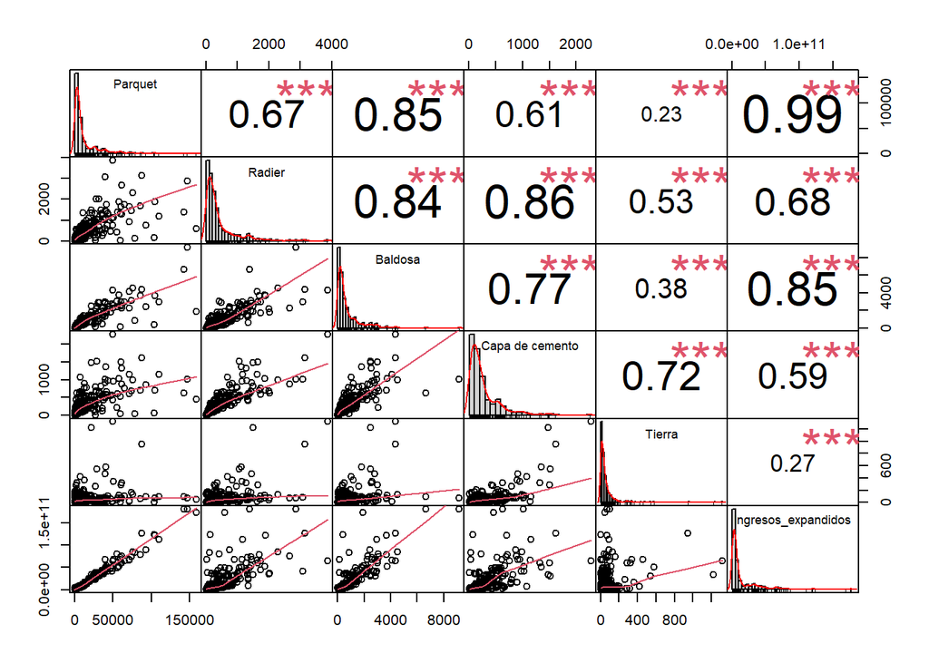

```r
library("PerformanceAnalytics")
my_data <- df_2017_2[, c(3,6,9,12,15,22)]
chart.Correlation(my_data, histogram=TRUE, pch=20)
```

## 3 Referencias

https://rpubs.com/osoramirez/316691

https://dataintelligencechile.shinyapps.io/casenfinal

Manual_de_usuario_Censo_2017_16R.pdf

http://www.censo2017.cl/microdatos/

Censo de Población y Vivienda

https://www.ine.cl/estadisticas/sociales/censos-de-poblacion-y-vivienda/poblacion-y-vivienda